# Bundel, Berkas, dan Kohomologi - Unit 1-30

Edisi Bahasa Indonesia independen

Holger Brenner (karya sumber)

2026-08-31

# Tentang edisi ini

Ini adalah edisi Bahasa Indonesia yang independen dari mata kuliah *Bündel, Garben und Kohomologie (Osnabrück 2019-2020)* karya Holger Brenner. Cakupannya adalah tepat 30 kuliah dan 30 lembar kerja, Unit 1–30, dalam urutan sumber. Seluruh 495 soal dipertahankan. Dua puluh lima solusi yang tersedia untuk umum diterjemahkan; untuk 470 soal lainnya, edisi menyimpan hasil penelusuran negatif dan tidak mengarang solusi yang tidak ada pada sumber.

Penerjemahan, pemeriksaan, dan produksi edisi dibantu oleh **OpenAI Codex gpt-5.6-sol, Ultra.** Pekerjaan dilakukan atas arahan pengguna. Provenans model ini tidak menggantikan kredit kepada penulis sumber atau kontributor manusia. Edisi ini bukan terbitan resmi Holger Brenner, Universitas Osnabrück, Wikiversity, Wikimedia Foundation, atau OpenAI, dan tidak menyiratkan dukungan dari pihak-pihak tersebut.

## Otoritas sumber yang dibekukan

Otoritas tekstualnya adalah revisi semantik Wikiversity yang dibekukan. Akar kursus mempunyai `pageid` 108997, revisi 1052895 bertanggal 2025-08-27T20:02:50Z, dan SHA-1 MediaWiki `e881e7c53531765849865454d4d0c643c2066c6d`. Indeks kursus yang dibekukan mencatat 30 identitas kuliah dan 30 identitas lembar kerja. Manifes kursus `authority/wikiversity-bgk/course/COURSE_AUTHORITY_MANIFEST.json` berukuran 34.279 byte dengan SHA-256 `ea0bf346e261db8ed80b7565f7746e95c79e0c376d25d9fbce5d96879dff7dd8`. PDF resmi dipakai sebagai saksi visual dan penomoran, bukan sebagai pengganti otoritas semantik yang lebih mutakhir.

Seluruh Unit 1–30 mempunyai terjemahan kuliah, lembar kerja, dan cakupan solusi yang lengkap, dengan manifes otoritas, PDF resmi unit, serta catatan hak komponennya. Penutupan sumber memeriksa ulang identitas berkas, urutan soal, solusi publik, dan hasil kandidat negatif. Laporan pemeriksaan pembaca, bangunan yang dapat diulang, serta identitas berkas terbitan disertakan dalam paket rilis; laporan tersebut dibedakan dari bukti otoritas sumber.

# Struktur dan rute belajar

Urutan berikut adalah urutan kuliah dan lembar kerja sumber, bukan jalur yang boleh dinomori ulang. Setiap rentang membentuk satu rute baca yang koheren.

[output not shown]

# Soal dan solusi

Solusi publik terdapat pada Unit 2 (Soal 2.4), Unit 3 (3.1), Unit 5 (5.5), Unit 7 (7.14), Unit 8 (8.3, 8.4, dan 8.11), Unit 11 (11.9, 11.13, dan 11.14), Unit 12 (12.5 dan 12.10), Unit 16 (16.12), Unit 18 (18.6, 18.17, dan 18.18), Unit 19 (19.10), Unit 21 (21.3, 21.9, dan 21.10), Unit 22 (22.19), Unit 25 (25.1), Unit 28 (28.6), serta Unit 29 (29.5 dan 29.12).

Tidak ditemukan solusi publik pada batas sumber untuk Unit 1, 4, 6, 9, 10, 13, 14, 15, 17, 20, 23, 24, 26, 27, dan 30. Untuk unit yang mempunyai sebagian solusi, setiap soal lain juga mempunyai hasil negatif tersendiri. Dengan demikian, angka 470 menyatakan hasil penelusuran negatif yang didokumentasikan, bukan halaman solusi kosong dan bukan bukti bahwa solusi tidak pernah ada di tempat lain.

# Media dan aksesibilitas

Delapan posisi media pembaca dengan biner komponen yang tersedia terdapat pada Unit 1, 2, 4, dan 29. Setiap aset itu mempertahankan kredit, pencipta, sumber, teks alternatif, dan lisensi komponennya sendiri. Unit 8 mempunyai satu posisi media yang mendeklarasikan `File:Spektrum_von_Z._xcf`, tetapi biner sumber itu hilang. Edisi mempertahankan nama pencipta dan label lisensi sebaris sumber, makna keterangan, teks alternatif, serta fakta kehilangan tersebut; edisi tidak mengklaim pemulihan dan tidak membuat aset sumber pengganti.

Unit 3, 5–7, 9–28, serta Unit 30 tidak mempunyai posisi media pembaca. PDF resmi unit dan PDF kursus adalah saksi otoritas, bukan media pembaca, sehingga tidak dihitung sebagai aset ilustrasi. Ketiadaan posisi media pada unit-unit itu bukan kehilangan isi.

# Lisensi, atribusi, dan batas hak

Teks semantik mata kuliah yang dibekukan dan terjemahan ini dibagikan dengan [Creative Commons Attribution-ShareAlike 4.0 International](https://creativecommons.org/licenses/by-sa/4.0/). Metadata Commons untuk PDF resmi kursus saat ini menyatakan CC BY-SA 4.0, sedangkan pemberitahuan yang tampak pada halaman 265 PDF tersebut menyatakan CC BY-SA 3.0. Edisi mempertahankan kedua catatan itu dan tidak membuat klaim pelisensian ulang secara menyeluruh.

Media dan komponen lain tetap berada di bawah pemberitahuan hak masing-masing; lisensi teks tidak otomatis melisensikan ulang semuanya. Atribusi, kewajiban berbagi-serupa, catatan komponen, dan pernyataan non-dukungan harus tetap disertakan bila edisi ini disalin, diubah, atau didistribusikan.

# Cara memakai pembaca ini

Baca setiap kuliah sebelum mengerjakan lembar kerja bernomor sama. Kerjakan rute secara berurutan: bahasa bundel dan berkas; operasi berkas dan spektrum; skema afin serta projektif; modul dan diferensial; bundel tangen, Picard, dan kelas pembagi; alat homologi dan kohomologi; lalu geometri kurva projektif hingga Riemann–Roch. Gunakan catatan edisi di dekat tempatnya untuk membedakan isi sumber dari koreksi yang dapat diverifikasi, keputusan terjemahan, catatan notasi, atau provenans media. Jangan menafsirkan hasil negatif solusi sebagai isi yang hilang. Panduan istilah sesudah bagian ini membantu mengenali padanan yang berbeda antarsatuan tanpa mengaburkan pembedaan matematisnya.

# Panduan istilah

Panduan ini menghubungkan istilah Jerman dengan pemakaiannya dalam Unit 1–30. Beberapa unit menggunakan sinonim Indonesia yang berbeda. Bentuk-bentuk itu tidak menyatakan objek matematis baru: bacalah bersama definisi, hipotesis, dan notasi pada unit bersangkutan. Bentuk pilihan di sini membantu pencarian lintas unit, tanpa mengganti rumus atau istilah dalam kutipan sumber.

## Objek yang perlu dibedakan

| Istilah sumber | Padanan Indonesia | Petunjuk membaca |
| --- | --- | --- |
| *Bündel*; *Garbe*; *Prägarbe* | bundel; berkas; praberkas | Bundel dan berkas bukan satu kata sumber. Berkas seksi suatu bundel menghubungkan kedua sudut pandang. |
| *Halm*; *Faser* | tangkai; serat | Untuk berkas modul, tangkai di titik dan serat yang diperoleh setelah memakai lapangan residu adalah objek berbeda. |
| *Schnitt*; *Durchschnitt* | seksi; irisan | Seksi berkas atau bundel bukan irisan himpunan. Dalam pembelahan surjeksi, seksi berarti invers kanan. |
| *Strukturgarbe*; *Modulgarbe* | berkas struktur; berkas modul | Struktur skalar tetap penting: suatu $\mathcal O_X$-modul adalah modul atas berkas struktur. |
| *Homomorphismenmodul*; *Homomorphismengarbe* | modul homomorfisme; berkas homomorfisme | Unit 13 juga menulis **modul homomorfisme global** untuk membedakan $\operatorname{Hom}$ dari berkas $\mathcal Hom$. |
| *Garbenmorphismus*; *Garbenhomomorphismus* | morfisme berkas; homomorfisme berkas | Kata kedua menonjolkan struktur grup atau modul yang dilestarikan; jangan menghapus struktur itu dari pernyataan. |
| *quasikohärent*; *kohärent* | kuasikoheren; koheren | Koherensi memuat syarat kehinggaan tambahan sesuai definisi unit; kedua sifat tidak dipertukarkan. |
| *Hyperebene*; *Hyperfläche* | hiperbidang; hipermuka | Hiperbidang bersifat linear, sedangkan hipermuka dapat mempunyai derajat lebih besar dari satu. |

## Padanan lintas unit

| Istilah sumber | Bentuk pilihan dan varian yang dijumpai | Batas makna |
| --- | --- | --- |
| *Vergarbung* | **berkasisasi**; pembentukan berkas | Pembentukan berkas yang diasosiasikan dengan suatu praberkas (*sheafification*). Bukan sembarang konstruksi berkas. |
| *Einheit*; *Einheitengarbe* | **satuan**; unit; **berkas satuan**; berkas unit | Satuan adalah unsur yang mempunyai invers perkalian, bukan hanya unsur identitas $1$. “Unit 20” adalah nomor bagian kursus. |
| *Rang* | **rank**; peringkat | Dalam konteks berkas bebas lokal atau bundel, menyatakan rank objek tersebut; bukan derajatnya. |
| *Einschränkung*; *Restriktion* | **restriksi**; pembatasan | Pembatasan objek atau peta ke subruang yang dinyatakan. Untuk $\mathcal F\|_U$, kata “terbatas” tidak berarti sifat *bounded*. |
| *Restriktionsabbildung* | **pemetaan restriksi**; pemetaan pembatasan | Jika sumber menekankan struktur aljabar, gunakan keluarga **homomorfisme restriksi** / homomorfisme pembatasan. |
| *Integritätsbereich* | **domain integral**; daerah integral | Gelanggang komutatif tak nol tanpa pembagi nol; kata “integral” di sini bukan operasi pengintegralan. |
| *Restklassenring* | **gelanggang faktor**; gelanggang hasil bagi; gelanggang kelas sisa | Gelanggang hasil bagi oleh ideal. Jangan menyamakannya dengan *Quotientenkörper*, yaitu **lapangan pecahan**. |
| *Restklassenmodul*; *Restklassengruppe* | **modul faktor**; **grup faktor** | “Kelas sisa” dan “hasil bagi” juga muncul untuk konstruksi yang sama. Objek modul, grup, dan gelanggang tetap dibedakan. |
| *Funktionenkörper* | **lapangan fungsi**; medan fungsi | “Medan fungsi” pada unit tertentu menyebut lapangan yang sama; **medan vektor** adalah istilah berbeda. |
| *Twist*; *getwistete Strukturgarbe* | **puntiran**; twist; **berkas struktur terpuntir**; berkas struktur terpilin | Puntiran derajat atau oleh berkas invertibel; bukan rotasi geometris atau dualisasi. |
| *glatt* | **mulus**; halus | Sifat kemulusan geometris. Tidak otomatis sama dengan *regulär* (**reguler**) tanpa hipotesis dasar yang sesuai. |
| *feine Monomgraduierung* | **gradasi monomial halus** | “Halus” di sini berarti gradasi yang lebih rinci, bukan kemulusan geometris. |
| *welk*; *welke Garbe* | **flasid**; flasque; flabby; **berkas flasid** | Semua peta restriksi bersifat surjektif. *Azyklisch* berarti **asiklik**; sifat asiklik bukan sinonim sifat flasid. |
| *Überdeckung* | **penutup**; liputan | Keluarga subhimpunan yang menutupi ruang. “Terbuka”, “afin”, dan “hingga” tetap merupakan kualifikasi matematis. |
| *affine Standardüberdeckung* | **liputan afin standar**; penutup afin standar | Bentuk yang telah dipakai dalam pembahasan ruang projektif; penutup standar tidak sama dengan penutup sembarang. |
| *Überlagerung* | **pemetaan ruang penutup** | Pemetaan ruang penutup berbeda dari keluarga himpunan terbuka yang disebut penutup. |
| *projektiv* | **projektif**; proyektif | BGK memakai keluarga “projektif”; bagian klasik juga memakai “proyektif”. Perbedaan ejaan ini tidak mengubah objek. |
| *Einbettung* | **pembenaman**; penyematan; embedding | Baca kategori dan sifat peta. Penyematan grup atau modul tidak boleh otomatis diberi sifat pembenaman skema. |
| *beringter Raum* | **ruang bergelanggang** | Ruang topologis yang dilengkapi berkas gelanggang. Teks terdahulu memakai “ruang berdering”; bentuk warisan itu dibaca dengan definisi ini, bukan sebagai istilah pilihan. |

## Istilah pada bagian akhir

| Istilah sumber | Padanan dan petunjuk |
| --- | --- |
| *Kähler-Differentiale*; *Tangentialgarbe*; *Kotangentialgarbe* | **diferensial Kähler**; **berkas tangen**; **berkas kotangen**. Pertahankan pembedaan berkas, modul, dan bundel. |
| *kanonische Garbe*; *antikanonische Garbe* | **berkas kanonis** / berkas kanonik; **berkas antikanonis** / berkas antikanonik. Awalan anti- tidak boleh dihilangkan. |
| *Syzygiengarbe* | **berkas syzygy** / berkas sizigi; dua ejaan untuk konstruksi relasi yang sama. |
| *Weildivisor*; *Hauptdivisor* | **pembagi Weil** / divisor Weil; **pembagi utama** / divisor utama. “Pembagi” di sini adalah objek geometri, bukan pembagi bilangan. |
| *Nullstellendivisor*; *Polstellendivisor* | **divisor nol**; **divisor kutub** suatu fungsi. Yang pertama adalah divisor titik-titik nol, bukan berarti divisor tersebut sama dengan nol. |
| *injektive Auflösung*; *rechtsabgeleiteter Funktor* | **resolusi injektif**; **funktor turunan kanan**. Resolusi adalah seluruh kompleks, bukan satu pemetaan injektif. |
| *Čech-Kohomologie*; *Čech-Kozykel*; *Čech-Koränder* | **kohomologi Čech**; **kokikel Čech**; **kobatas Čech**. Kelas kohomologi adalah kokikel modulo kobatas. |
| *lange exakte Kohomologiesequenz* | **barisan kohomologi eksak panjang** / barisan eksak panjang kohomologi. Kedua urutan kata mempertahankan syarat **eksak**. |
| *kurze exakte Sequenz* | **barisan eksak pendek** / barisan pendek eksak. “Barisan” tidak sama dengan *Ordnung*, yaitu urutan dalam teori urutan. |
| *lineares System*; *volles lineares System*; *basispunktfrei* | **sistem linear**; **sistem linear lengkap**; **bebas titik basis** / bebas titik dasar. Lengkap dan bebas titik basis adalah dua sifat berbeda. |
| *Verzweigungsindex*; *Verzweigungsordnung* | **indeks ramifikasi**; **orde ramifikasi**. Unit 29 menjelaskan perbedaan pemakaian nama antarsaksi; keduanya menunjuk eksponen ramifikasi lokal yang sama di sana. |
| *Serre-Dualität*; *Euler-Charakteristik*; *Satz von Riemann-Roch* | **dualitas Serre**; **karakteristik Euler**; **Teorema Riemann-Roch**. Nama tidak menggantikan hipotesis dan cakupan hasil yang dinyatakan sumber. |

## Notasi dan asal panduan

Istilah prosa tidak mengubah notasi sumber. Misalnya, **citra** tetap dapat ditulis dengan operator sumber `bild`, dan nama **spektrum** tidak mengharuskan penggantian `Spek` oleh `Spec` di dalam rumus. Perbedaan indeks, tanda kesetaraan, isomorfisme, serta hipotesis bukan varian kosakata.

Panduan penghubung ini disusun dari kursus Holger Brenner dan keputusan terminologi edisi Indonesia. Penyusunan berbantuan AI: **OpenAI Codex gpt-5.6-sol, Ultra.** Teks penghubung ini berlisensi **CC BY-SA 4.0**; kredit dan lisensi setiap komponen sumber tetap dipertahankan. Ini bukan panduan resmi dari penulis atau lembaga sumber dan tidak menyiratkan dukungan mereka.

# Kuliah 1: Sistem Persamaan Linear yang Bergantung pada Parameter dan Bundel Vektor

## Sistem persamaan linear yang bergantung pada parameter

Kita perhatikan persamaan linear real

$$7u-5v+2w=0.$$

Himpunan penyelesaiannya

$$L=\left\{(u,v,w)\in\mathbb R^3\mid 7u-5v+2w=0\right\}
\subset\mathbb R^3$$

merupakan subruang vektor real berdimensi dua dari $\mathbb R^3$. Menyelesaikan persamaan linear semacam itu antara lain berarti menentukan suatu basis bagi $L$. Dalam kasus ini, misalnya,

$$L=\left\langle
\begin{pmatrix}5\\7\\0\end{pmatrix},
\begin{pmatrix}2\\0\\-7\end{pmatrix}
\right\rangle.$$

Metode penyelesaiannya pada umumnya tidak bergantung pada koefisien konkret persamaan linear itu, meskipun nanti akan kita lihat batas dari pernyataan ini. Jika angka-angka konkret diganti dengan koefisien yang secara fungsional bergantung pada parameter, kita dapat bertanya bagaimana ruang penyelesaian berubah bersama parameter tersebut. Sebagai contoh, perhatikan persamaan linear yang bergantung pada parameter $s$,

$$7u-5v+(s^2-3s-10)w=0.$$

Untuk setiap $s$, ruang penyelesaian $L_s$ bergantung pada $s$, tetapi tetap merupakan subruang berdimensi dua,

$$L_s\subset\mathbb R^3.$$

Dengan kata lain, ruang penyelesaian itu adalah sebuah bidang yang bergerak di dalam ruang ketika $s$ berubah. Kita dapat menanyakan untuk nilai $s$ mana vektor

$$\begin{pmatrix}5\\-3\\8\end{pmatrix}$$

merupakan penyelesaian, yakni termasuk dalam $L_s$. Kita juga dapat bertanya apakah terdapat parameter berbeda $s,t$ dengan

$$L_s=L_t$$

sebagai subruang dari $\mathbb R^3$; apakah selalu ada basis ruang penyelesaian berbentuk

$$\left\langle
\begin{pmatrix}a\\b\\0\end{pmatrix},
\begin{pmatrix}c\\0\\d\end{pmatrix}
\right\rangle;$$

atau apakah selalu ada vektor penyelesaian berbentuk

$$\begin{pmatrix}1\\0\\e\end{pmatrix}.$$

Ingatlah bahwa algoritme untuk menyelesaikan sistem persamaan linear, yaitu eliminasi Gauss, bercabang ketika koefisien tertentu bernilai $0$ atau menjadi $0$ selama algoritme berlangsung. Persamaan

$$7u-5v+0w=0$$

mempunyai ruang penyelesaian

$$\left\langle
\begin{pmatrix}5\\7\\0\end{pmatrix},
\begin{pmatrix}0\\0\\1\end{pmatrix}
\right\rangle$$

dan tidak memuat vektor berbentuk $\begin{pmatrix}1&0&e\end{pmatrix}^{\mathsf T}$. Karena $s=-2$ dan $s=5$ adalah akar-akar polinom kuadrat $s^2-3s-10$, untuk kedua nilai parameter itu persamaan berparameter di atas berubah menjadi

$$7u-5v+0w=0.$$

Jadi, untuk kedua nilai tersebut, $L_s$ tidak mempunyai vektor berbentuk $\begin{pmatrix}1&0&e\end{pmatrix}^{\mathsf T}$. Untuk semua nilai parameter lainnya, ruang penyelesaiannya memuat vektor

$$\begin{pmatrix}
1\\[2pt]0\\[2pt]-\dfrac{7}{s^2-3s-10}
\end{pmatrix}.$$

Dengan demikian, aspek tertentu dari ruang penyelesaian itu sendiri bergantung secara fungsional pada parameter.

Wajar jika ketergantungan sebuah persamaan linear atau sistem persamaan linear pada parameter dipelajari dalam dua tahap. Pada tahap pertama, koefisien-koefisien persamaan diperlakukan sebagai variabel, yaitu sebagai *parameter universal*, lalu dipelajari bagaimana ruang penyelesaian berubah bersamanya. Secara khusus, kita ingin memahami lompatan kualitatif dalam perilaku ruang penyelesaian. Pada tahap kedua, kita memberikan syarat tambahan yang lebih atau kurang membatasi parameter universal itu, atau membiarkannya bergantung secara fungsional pada parameter lain.

### Contoh 1.1: satu persamaan dalam dua variabel

Kita perhatikan persamaan linear real umum

$$su+tv=0$$

dalam variabel $u,v$ dan parameter $s,t$, yang berperan sebagai koefisien tak tentu. Kita ingin memahami ruang penyelesaian

$$L_{(s,t)}=\left\{(u,v)\mid su+tv=0\right\}\subseteq\mathbb R^2$$

sebagai fungsi dari parameter $(s,t)$. Kasus ekstrem terjadi pada $(s,t)=(0,0)$: persamaan dipenuhi oleh setiap $(u,v)$, sehingga ruang penyelesaiannya adalah seluruh $\mathbb R^2$, yang berdimensi dua. Jika $(s,t)\ne(0,0)$, ruang penyelesaiannya berdimensi satu, dan sebuah vektor basis bagi garis penyelesaian itu adalah

$$\begin{pmatrix}t\\-s\end{pmatrix}.$$

Jadi, di atas ruang parameter $\mathbb R^2\setminus\{(0,0)\}$, ruang penyelesaiannya dapat ditulis seragam sebagai

$$L_{(s,t)}=
\left\{c\begin{pmatrix}t\\-s\end{pmatrix}\mathrel{\Big|}c\in\mathbb R\right\}.$$

Penafsiran yang lebih ringkas diperoleh dengan memandang ruang penyelesaian total

$$L=\left\{(s,t,u,v)\mid su+tv=0\right\}\subseteq\mathbb R^4.$$

Perhatikan bahwa $L$ bukan subruang vektor linear dari $\mathbb R^4$. Ruang penyelesaian untuk nilai parameter khusus $(s,t)$ diperoleh dengan memotong $L$ dengan bidang afin $(s,t)\times\mathbb R^2$. Di bawah proyeksi total

$$L\longrightarrow\mathbb R^2\times\mathbb R^2
\stackrel{p_{s,t}}{\longrightarrow}\mathbb R^2,
\qquad (s,t,u,v)\longmapsto(s,t),$$

$L_{(s,t)}$ adalah serat di atas $(s,t)$. Di dalam ruang penyelesaian total, terlihat baik perubahan garis penyelesaian terhadap parameter maupun degenerasinya menjadi bidang penyelesaian di atas titik nol. Perilaku di luar titik parameter nol dideskripsikan oleh pembatasan

$$L'=L\setminus\bigl(\{(0,0)\}\times\mathbb R^2\bigr)
=p^{-1}\!\left(\mathbb R^2\setminus\{(0,0)\}\right)
\longrightarrow\mathbb R^2\setminus\{(0,0)\}.$$

Setiap serat proyeksi terbatas ini adalah ruang penyelesaian berdimensi satu. Selain itu, terdapat bijeksi

$$\begin{aligned}
\left(\mathbb R^2\setminus\{(0,0)\}\right)\times\mathbb R
&\longrightarrow L',\\
(s,t;c)&\longmapsto(s,t,ct,-cs),
\end{aligned}$$

yang linear pada setiap parameter $(s,t)$. Di ruas kiri terdapat hasil kali langsung ruang basis $\mathbb R^2\setminus\{(0,0)\}$ dan serat $\mathbb R$, yang tidak bergantung pada titik basis. Di ruas kanan terdapat keluarga garis yang berubah-ubah di $\mathbb R^2$, tetapi bijeksi tersebut menerjemahkan satu gambaran ke gambaran yang lain.

> **Catatan edisi - urutan faktor dan ruang basis.** Pada definisi $L'$, sumber mencetak $\mathbb R^2\times(0,0)$, padahal kesamaan dengan $p^{-1}(\mathbb R^2\setminus\{(0,0)\})$ mengharuskan serat di atas titik nol yang dibuang, yaitu $\{(0,0)\}\times\mathbb R^2$. Prosa sumber kemudian mencetak $\mathbb R^2\times(0,0)$ sekali lagi sebagai ruang basis, sedangkan domain bijeksi yang langsung mendahuluinya adalah $\mathbb R^2\setminus\{(0,0)\}$. Edisi mengikuti kedua pemetaan yang ditampilkan dan mencatat ketidaksesuaian ini secara terbuka.

### Contoh 1.2: satu persamaan dalam tiga variabel

Kita perhatikan persamaan linear real umum

$$ru+sv+tw=0$$

dalam variabel $u,v,w$ dan parameter $r,s,t$, yang berperan sebagai koefisien tak tentu. Kita ingin memahami ruang penyelesaian

$$L_{(r,s,t)}=
\left\{(u,v,w)\mid ru+sv+tw=0\right\}\subseteq\mathbb R^3$$

sebagai fungsi dari parameter $(r,s,t)$. Pada $(r,s,t)=(0,0,0)$, ruang penyelesaiannya adalah seluruh $\mathbb R^3$. Jika $(r,s,t)\ne(0,0,0)$, ruang penyelesaiannya berdimensi dua. Kita keluarkan titik nol dari ruang parameter dan perhatikan ruang penyelesaian total

$$\begin{aligned}
L={}&\left\{(r,s,t,u,v,w)\mathrel{\Big|}
ru+sv+tw=0, (r,s,t)\ne(0,0,0)\right\}\\
&\subseteq\left(\mathbb R^3\setminus\{(0,0,0)\}\right)\times\mathbb R^3,
\end{aligned}$$

bersama proyeksi $p$ ke $\mathbb R^3\setminus\{(0,0,0)\}$. Serat $p$ di atas parameter khusus $(r,s,t)$ adalah ruang penyelesaian $L_{(r,s,t)}$ untuk persamaan yang ditentukan oleh tupel parameter itu.

> **Catatan edisi - notasi titik nol dan cakupan hasil kali.** Sumber mencetak $\mathbb R^3\setminus\{0,0,0\}\times\mathbb R^3$ pada inklusi ini, tanpa menuliskan titik nol sebagai tupel dan tanpa tanda kurung yang memisahkan ruang basis dari faktor serat. Proyeksi pada kalimat berikutnya menetapkan maksudnya secara unik. Edisi menuliskannya sebagai $(\mathbb R^3\setminus\{(0,0,0)\})\times\mathbb R^3$.

Dapatkah kita memberikan basis bagi setiap ruang penyelesaian yang bergantung pada parameter dengan cara aljabar dan komputasional yang jelas? Karena titik nol telah dikeluarkan,

$$\mathbb R^3\setminus\{(0,0,0)\}
=\{(r,s,t)\mid r\ne0\}\cup
\{(r,s,t)\mid s\ne0\}\cup
\{(r,s,t)\mid t\ne0\}.$$

Jadi ruang basis dapat ditulis sebagai gabungan tiga himpunan terbuka. Di atas himpunan terbuka $r\ne0$, misalnya, suatu basis diberikan oleh

$$(s,-r,0)\quad\text{dan}\quad(t,0,-r).$$

Syarat $r\ne0$ menjamin bahwa kedua vektor itu bebas linear. Kedua vektor tersebut bahkan merupakan penyelesaian yang terdefinisi di mana-mana, tetapi ketika $r=0$ keduanya kehilangan kebebasan linear sehingga tidak membentuk basis di mana-mana. Bagaimanapun, pemetaan

$$\begin{aligned}
\{(r,s,t)\mid r\ne0\}\times\mathbb R^2
&\longrightarrow L|_{\{(r,s,t)\mid r\ne0\}},\\
(r,s,t;c,d)&\longmapsto c(s,-r,0)+d(t,0,-r)
\end{aligned}$$

adalah bijeksi yang sederhana secara komputasional antara hasil kali ruang basis dengan $\mathbb R^2$ dan ruang penyelesaian di atas $\{(r,s,t)\mid r\ne0\}$.

Sekarang kita bertanya apakah mungkin memberikan secara global, di seluruh $\mathbb R^3\setminus\{(0,0,0)\}$, sebuah basis ruang penyelesaian yang berubah bersama titik basis. Yang ditanyakan ialah keberadaan dua fungsi $u(r,s,t)$ dan $v(r,s,t)$ bernilai di $\mathbb R^3$ yang selalu membentuk basis serat terkait, dan khususnya selalu termasuk dalam serat itu. Tanpa syarat lebih lanjut pada $u$ dan $v$, hal ini mungkin dilakukan dengan definisi kasus per kasus. Akan tetapi, hal itu tidak lagi mungkin jika kedua fungsi tersebut disyaratkan kontinu. Karena kontinuitas, fungsi global $u$ dan $v$ sudah ditentukan oleh nilainya pada himpunan terbuka rapat

$$U=\{(r,s,t)\mid r\ne0\}
\subseteq\mathbb R^3\setminus\{(0,0,0)\}.$$

Dengan basis di atas $U$ yang telah diberikan, kita dapat menulis

$$u=\alpha(r,s,t)\begin{pmatrix}s\\-r\\0\end{pmatrix}
+\beta(r,s,t)\begin{pmatrix}t\\0\\-r\end{pmatrix}$$

dan

$$v=\gamma(r,s,t)\begin{pmatrix}s\\-r\\0\end{pmatrix}
+\delta(r,s,t)\begin{pmatrix}t\\0\\-r\end{pmatrix},$$

dengan $\alpha,\beta,\gamma,\delta$ fungsi real kontinu pada $U$. Kita tidak dapat mengharapkan fungsi-fungsi koefisien itu terdefinisi di seluruh $\mathbb R^3$, sehingga argumen dalam kasus kontinu menjadi lebih rumit. Hasilnya akan mengikuti dari Teorema 2.3; lihat Catatan 2.4.

Karena itu, untuk saat ini kita batasi perhatian pada fungsi rasional yang penyebutnya boleh memuat suatu pangkat $r$, yakni fungsi rasional pada $U$. Perhatikan

$$\begin{aligned}
u
&=\alpha\begin{pmatrix}s\\-r\\0\end{pmatrix}
+\beta\begin{pmatrix}t\\0\\-r\end{pmatrix}\\
&=\frac{P}{r^m}\begin{pmatrix}s\\-r\\0\end{pmatrix}
+\frac{Q}{r^n}\begin{pmatrix}t\\0\\-r\end{pmatrix},
\end{aligned}$$

dengan $P,Q$ polinom dan faktor $r$ telah dicoret jika mungkin. Karena $u$ secara keseluruhan terdefinisi pada seluruh $\mathbb R^3$, pangkat $m$ dan, dengan alasan yang sama, $n$, paling besar $1$; jika tidak, $u$ akan mempunyai sebuah kutub. Untuk $m=n=1$, komponen pertama menghasilkan persamaan polinomial berbentuk

$$rN+sP+tQ=0,
\qquad N,P,Q\in\mathbb R[r,s,t].$$

Dalam hal ini, dengan kata kunci resolusi Koszul,

$$(N,P,Q)=A(-s,r,0)+B(t,0,-r)+C(0,t,-s)$$

untuk polinom $A,B,C\in\mathbb R[r,s,t]$. Dengan cara yang sama, $v$ mempunyai representasi melalui $(N',P',Q')$ dan $(A',B',C')$. Tuliskan

$$X=\mathbb R^3\setminus\{(0,0,0)\}$$

dan perhatikan pemetaan

$$\begin{aligned}
\varphi:X\times\mathbb R^3&\longrightarrow L\subseteq X\times\mathbb R^3,\\
(r,s,t;a,b,c)&\longmapsto
(r,s,t;\,a(-s,r,0)+b(t,0,-r)+c(0,t,-s)).
\end{aligned}$$

Di bawah pemetaan ini, tupel polinom $(A,B,C)$ dan $(A',B',C')$, yang kita pandang sebagai pemetaan $X\to X\times\mathbb R^3$, dipetakan ke $u$ dan $v$. Menurut asumsi, $u$ dan $v$ membentuk basis setiap serat $L$, sehingga $(A,B,C)$ dan $(A',B',C')$ bebas linear pada setiap titik. Tupel $(t,s,-r)$ dipetakan oleh $\varphi$ ke $0$ pada setiap serat. Oleh karena itu,

$$(A,B,C),\qquad(A',B',C'),\qquad(t,s,-r)$$

membentuk basis $\mathbb R^3$ pada setiap titik: $(t,s,-r)$ tidak mungkin merupakan kombinasi linear dari dua tupel pertama, sebab setelah menerapkan $\varphi$ akan diperoleh relasi taktrivial antara $u$ dan $v$. Akan tetapi, determinan matriks

$$\begin{pmatrix}
A&B&C\\
A'&B'&C'\\
t&s&-r
\end{pmatrix}$$

merupakan kombinasi polinomial dari variabel $r,s,t$, sehingga bukan unit di dalam gelanggang polinom. Dalam kasus real, dari sini belum dapat disimpulkan bahwa determinan itu mempunyai titik nol real di $X$; misalnya, bentuknya mungkin $r^2+s^2+t^2$. Namun, jika $\mathbb R$ diganti dengan $\mathbb C$, argumen aljabarnya tidak berubah, dan dapat disimpulkan bahwa determinan itu mempunyai titik nol pada

$$X_{\mathbb C}=\mathbb C^3\setminus\{(0,0,0)\}.$$

Jadi basis global seperti itu tidak dapat ada di semua titik.

### Contoh 1.3: dua persamaan dalam tiga variabel

Kita perhatikan sistem persamaan linear real umum

$$au+bv+cw=0$$

dan

$$du+ev+fw=0$$

dalam variabel $u,v,w$ dan parameter $a,b,c,d,e,f$. Jika parameternya cukup umum, lebih tepatnya jika kedua persamaan tidak berelasi linear, maka ruang penyelesaian

$$L_{(a,b,c,d,e,f)}=
\left\{(u,v,w)\mathrel{\Big|}
au+bv+cw=0\ \text{dan}\ du+ev+fw=0\right\}
\subseteq\mathbb R^3$$

adalah sebuah garis. Jadi, di bawah syarat ini, parameter menentukan suatu keluarga garis yang berubah-ubah di $\mathbb R^3$. Ruang parameter yang relevan bagi keluarga garis tersebut adalah

$$P=\left\{(a,b,c,d,e,f)\mathrel{\Big|}
(a,b,c)\ \text{dan}\ (d,e,f)\ \text{bebas linear}\right\}.$$

Secara keseluruhan, kita memperoleh ruang penyelesaian total

$$\begin{aligned}
L=\{&(a,b,c,d,e,f,u,v,w)\mid
au+bv+cw=0\ \text{dan}\ du+ev+fw=0\}\\
&\subseteq P\times\mathbb R^3,
\end{aligned}$$

beserta proyeksinya ke $P$.

Dapatkah garis ini, atau sebuah elemen basisnya, diberikan secara global sebagai fungsi parameter? Jika kedua persamaan dipandang sebagai relasi ortogonalitas, kita mencari vektor taknol yang tegak lurus terhadap kedua vektor syarat

$$\begin{pmatrix}a\\b\\c\end{pmatrix}
\quad\text{dan}\quad
\begin{pmatrix}d\\e\\f\end{pmatrix}.$$

Vektor hasil kali silang keduanya mempunyai sifat tersebut, yakni

$$\begin{pmatrix}
bf-ce\\
-af+cd\\
ae-bd
\end{pmatrix}.$$

Untuk sifat-sifat hasil kali silang yang digunakan di sini, sumber merujuk ke Lema 33.3 dalam *Lineare Algebra (Osnabrück 2024-2025)*.

Jadi terdapat bijeksi

$$\begin{aligned}
P\times\mathbb R&\longrightarrow L,\\
(a,b,c,d,e,f;s)&\longmapsto
(a,b,c,d,e,f;s(bf-ce),s(-af+cd),s(ae-bd)).
\end{aligned}$$

> **Catatan edisi - dua nama koordinat pada sumber.** Sumber menampilkan vektor syarat kedua sebagai $(e,f,g)$ meskipun sistem dan ruang parameter mendefinisikannya sebagai $(d,e,f)$. Pada pemetaan terakhir, sumber juga mencetak komponen tengah $-af+ce$, padahal hasil kali silang yang dicetak tepat sebelumnya memberi $-af+cd$. Edisi memakai $(d,e,f)$ dan $-af+cd$, yang dapat diverifikasi langsung dari dua persamaan, sambil mencatat kedua salah ketik sumber tersebut.

Pada Contoh 1.1 dan Contoh 1.3 terdapat *trivialisasi polinomial global*: dengan fungsi-fungsi polinomial, objek geometris yang rumit diterjemahkan ke objek sederhana $P\times\mathbb R$, dengan $P$ ruang basis. Sebaliknya, trivialisasi global semacam itu tidak mungkin pada Contoh 1.2, walaupun trivialisasi lokal tersedia di atas tiga himpunan terbuka yang diberikan. Objek geometris semacam inilah yang disebut bundel vektor.

## Bundel vektor real

### Definisi 1.4: bundel vektor real

Misalkan $X$ suatu ruang topologis dan $r\in\mathbb N$. Sebuah *bundel vektor real dengan rank $r$* adalah sebuah ruang topologis $V$ beserta pemetaan kontinu

$$p:V\longrightarrow X$$

sedemikian sehingga setiap serat $p^{-1}(x)$ merupakan ruang vektor real berdimensi $r$, dan terdapat suatu penutup terbuka

$$X=\bigcup_{i\in I}U_i$$

beserta homeomorfisme-homeomorfisme di atas $U_i$,

$$\varphi_i:p^{-1}(U_i)\longrightarrow U_i\times\mathbb R^r,$$

yang pada setiap serat menginduksi isomorfisme linear

$$(\varphi_i)_x:p^{-1}(x)\longrightarrow\mathbb R^r.$$

Ruang $V$ juga disebut *ruang total*, sedangkan $X$ disebut *ruang basis* bundel vektor. Serat di atas $x$ sering ditulis

$$V_x=p^{-1}(x).$$

Dalam contoh-contoh di atas, $X$ adalah ruang parameter yang relevan, yaitu tempat parameter-parameter yang ruang penyelesaiannya berdimensi minimum. Dimensi ini adalah rank $r$ pada definisi tadi, berturut-turut $1,2,1$. Pada contoh pertama dan ketiga, penutup terbukanya hanya terdiri atas ruang basis sendiri; kedua bundel itu mempunyai trivialisasi global. Pada contoh kedua, terdapat penutup oleh tiga himpunan terbuka yang di atasnya trivialisasi telah diberikan.

Dalam homeomorfisme

$$p^{-1}(U)\longrightarrow U\times\mathbb R^r,$$

ruas kanan diberi topologi produk, $\mathbb R^r$ diberi topologi Euklides alaminya, dan $p^{-1}(U)$ diberi topologi terinduksi dari $V$. Jadi setiap serat $V_x$ membawa topologi alami ruang vektor real berdimensi hingga. Yang dimaksud dengan homeomorfisme *di atas $U$* ialah bahwa diagram

$$\begin{array}{ccc}
p^{-1}(U)&\stackrel{\varphi}{\longrightarrow}&U\times\mathbb R^r\\
&\searrow p&\downarrow\operatorname{pr}_1\\
&&U
\end{array}$$

komutatif.

> **Catatan edisi - simbol rank pada diagram.** Diagram sumber mencetak $U\times\mathbb R^n$, sedangkan definisi dan semua rumus yang mengapitnya menetapkan rank sebagai $r$. Edisi menampilkan $\mathbb R^r$.

Hasil kali $X\times\mathbb R^r$ adalah sebuah bundel vektor yang disebut *bundel vektor trivial*.

### Lema 1.5: pembatasan bundel vektor

Misalkan

$$p:V\longrightarrow X$$

suatu bundel vektor real di atas ruang topologis $X$. Untuk setiap himpunan terbuka $W\subseteq X$, pembatasan

$$p^{-1}(W)\longrightarrow W$$

juga merupakan bundel vektor.

#### Bukti

Cukup batasi homeomorfisme-homeomorfisme linear serat demi serat

$$\varphi_i:p^{-1}(U_i)\longrightarrow U_i\times\mathbb R^r$$

menjadi

$$\varphi_i|_{W\cap U_i}:
p^{-1}(W\cap U_i)\longrightarrow(W\cap U_i)\times\mathbb R^r.$$

$\square$

Pembatasan sebuah bundel vektor pada setiap $U_i$ bersifat trivial. Jadi, secara lokal setiap bundel vektor bersifat trivial.

### Definisi 1.6: homomorfisme bundel vektor

Misalkan $E$ dan $F$ bundel vektor real di atas ruang topologis $X$. Sebuah *homomorfisme bundel vektor*

$$\varphi:E\longrightarrow F$$

adalah pemetaan kontinu di atas $X$ sedemikian sehingga, untuk setiap $x\in X$, pemetaan terinduksi

$$\varphi_x:E_x\longrightarrow F_x$$

bersifat linear atas $\mathbb R$.

### Definisi 1.7: isomorfisme bundel vektor

Misalkan $E$ dan $F$ bundel vektor real di atas ruang topologis $X$. Homomorfisme bundel vektor

$$\varphi:E\longrightarrow F$$

disebut *isomorfisme* jika terdapat homomorfisme

$$\psi:F\longrightarrow E$$

yang, jika dikomposisikan dengan $\varphi$ dalam kedua urutan, menghasilkan pemetaan identitas.

## Bundel tangen pada manifold

Sekarang kita bahas sebuah bundel vektor sangat penting yang terdapat pada setiap manifold, yaitu bundel tangen.

Untuk setiap titik $P\in M$ pada sebuah manifold terdapat ruang tangen $T_PM$. Ruang tangen adalah ruang vektor berdimensi $n$, dengan $n$ dimensi manifold tersebut. Elemen-elemennya adalah vektor tangen, yakni “arah infinitesimal” di titik itu. Pada awalnya, arah tangen di dua titik yang berbeda tidak berhubungan: definisinya hanya bergantung pada lingkungan terbuka sekecil apa pun di sekitar masing-masing titik, dan berkat sifat Hausdorff lingkungan-lingkungan itu dapat dipilih saling lepas.

Gambaran ini sangat berbeda untuk sebuah himpunan terbuka $V\subseteq\mathbb R^n$. Untuk setiap $Q\in V$, ruang tangen $T_QV$ dapat diidentifikasi secara alami dengan ruang vektor ambien $\mathbb R^n$. Sebuah vektor $v\in\mathbb R^n$ dipasangkan dengan vektor tangen yang ditentukan oleh kurva linear $t\mapsto Q+tv$. Karena identifikasi ini berlaku untuk setiap titik, terdapat kesejajaran langsung antara ruang-ruang tangen untuk

$$Q\in V\subseteq\mathbb R^n.$$

Sebuah manifold ditutupi oleh himpunan-himpunan terbuka yang difeomorfik dengan himpunan terbuka dalam ruang Euklides. Karena itu, masuk akal untuk menduga bahwa berbagai ruang tangennya tidak sepenuhnya terisolasi. Konsep bundel tangen menggabungkan semua ruang tangen dan mencerminkan keterkaitan lokal di antara ruang-ruang tersebut.

> **Ilustrasi sumber - `Tangent_bundle.svg`.** Dua visualisasi bundel tangen sebuah lingkaran. Pada gambar atas, ruang tangen di setiap titik $P$ pada lingkaran diletakkan menyinggung lingkaran dan direalisasikan sebagai subruang afin berdimensi satu di $\mathbb R^2$. Pembenaman ini menimbulkan perpotongan yang sebenarnya tidak ada dalam bundel tangen, karena titik basis $P$ juga harus diperhitungkan. Pada gambar bawah, ruang-ruang tangen disusun sejajar di atas titik-titik lingkaran dan menghasilkan sebuah silinder.

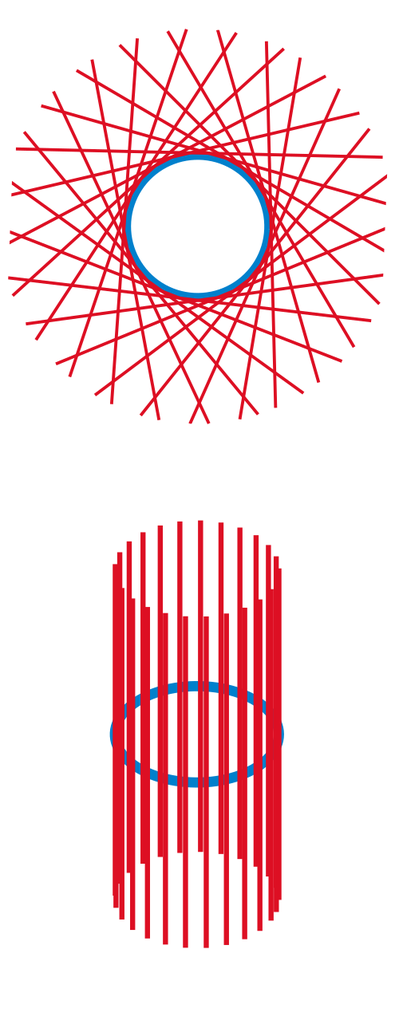

Diagram bundel tangen dengan ruang tangen sebagai serat di atas setiap titik manifold

### Definisi 1.8: bundel tangen sebagai gabungan lepas

Misalkan $M$ suatu manifold terdiferensial. Himpunan

$$TM=\biguplus_{P\in M}T_PM,$$

beserta pemetaan proyeksi

$$\begin{aligned}
\pi:TM&\longrightarrow M,\\
(P,v)&\longmapsto P,
\end{aligned}$$

disebut *bundel tangen* dari $M$.

Sebuah titik $u\in TM$ selalu mempunyai titik basis $P\in M$ dan merupakan elemen ruang tangen $T_PM$. Titik itu biasanya ditulis $(P,v)$ dengan $P\in M$ dan $v\in T_PM$. Untuk suatu himpunan terbuka $V\subseteq\mathbb R^n$,

$$TV=V\times\mathbb R^n,$$

jadi ia merupakan ruang hasil kali. Hal ini tidak berlaku pada manifold sebarang. Mula-mula bundel tangen hanya menggabungkan secara lepas berbagai ruang tangen, tanpa mengidentifikasi ruang tangen yang berbeda satu sama lain. Namun, topologi yang akan segera diberikan pada bundel tangen menambahkan suatu “struktur ketetanggaan” di antara ruang-ruang tangen.

### Definisi 1.9: pemetaan tangen

Misalkan $M$ dan $N$ manifold terdiferensial dan

$$\varphi:M\longrightarrow N$$

suatu pemetaan terdiferensial. Misalkan $TM$ dan $TN$ bundel tangen yang bersesuaian. *Pemetaan tangen*

$$T(\varphi):TM\longrightarrow TN$$

adalah gabungan lepas pemetaan-pemetaan tangen pada setiap titik, yakni

$$T(\varphi)=\biguplus_{P\in M}T_P(\varphi).$$

### Contoh 1.10: trivialisasi lokal dari sebuah bagan

Misalkan $M$ suatu manifold terdiferensial dan

$$\alpha:U\longrightarrow V$$

sebuah bagan, dengan $V\subseteq\mathbb R^n$ terbuka. Bagan itu menginduksi bijeksi alami

$$\begin{aligned}
T(\alpha^{-1}):TV=V\times\mathbb R^n&\longrightarrow TU,\\
(Q,v)&\longmapsto
\left(\alpha^{-1}(Q),[s\mapsto\alpha^{-1}(Q+sv)]\right).
\end{aligned}$$

Di sini $s$ bergerak dalam suatu interval real $I$ yang dipilih sehingga $Q+sv\in V$ (bandingkan Lema 77.5 pada *Analysis (Osnabrück 2014-2016)*). Karena $V\times\mathbb R^n$ merupakan hasil kali ruang-ruang topologis,

$$TV=V\times\mathbb R^n$$

sendiri merupakan ruang topologis. Wajar untuk memindahkan topologi ini ke $TU$, lalu membangun topologi pada seluruh bundel tangen $TM$.

### Definisi 1.11: topologi bundel tangen

Misalkan $M$ suatu manifold terdiferensial berdimensi $n$ dan

$$TM=\biguplus_{P\in M}T_PM$$

bundel tangennya, dengan proyeksi

$$\begin{aligned}
\pi:TM&\longrightarrow M,\\
(P,v)&\longmapsto P.
\end{aligned}$$

Bundel tangen diberi topologi yang didefinisikan sebagai berikut: suatu himpunan bagian $W\subseteq TM$ terbuka jika dan hanya jika, untuk setiap bagan

$$\alpha:U\longrightarrow V,$$

himpunan

$$T(\alpha)\left(W\cap\pi^{-1}(U)\right)$$

terbuka di $V\times\mathbb R^n$.

Khususnya, untuk setiap himpunan terbuka $U\subseteq M$, prabayang

$$\pi^{-1}(U)=TU\subseteq TM$$

terbuka; dengan kata lain, proyeksi $\pi$ kontinu. Dengan ketetapan ini, bundel tangen manifold terdiferensial merupakan bundel vektor real. Jika

$$M=\bigcup_{i\in I}U_i$$

adalah suatu penutup terbuka oleh himpunan-himpunan $U_i$ yang homeomorfik dengan himpunan terbuka $V_i\subseteq\mathbb R^n$, maka bagan-bagan

$$\alpha_i:U_i\longrightarrow V_i$$

langsung memberikan trivialisasi

$$TM|_{U_i}=TU_i
\stackrel{T(\alpha_i)}{\longrightarrow}
TV_i=V_i\times\mathbb R^n.$$

Sangat banyak sifat manifold tercermin pada sifat bundel tangennya. Bundel tangen dapat bersifat trivial sekalipun $M$ tidak homeomorfik dengan suatu himpunan terbuka di $\mathbb R^n$.

# Lembar Kerja 1: Bundel Vektor dan Bundel Tangen

Dalam soal-soal berikut, kita menggunakan notasi

$$D(r)=\left\{(r,s,t)\in\mathbb R^3\mid r\ne0\right\}.$$

## Soal 1.1

Untuk bundel vektor

$$\begin{aligned}
L={}&\left\{(r,s,t,u,v,w)\mathrel{\Big|}
ru+sv+tw=0,\ (r,s,t)\ne(0,0,0)\right\}\\
&\subseteq
\left(\mathbb R^3\setminus\{(0,0,0)\}\right)\times\mathbb R^3
\longrightarrow\mathbb R^3\setminus\{(0,0,0)\},
\end{aligned}$$

tentukan trivialisasi linear di atas $D(r)$, $D(s)$, dan $D(t)$, yaitu basis-basis yang bergantung pada $r,s,t$ di atas $D(r)$ dan seterusnya. Tentukan pemetaan perubahan basis pada

$$D(rs)=D(r)\cap D(s).$$

## Soal 1.2

Untuk bundel vektor

$$\begin{aligned}
L={}&\left\{(r,s,t,u,v,w)\mathrel{\Big|}
ru+sv+tw=0,\ (r,s,t)\ne(0,0,0)\right\}\\
&\subseteq
\left(\mathbb R^3\setminus\{(0,0,0)\}\right)\times\mathbb R^3
\longrightarrow\mathbb R^3\setminus\{(0,0,0)\},
\end{aligned}$$

tentukan semua parameter $(r,s,t)$ yang membuat vektor $(3,7,4)$ termasuk dalam serat $L_{(r,s,t)}$.

## Soal 1.3

Tunjukkan bahwa, pada Contoh 1.2 dan di atas $D(r)$, rumus

$$u(r,s,t)=
\frac{t}{r}\begin{pmatrix}s\\-r\\0\end{pmatrix}
-\frac{s}{r}\begin{pmatrix}t\\0\\-r\end{pmatrix}$$

mendefinisikan sebuah vektor dalam ruang penyelesaian yang bergantung pada parameter dan dapat diperluas secara polinomial ke seluruh $\mathbb R^3$, meskipun fungsi koefisien $t/r$ dan $-s/r$ hanya terdefinisi pada $D(r)$ dan tidak dapat diperluas. Apakah $u(r,s,t)$ merupakan bagian dari suatu basis di setiap titik?

## Soal 1.4

Pada Contoh 1.3, tentukan parameter-parameter yang membuat ruang penyelesaian $L_{(a,b,c,d,e,f)}$ berdimensi satu, dua, atau tiga. Apakah himpunan-himpunan parameter tersebut terbuka atau tertutup?

## Soal 1.5

Tunjukkan bahwa, di atas lapangan sebarang $K$, untuk dua vektor bebas linear

$$u=\begin{pmatrix}a\\b\\c\end{pmatrix}
\quad\text{dan}\quad
v=\begin{pmatrix}d\\e\\f\end{pmatrix},$$

keluarga yang terdiri atas $u$, $v$, dan hasil kali silangnya

$$\begin{pmatrix}a\\b\\c\end{pmatrix}
\times
\begin{pmatrix}d\\e\\f\end{pmatrix}$$

tidak harus membentuk basis bagi $K^3$.

## Soal 1.6

Perhatikan ruang topologis

$$Y:=\left\{(s,t,u,v)\in\mathbb R^4\mid su+tv=1\right\}$$

dengan proyeksi

$$\begin{aligned}
p:Y&\longrightarrow\mathbb R^2\setminus\{(0,0)\}=X,\\
(s,t,u,v)&\longmapsto(s,t).
\end{aligned}$$

1. Tunjukkan bahwa setiap serat $p$ homeomorfik dengan sebuah garis real.
2. Tunjukkan bahwa

   $$\varphi(s,t)=(s,t,u(s,t),v(s,t))
   =\left(s,t,\frac{s}{s^2+t^2},\frac{t}{s^2+t^2}\right)$$

   mendefinisikan pemetaan kontinu $\varphi:X\to Y$ dengan

   $$p\circ\varphi=\operatorname{Id}_X.$$
3. Definisikan suatu homeomorfisme antara $Y$ dan $X\times\mathbb R$.
4. Tunjukkan bahwa tidak terdapat pemetaan polinomial $\psi:X\to Y$ dengan

   $$p\circ\psi=\operatorname{Id}_X.$$

## Soal 1.7

Tunjukkan bahwa sebuah bundel vektor real di atas satu titik, yakni di atas ruang topologis bertitik tunggal, sama dengan sebuah ruang vektor real berdimensi hingga.

## Soal 1.8

Misalkan $p:V\to X$ suatu bundel vektor real di atas ruang topologis $X$. Tunjukkan bahwa $V$ merupakan ruang Hausdorff jika dan hanya jika $X$ merupakan ruang Hausdorff.

## Soal 1.9

Misalkan $X$ suatu ruang topologis. Tunjukkan bahwa pemetaan identitas

$$\operatorname{Id}_X:X\longrightarrow X$$

dapat dipandang sebagai bundel vektor real dengan rank $0$.

## Soal 1.10

Misalkan $X$ suatu ruang topologis. Tunjukkan bahwa sebuah homomorfisme bundel vektor trivial

$$\varphi:X\times\mathbb R^n\longrightarrow X\times\mathbb R^m$$

sama dengan sebuah matriks $m\times n$ yang entri-entrinya adalah fungsi kontinu dari $X$ ke $\mathbb R$.

## Soal 1.11

Misalkan $U\subseteq\mathbb R^n$ terbuka dan $f:U\to\mathbb R^m$ suatu pemetaan terdiferensial secara kontinu. Tunjukkan bahwa diferensial total, dalam bentuk

$$\begin{aligned}
U\times\mathbb R^n&\longrightarrow U\times\mathbb R^m,\\
(x,v)&\longmapsto\bigl(x,(Df)_x(v)\bigr),
\end{aligned}$$

mendefinisikan homomorfisme dari bundel vektor $U\times\mathbb R^n$ ke bundel vektor $U\times\mathbb R^m$.

## Soal 1.12

Tunjukkan bahwa bundel tangen $TS^1$ dari sfera satu $S^1$ homeomorfik dengan hasil kali $S^1\times\mathbb R$.

Apa hubungan soal ini dengan Contoh 1.1?

## Soal 1.13

Berikan sebuah contoh kurva terdiferensial

$$\gamma:[0,1)\longrightarrow S^1$$

sedemikian sehingga limit

$$\lim_{t\to1}\gamma(t)$$

ada, tetapi limit

$$\lim_{t\to1}\bigl(\gamma(t),T_t(\gamma)(1)\bigr)$$

tidak ada di $TS^1$.

## Soal 1.14

Tunjukkan bahwa pemetaan

$$\begin{aligned}
TS^1&\longrightarrow\mathbb R^2,\\
((a,b),t(-b,a))&\longmapsto(a,b)+t(-b,a)
\end{aligned}$$

mempunyai dua prabayang untuk setiap titik $(x,y)\in\mathbb R^2$ di luar cakram satuan, satu prabayang untuk setiap titik pada lingkaran satuan, dan tidak mempunyai prabayang untuk setiap titik di dalam cakram satuan terbuka. Tafsirkan hasil ini secara geometris.

## Soal 1.15

Berikan sebuah contoh pemetaan terdiferensial injektif

$$\varphi:M\longrightarrow N$$

antara dua manifold terdiferensial $M$ dan $N$ sedemikian sehingga pemetaan tangen terkait

$$T(\varphi):TM\longrightarrow TN$$

tidak injektif.

## Soal 1.16

Berikan sebuah contoh pemetaan terdiferensial surjektif

$$\varphi:M\longrightarrow N$$

antara dua manifold terdiferensial $M$ dan $N$ sedemikian sehingga pemetaan tangen terkait

$$T(\varphi):TM\longrightarrow TN$$

tidak surjektif.

## Soal 1.17

Misalkan $M$ dan $N$ manifold terdiferensial dan $\varphi:M\to N$ suatu pemetaan terdiferensial. Tunjukkan bahwa pemetaan tangen terkait

$$T(\varphi):TM\longrightarrow TN$$

bersifat kontinu.

# Cakupan Solusi Publik Lembar Kerja 1

Pada batas revisi yang dibekukan, sumber tidak menyediakan solusi publik untuk satu pun dari 17 soal pada Lembar Kerja 1. Kueri kandidat solusi dan peta soal yang dibekukan mencatat hasil negatif untuk Soal 1.1-1.17.

Tidak ada solusi baru yang dibuat untuk edisi ini. Bagian ini hanya mendokumentasikan cakupan sumber agar ketiadaan solusi tidak disalahartikan sebagai kehilangan isi selama penerjemahan.

# Kredit media BGK Unit 1

Sumber kursus: **Kurs:Bündel, Garben und Kohomologie (Osnabrück 2019-2020)**, Kurs:Bündel, Garben und Kohomologie (Osnabrück 2019-2020)/Vorlesung 1. Satu posisi media substantif mempertahankan identitas Commons dan lisensi komponennya. Dua PDF resmi adalah saksi authority, bukan posisi media pembaca tambahan.

1. **Bundel tangen pada sebuah manifold** - [File:Tangent bundle.svg](https://commons.wikimedia.org/wiki/File:Tangent_bundle.svg); pencipta/atribusi: Oleg Alexandrov; lisensi/status hak: Public domain.

Catatan hak: label sebaris pada sumber BGK adalah `PD`, sedangkan revisi deskripsi Commons yang dibekukan memuat `{{PD-self}}` dan metadata Commons menawarkan Public domain. Edisi mengikat opsi Commons tersebut, bukan label sebaris yang berbeda.

# Kuliah 2: Seksi, Teorema Bola Berbulu, dan Data Pengeleman

## Seksi

### Definisi 2.1: seksi kontinu

Misalkan $X$ dan $Y$ ruang-ruang topologis, dan misalkan

$$p:Y\longrightarrow X$$

suatu pemetaan kontinu. Sebuah *seksi kontinu* dari $p$ adalah pemetaan kontinu

$$s:X\longrightarrow Y$$

sedemikian sehingga

$$p\circ s=\operatorname{Id}_X.$$

Sebagai contoh, kita dapat memikirkan $Y$ sebagai sebuah bundel vektor di atas $X$. Seksi hanya dapat ada jika $p$ surjektif, dan sifat ini selalu dipenuhi oleh sebuah bundel vektor. Kadang-kadang sebuah seksi diidentifikasi dengan citranya. Hal ini tidak menimbulkan masalah karena setiap seksi injektif. *Seksi nol* mempunyai peran khusus: kepada setiap titik basis $P$, ia memasangkan titik nol di dalam ruang vektor $V_P$. Untuk bundel tangen, seksi mempunyai nama tersendiri.

### Definisi 2.2: medan vektor

Misalkan $M$ sebuah manifold terdiferensial. Sebuah pemetaan

$$F:M\longrightarrow TM$$

yang memenuhi

$$F(P)\in T_PM$$

untuk setiap titik $P\in M$ disebut *medan vektor* (tak bergantung waktu).

## Teorema bola berbulu

> **Ilustrasi sumber - `Hairy_ball_one_pole.jpg`.** Sebuah medan vektor kontinu pada sfera dua harus mempunyai setidaknya satu titik nol.

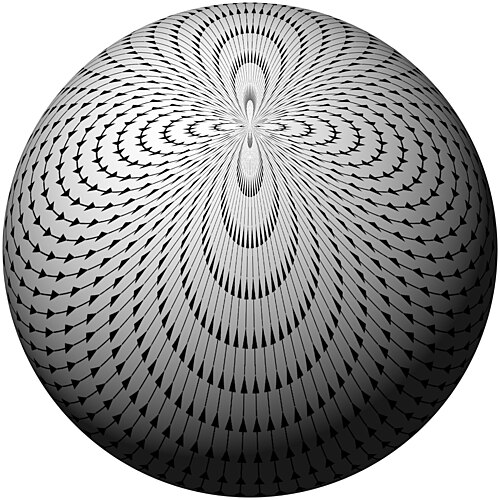

Bola berbulu dengan satu pusaran di kutub, sebagai ilustrasi bahwa medan vektor tangen kontinu pada bola harus mempunyai titik nol

### Teorema 2.3: teorema bola berbulu

Pada sfera dua, setiap medan vektor kontinu

$$f:S^2\longrightarrow TS^2$$

mempunyai setidaknya satu titik nol.

Khususnya, bundel tangen sfera dua tidak trivial. Teorema ini mempunyai berbagai penafsiran. Misalnya, pada permukaan bumi selalu ada suatu titik tanpa angin, jika arah angin horizontal sesaat dipandang sebagai medan vektor kontinu. Demikian pula, semua duri landak tidak mungkin direbahkan rata pada tubuh landak tanpa membentuk satu titik yang tegak.

### Catatan 2.4: penerapan pada Contoh 1.2

Teorema bola berbulu menjelaskan mengapa bundel vektor $L$ dari Contoh 1.2, yang terletak di atas

$$\mathbb R^3\setminus\{(0,0,0)\},$$

tidak mempunyai trivialisasi kontinu. Pertama,

$$S^2\subset\mathbb R^3\setminus\{(0,0,0)\},$$

sehingga $L$ dapat dibatasi pada $S^2$. Jika $L$ sendiri trivial, maka pembatasan ini juga trivial. Akan tetapi, pembatasan $L$ pada sfera satuan adalah bundel tangen sfera satuan. Memang, syarat

$$ru+sv+tw=0$$

dapat dipahami sebagai relasi ortogonalitas, dan ruang tangen ekstrinsik di titik posisi $(r,s,t)$ pada sfera ditentukan oleh relasi tersebut. Jika bundel tangen itu trivial, akan ada dua medan vektor kontinu $u$ dan $v$ yang membentuk basis ruang tangen pada setiap titik sfera. Namun, teorema bola berbulu menyatakan bahwa setiap medan vektor bahkan mempunyai titik nol, sedangkan $0$ tidak dapat menjadi anggota suatu basis.

## Data pengeleman untuk ruang topologis

Sebuah bundel vektor $V\to X$ “tersusun” dari bundel-bundel vektor trivial $V|_{U_i}\to U_i$ untuk suatu penutup terbuka dari $X$. Cara potongan-potongan itu disusun justru menentukan bundel vektornya, dan susunan tersebut dapat dideskripsikan secara ringkas dengan data pengeleman. Untuk itu, pertama-tama kita memerlukan data pengeleman bagi ruang topologis secara umum.

Pertanyaan dasarnya ialah: apa yang harus diketahui dari sebuah penutup terbuka

$$X=\bigcup_{i\in I}U_i$$

agar ruang $X$ dapat direkonstruksi? Jawaban singkatnya ialah bahwa kita harus mengetahui $U_i$, irisan dua-dua $U_i\cap U_j$ sebagai himpunan bagian baik dari $U_i$ maupun dari $U_j$, cara kedua salinan itu diidentifikasi, dan sebuah syarat kompatibilitas bagi identifikasi tersebut pada setiap tiga himpunan.

> **Ilustrasi sumber - `Inclusion-exclusion.svg`.** Tiga himpunan yang saling beririsan menggambarkan perlunya syarat kompatibilitas pada irisan rangkap tiga.

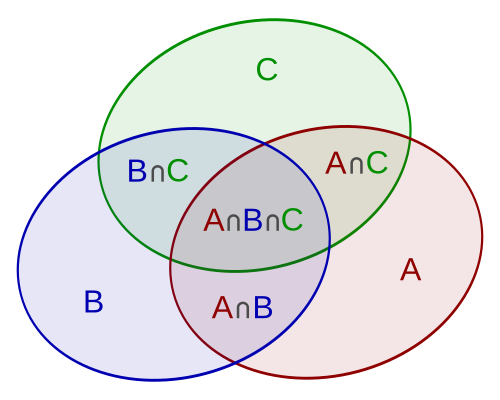

Diagram tiga himpunan berbentuk lingkaran yang saling beririsan, dengan setiap daerah irisan dibedakan oleh warna

### Definisi 2.5: data pengeleman ruang topologis

Sebuah *data pengeleman* untuk ruang-ruang topologis terdiri atas:

1. sebuah keluarga ruang topologis $(U_i)_{i\in I}$;
2. untuk setiap pasangan $(i,j)$, sebuah himpunan terbuka

   $$U_{ij}\subseteq U_i,$$

   dengan $U_{ii}=U_i$;
3. untuk setiap pasangan $(i,j)$, sebuah homeomorfisme

   $$\varphi_{ji}:U_{ij}\longrightarrow U_{ji},$$

   dengan $\varphi_{ii}=\operatorname{Id}_{U_i}$;
4. untuk semua $i,j,k\in I$, *syarat kokikel*

   $$\varphi_{kj}\circ\varphi_{ji}=\varphi_{ki}$$

   dipenuhi sebagai pemetaan dari $U_{ik}\cap U_{ij}$ ke $U_k$.

### Lema 2.6: merekonstruksi ruang dari data pengeleman

Misalkan diberikan data pengeleman $(U_i)_{i\in I}$ untuk ruang-ruang topologis. Maka terdapat ruang topologis $X$ yang ditentukan secara unik, penutup terbuka

$$X=\bigcup_{i\in I}V_i,$$

dan homeomorfisme

$$\psi_i:U_i\longrightarrow V_i$$

sedemikian sehingga

$$\psi_i(U_{ij})=V_i\cap V_j$$

dan

$$\psi_i|_{U_{ij}}
=\psi_j|_{U_{ji}}\circ\varphi_{ji}.$$

#### Bukti

Misalkan $Y$ gabungan lepas semua $U_i$. Pada $Y$, definisikan relasi ekuivalensi $\sim$ dengan menyatakan bahwa $x_i\in U_i$ dan $x_j\in U_j$ ekuivalen apabila

$$x_i\in U_{ij},\qquad x_j\in U_{ji},\qquad
\varphi_{ji}(x_i)=x_j.$$

Sifat-sifat relasi ekuivalensi dijamin oleh syarat kokikel; lihat Soal 2.14. Tetapkan

$$X:=Y/{\sim}$$

dan beri $X$ topologi hasil bagi. Komposisi

$$U_i\longrightarrow Y\longrightarrow X$$

adalah pemetaan $\psi_i$, dan $V_i$ adalah citra pemetaan tersebut. Dengan demikian, $\psi_i:U_i\to V_i$ adalah homeomorfisme. Untuk $x\in U_i$,

$$\psi_i(x)\in V_j$$

jika dan hanya jika $x\in U_{ij}$, karena tepat dalam kasus ini $x$ diidentifikasi dengan $\varphi_{ji}(x)$. Karena itu,

$$\psi_i(U_{ij})=V_i\cap V_j.$$

> **Catatan edisi - arah indeks dalam bukti.** Dengan konvensi pada Definisi 2.5, $\varphi_{ji}:U_{ij}\to U_{ji}$. Pada kalimat sebelumnya, sumber mencetak $\varphi_{ij}(x)$ untuk $x\in U_{ij}$, meskipun pemetaan yang bertipe benar adalah $\varphi_{ji}(x)$. Edisi menampilkan indeks yang bertipe benar di badan bukti dan mempertahankan bentuk sumber dalam catatan ini.

Komutativitas diagram

$$\begin{array}{ccc}
U_{ij}&\stackrel{\varphi_{ji}}{\longrightarrow}&U_{ji}\\
&\searrow\psi_i&\downarrow\psi_j\\
&&V_i\cap V_j
\end{array}$$

mengikuti dengan cara yang sama. $\square$

### Lema 2.7: mengelem pemetaan kontinu

Misalkan diberikan data pengeleman $(U_i)_{i\in I}$ untuk ruang-ruang topologis. Misalkan $Z$ ruang topologis lain dan diberikan pemetaan-pemetaan kontinu

$$\theta_i:U_i\longrightarrow Z$$

yang memenuhi

$$\theta_i|_{U_{ij}}
=\bigl(\theta_j|_{U_{ji}}\bigr)\circ\varphi_{ji}.$$

Maka terdapat tepat satu pemetaan kontinu

$$\theta:X\longrightarrow Z$$

sedemikian sehingga

$$\theta|_{V_i}\circ\psi_i=\theta_i,$$

dengan $X$ ruang topologis yang ditentukan oleh data pengeleman seperti pada Lema 2.6, termasuk notasinya.

> **Catatan edisi - identitas komposisi tidak bertipe.** Sumber mencetak $(\psi_i)^{-1}\circ\theta|_{V_i}=\theta_i$, yang tidak dapat dikomposisikan: $\theta|_{V_i}$ bernilai di $Z$, sedangkan $(\psi_i)^{-1}$ berdomain $V_i$. Edisi menampilkan identitas bertipe benar $\theta|_{V_i}\circ\psi_i=\theta_i$ di badan lema dan mempertahankan bentuk sumber dalam catatan ini.

#### Bukti

Lihat Soal 2.18.

## Data pengeleman untuk bundel vektor

### Definisi 2.8: data pengeleman bundel vektor real

Sebuah *data pengeleman* untuk bundel vektor real dengan rank $r$ di atas ruang topologis $X$ terdiri atas:

1. sebuah penutup terbuka

   $$X=\bigcup_{i\in I}U_i;$$
2. sebuah keluarga bundel vektor real dengan rank $r$,

   $$(E_i\longrightarrow U_i)_{i\in I};$$
3. untuk setiap pasangan $(i,j)$, sebuah isomorfisme bundel vektor

   $$\varphi_{ji}:E_i|_{U_i\cap U_j}
   \longrightarrow E_j|_{U_i\cap U_j}$$

   di atas $U_i\cap U_j$;
4. untuk semua $i,j,k\in I$, syarat kokikel

   $$\varphi_{kj}\circ\varphi_{ji}=\varphi_{ki}$$

   dipenuhi sebagai pemetaan dari $E_i|_{U_i\cap U_j\cap U_k}$ ke $E_k|_{U_i\cap U_j\cap U_k}$.

### Catatan 2.9: deskripsi matriks

Biasanya, bundel-bundel vektor pada butir (2) Definisi 2.8 adalah bundel trivial di atas $U_i$, yaitu

$$E_i=\mathbb R^r\times U_i.$$

Isomorfisme pada butir (3) kemudian hanya berupa pemetaan linear bijektif

$$\varphi_{ji}:\mathbb R^r\longrightarrow\mathbb R^r$$

yang bergantung secara kontinu pada titik basis di $U_i\cap U_j$. Pemetaan tersebut dapat dideskripsikan secara ringkas sebagai pemetaan kontinu

$$\varphi_{ji}:U_i\cap U_j\longrightarrow
\operatorname{GL}_r(\mathbb R)$$

ke grup linear umum. Jadi, kepada setiap titik basis dipasangkan secara kontinu suatu matriks $r\times r$ yang invertibel; kontinuitas berarti bahwa setiap entri matriks merupakan fungsi kontinu. Ini disebut *deskripsi matriks* bundel tersebut. Syarat kokikel tetap berlaku.

### Lema 2.10: mengelem bundel vektor

Misalkan diberikan data pengeleman $(E_i)_{i\in I}$ di atas ruang topologis

$$X=\bigcup_{i\in I}U_i.$$

Maka terdapat bundel vektor real $E\to X$ yang ditentukan secara unik dan isomorfisme

$$\psi_i:E_i\longrightarrow E|_{U_i}$$

sedemikian sehingga

$$\psi_i|_{E_i|_{U_i\cap U_j}}
=\psi_j|_{E_j|_{U_i\cap U_j}}\circ\varphi_{ji}.$$

#### Bukti

Keberadaan ruang topologis $E$ dengan sifat-sifat tersebut diperoleh dari Lema 2.6. Himpunan terbuka yang harus dilem ialah

$$W_{ij}:=E_i|_{U_i\cap U_j},$$

sedangkan keberadaan pemetaan kontinu ke $X$ diperoleh dari Lema 2.7. Pada setiap serat $E_x$ terdapat struktur ruang vektor yang terdefinisi dengan baik dan berasal dari $E_i$ untuk sebarang lingkungan terbuka $x\in U_i$. Ketidakbergantungannya pada pilihan $i$ mengikuti fakta bahwa, untuk $x\in U_i\cap U_j$, hipotesis memberikan isomorfisme bundel vektor

$$\varphi_{ji}:E_i|_{U_i\cap U_j}
\longrightarrow E_j|_{U_i\cap U_j},$$

yang menginduksi isomorfisme ruang vektor

$$(E_i)_x\longrightarrow(E_j)_x.$$

> **Catatan edisi - arah indeks pada isomorfisme serat.** Definisi 2.8 menetapkan $\varphi_{ji}:E_i|_{U_i\cap U_j}\to E_j|_{U_i\cap U_j}$. Sumber mencetak $\varphi_{ij}$ pada kalimat bukti yang mengarah dari $E_i$ ke $E_j$. Edisi menampilkan $\varphi_{ji}$ yang konsisten dengan domain dan kodomain di badan bukti serta mempertahankan bentuk sumber dalam catatan ini.

$\square$

> **Ilustrasi sumber - `Fiddler_crab_mobius_strip.gif`.** Sebuah pita Möbius, yang muncul dengan membalik satu serat ketika dua trivialisasi lokal dilem.

[figure not shown]

Animasi seekor kepiting berjalan satu putaran mengelilingi pita Möbius dan kembali dengan orientasi terbalik

### Contoh 2.11: pita Möbius dari data pengeleman

Pada sfera satu dimensi

$$S^1=\left\{(x,y)\in\mathbb R^2\mid x^2+y^2=1\right\},$$

perhatikan penutup terbuka

$$S^1=U\cup V,$$

dengan

$$U=S^1\setminus\{(0,1)\},
\qquad
V=S^1\setminus\{(0,-1)\}.$$

Kita akan mendeskripsikan data pengeleman bagi sebuah bundel vektor real dengan rank $1$. Kedua himpunan terbuka itu homeomorfik dengan garis real. Irisannya ialah

$$\begin{aligned}
U\cap V
&=S^1\setminus\{(0,1),(0,-1)\}\\
&=\left\{(x,y)\in S^1\mid x\ne0\right\}.
\end{aligned}$$

Himpunan ini tidak terhubung, melainkan homeomorfik dengan dua sinar terbuka real yang saling lepas (atau, masing-masing, dengan garis real). Tetapkan

$$L=U\times\mathbb R,
\qquad
M=V\times\mathbb R.$$

Definisikan isomorfisme

$$\varphi:L|_{U\cap V}\longrightarrow M|_{U\cap V}$$

dengan

$$\varphi(x,y,t):=
\begin{cases}
(x,y,t),&x>0,\\
(x,y,-t),&x<0.
\end{cases}$$

Pemetaan $\varphi$ kontinu karena kedua rumus berlaku pada himpunan-himpunan terbuka yang saling lepas. Pada satu belahan, serat dipetakan secara identik; pada belahan lain, serat dibalik. Dalam pengertian Catatan 2.9, deskripsi matriks kontinu (dan konstan pada setiap komponen)

$$\psi(x,y):=
\begin{cases}
(1),&x>0,\\
(-1),&x<0
\end{cases}$$

berlaku pada $U\cap V$. Karena hanya ada dua himpunan terbuka, syarat kokikel terpenuhi secara otomatis. Menurut Lema 2.10, data pengeleman ini menentukan sebuah bundel vektor real dengan rank $1$ pada sfera. Bundel itu disebut *pita Möbius*.

### Contoh 2.12: realisasi aljabar pita Möbius

Kita berikan realisasi aljabar langsung dari pita Möbius di $\mathbb R^4$. Perhatikan

$$Y:=\left\{(x,y,z,w)\in\mathbb R^4\mathrel{\Big|}
x^2+y^2=1,\ (1-y)z=xw,\ xz=(1+y)w\right\}$$

beserta proyeksi alaminya ke sfera satu dimensi

$$S^1=\left\{(x,y)\in\mathbb R^2\mid x^2+y^2=1\right\}=U\cup V,$$

dengan

$$U=S^1\setminus\{(0,1)\},
\qquad
V=S^1\setminus\{(0,-1)\}.$$

Kita klaim bahwa $Y$ adalah bundel vektor dengan rank $1$ yang isomorfik dengan pita Möbius. Pada $U$, berlaku $y\ne1$, sehingga persamaan kedua dapat diselesaikan terhadap $z$:

$$z=\frac{x}{1-y}w.$$

Persamaan ketiga kemudian dipenuhi secara otomatis karena

$$xz=\frac{x}{1-y}xw
=\frac{x^2}{1-y}w
=\frac{1-y^2}{1-y}w
=(1+y)w.$$

Dengan cara yang sama, pada $V$ berlaku

$$w=\frac{x}{1+y}z,$$

dan persamaan yang lain dipenuhi secara otomatis. Jadi, di atas $U$ dan $V$, $Y$ merupakan bundel vektor trivial dengan rank $1$, masing-masing dengan variabel serat $w$ dan $z$. Pemetaan transisinya pada $U\cap V$ diberikan oleh

$$\frac{x}{1-y}=\frac{1+y}{x},$$

sehingga satu deskripsi matriks bundel ini ialah

$$\left(\frac{x}{1-y}\right).$$

Berbeda dari matriks konstan pada Contoh 2.11, matriks ini bergantung secara eksplisit pada $(x,y)\in U\cap V$. Meskipun demikian, kedua bundel itu saling isomorfik. Dengan menggunakan Soal 2.21, ambil fungsi-fungsi kontinu taknol $\sqrt{1-y}$ pada $U$ dan $\sqrt{1+y}$ pada $V$. Kita memperoleh

> **Catatan edisi - variabel tak terdefinisi pada sumber.** Sumber mencetak $\sqrt{1-t}$ pada $U$ dan $\sqrt{1+t}$ pada $V$, tetapi tidak ada variabel $t$ dalam contoh ini. Perhitungan yang langsung menyusul memakai $y$ dan menetapkan kandidat koreksinya secara unik sebagai $\sqrt{1-y}$ dan $\sqrt{1+y}$. Edisi menampilkan bentuk bertipe benar itu di badan teks dan mengungkapkan normalisasi tersebut di sini.

$$\begin{aligned}
\frac{1}{\sqrt{1+y}}\cdot
\frac{x}{1-y}\cdot\sqrt{1-y}
&=\frac{1}{\sqrt{1+y}}\cdot\frac{x}{\sqrt{1-y}}\\
&=\frac{x}{\sqrt{1-y^2}}\\
&=\frac{x}{\sqrt{x^2}}\\
&=\frac{x}{|x|}\\
&=\pm1,
\end{aligned}$$

bergantung pada tanda $x$. Karena itu, kedua bundel tersebut isomorfik.

# Lembar Kerja 2: Seksi dan Data Pengeleman

## Soal 2.1

Tunjukkan bahwa sebuah bundel garis real $L\to X$ di atas ruang topologis $X$ trivial jika dan hanya jika bundel itu mempunyai sebuah seksi kontinu yang tidak pernah bernilai nol.

## Soal 2.2

Misalkan $s:X\to V$ sebuah seksi kontinu dari bundel vektor real $p:V\to X$ di atas ruang topologis $X$. Tunjukkan bahwa citra

$$s(X)\subseteq V$$

merupakan himpunan tertutup yang homeomorfik dengan $X$.

## Soal 2.3

Misalkan $p:V\to U$ sebuah bundel vektor di atas himpunan terbuka $U\subseteq\mathbb R^m$. Anggap bundel itu diberikan oleh sebuah sistem persamaan linear dalam $n$ variabel dengan $m$ parameter universal, dan $U$ ditentukan oleh syarat bahwa dimensi serat konstan. Tunjukkan bahwa sebuah seksi kontinu dari $V$ sama dengan sebuah penyelesaian universal kontinu bagi sistem persamaan linear tersebut.

## Soal 2.4

Berikan sebuah medan vektor kontinu pada $S^2$ yang tepat mempunyai satu titik nol.

## Soal 2.5

Tunjukkan bahwa pembatasan bundel vektor dari Contoh 1.2 pada himpunan terbuka

$$D(r)\cup D(s)
=\left\{(r,s,t)\mid r\ne0\ \text{atau}\ s\ne0\right\}
\subset\mathbb R^3$$

mempunyai sebuah trivialisasi.

## Soal 2.6

Misalkan

$$X=\bigcup_{i\in I}U_i$$

sebuah penutup terbuka dari ruang topologis $X$. Dalam pengertian apa penutup ini memberikan data pengeleman topologis? Dapatkah ruang topologis $X$ direkonstruksi dari data pengeleman tersebut?

## Soal 2.7

Jelaskan dengan terperinci data apa saja yang menentukan sebuah data pengeleman dengan dua himpunan terbuka.

## Soal 2.8

Jelaskan dengan terperinci data apa saja yang menentukan sebuah data pengeleman dengan tiga himpunan terbuka.

## Soal 2.9

Misalkan $U$ dan $V$ masing-masing sebuah garis real. Kedua garis itu dilem sepanjang sinar terbuka

$$\mathbb R_+\subseteq U
\qquad\text{dan}\qquad
\mathbb R_+\subseteq V$$

dengan pemetaan identitas. Apakah ruang yang dihasilkan bersifat Hausdorff?

## Soal 2.10

Misalkan $U$ dan $V$ masing-masing sebuah garis real. Kedua garis itu dilem satu sama lain sepanjang garis berlubang

$$\mathbb R\setminus\{0\}\subseteq U
\qquad\text{dan}\qquad
\mathbb R\setminus\{0\}\subseteq V$$

dengan pemetaan identitas. Apakah ruang yang dihasilkan bersifat Hausdorff?

## Soal 2.11

Perhatikan ruang topologis

$$X=\mathbb R\cup\{0'\},$$

yang diperoleh dari bilangan real dengan menambahkan sebuah elemen baru $0'$. Nyatakan terbuka dua jenis himpunan berikut:

- himpunan terbuka $U\subseteq\mathbb R$ dengan $0\notin U$;
- himpunan $V\cup\{0'\}$ untuk $V\subseteq\mathbb R$ terbuka dengan $0\in V$.

Tunjukkan bahwa ketentuan ini memberi $X$ suatu topologi. Apakah titik $0$ tertutup di ruang ini? Apakah titik $0'$ tertutup? Bagaimana hubungan ruang ini dengan ruang yang dikonstruksi dalam Soal 2.10?

## Soal 2.12

Misalkan $U$ dan $V$ masing-masing sebuah garis real. Kedua garis itu dilem sepanjang garis berlubang

$$\mathbb R\setminus\{0\}\subseteq U
\qquad\text{dan}\qquad
\mathbb R\setminus\{0\}\subseteq V$$

dengan pemetaan invers $t\mapsto t^{-1}$. Ruang topologis apakah yang dihasilkan?

## Soal 2.13

Misalkan $U$ dan $V$ masing-masing sebuah garis kompleks $\mathbb C$ (yakni bidang bilangan kompleks). Kedua bidang itu dilem sepanjang bidang berlubang

$$\mathbb C\setminus\{0\}\subseteq U
\qquad\text{dan}\qquad
\mathbb C\setminus\{0\}\subseteq V$$

dengan pemetaan invers $z\mapsto z^{-1}$. Ruang topologis apakah yang dihasilkan?

## Soal 2.14

Tunjukkan bahwa relasi yang didefinisikan dalam bukti Lema 2.6 benar-benar merupakan relasi ekuivalensi.

## Soal 2.15

Misalkan diberikan data pengeleman $(U_i)_{i\in I}$ dengan

$$U_{ij}=\varnothing$$

untuk semua $i\ne j$. Ruang topologis apakah yang ditentukan oleh data pengeleman ini?

## Soal 2.16

Perhatikan dua silinder

$$U=V=S^1\times(0,3).$$

Pada himpunan-himpunan terbuka $S^1\times(0,1)$ dan $S^1\times(2,3)$—masing-masing di dalam $U$ dan $V$—perhatikan homeomorfisme-homeomorfisme yang dibentuk dari pemetaan identitas atau pencerminan pusat (pemetaan antipodal) pada lingkaran, bersama pemetaan identitas atau pencerminan terhadap titik tengah interval. Objek geometris apa saja yang dihasilkan oleh berbagai data pengeleman ini?

## Soal 2.17

Misalkan $M$ sebuah manifold topologis dan

$$\alpha_i:U_i\longrightarrow V_i$$

sebuah keluarga bagan dengan pemetaan transisi

$$\varphi_{ij}=\alpha_j\circ(\alpha_i)^{-1}:
V_i\cap\alpha_i(U_i\cap U_j)
\longrightarrow
V_j\cap\alpha_j(U_i\cap U_j).$$

Tunjukkan bahwa manifold $M$ dapat direkonstruksi dari keluarga $(V_i)_{i\in I}$, himpunan-himpunan bagian $V_{ij}\subseteq V_i$, dan pemetaan-pemetaan transisi

$$\varphi_{ij}:V_{ij}\longrightarrow V_{ji}.$$

1. Pada

   $$N:=\biguplus_{i\in I}V_i,$$

   perhatikan relasi ekuivalensi yang menyatakan $P\in V_i$ dan $Q\in V_j$ setara apabila keduanya dipetakan satu ke yang lain oleh $\varphi_{ij}$.
2. Beri himpunan hasil bagi $N/{\sim}$ suatu topologi yang sesuai.
3. Definisikan bagan-bagan pada $N/{\sim}$.
4. Tunjukkan bahwa $M$ dan $N/{\sim}$ homeomorfik.

## Soal 2.18

Misalkan diberikan data pengeleman $(U_i)_{i\in I}$ untuk ruang-ruang topologis. Misalkan $Z$ ruang topologis lain dan diberikan pemetaan-pemetaan kontinu

$$\theta_i:U_i\longrightarrow Z$$

yang memenuhi

$$\theta_i|_{U_{ij}}
=\bigl(\theta_j|_{U_{ji}}\bigr)\circ\varphi_{ji}.$$

Tunjukkan bahwa terdapat tepat satu pemetaan kontinu

$$\theta:X\longrightarrow Z$$

dengan

$$\theta|_{V_i}\circ\psi_i=\theta_i,$$

dengan $X$ ruang topologis yang ditentukan oleh data pengeleman seperti pada Lema 2.6, termasuk notasinya.

> **Catatan edisi - identitas komposisi tidak bertipe.** Sumber mencetak $(\psi_i)^{-1}\circ\theta|_{V_i}=\theta_i$, yang tidak dapat dikomposisikan. Edisi menampilkan identitas bertipe benar $\theta|_{V_i}\circ\psi_i=\theta_i$ di badan soal dan mempertahankan bentuk sumber dalam catatan ini.

## Soal 2.19

Tunjukkan bahwa sebuah data pengeleman untuk bundel garis, relatif terhadap penutup terbuka

$$X=\bigcup_{i\in I}U_i,$$

sama dengan sebuah keluarga fungsi kontinu taknol

$$f_{ij}:U_i\cap U_j\longrightarrow\mathbb R$$

yang memenuhi, pada setiap $U_i\cap U_j\cap U_k$,

$$f_{ki}=f_{kj}\,f_{ji}.$$

## Soal 2.20

Tentukan data pengeleman bagi bundel vektor dari Contoh 1.2.

## Soal 2.21

Misalkan

$$X=\bigcup_{i\in I}U_i$$

sebuah penutup terbuka dari ruang topologis $X$. Misalkan

$$\varphi_{ij}:U_i\cap U_j\longrightarrow\operatorname{GL}_r(\mathbb R)$$

dan

$$\psi_{ij}:U_i\cap U_j\longrightarrow\operatorname{GL}_r(\mathbb R)$$

adalah deskripsi-deskripsi matriks yang masing-masing menghasilkan bundel vektor $E$ dan $F$. Tunjukkan bahwa kedua bundel itu isomorfik jika dan hanya jika terdapat pemetaan-pemetaan kontinu

$$\alpha_i:U_i\longrightarrow\operatorname{GL}_r(\mathbb R)$$

sedemikian sehingga, setelah pembatasan ke domain yang sesuai,

$$\alpha_i\circ\varphi_{ij}\circ\alpha_j^{-1}=\psi_{ij}$$

untuk semua $i,j$.

## Soal 2.22

Misalkan bundel vektor $V\to X$ dengan rank $m$ di atas ruang topologis $X$ diberikan, relatif terhadap penutup terbuka

$$X=\bigcup_{i\in I}U_i,$$

oleh pemetaan matriks kontinu

$$\varphi_{ij}:U_i\cap U_j\longrightarrow\operatorname{GL}_m(\mathbb R).$$

Tunjukkan bahwa sebuah seksi kontinu $s:X\to V$ sama dengan sebuah keluarga pemetaan kontinu

$$t_i:U_i\longrightarrow\mathbb R^m$$

yang memenuhi

$$t_j=\varphi_{ij}t_i$$

untuk semua $i,j$.

## Soal 2.23

Perhatikan realisasi aljabar pita Möbius dari Contoh 2.12,

$$Y=\left\{(x,y,z,w)\in\mathbb R^4\mathrel{\Big|}
x^2+y^2=1,\ (1-y)z=xw,\ xz=(1+y)w\right\}
\longrightarrow S^1.$$

Tunjukkan bahwa citra pemetaan kontinu

$$\begin{aligned}
\psi:[0,2\pi]&\longrightarrow\mathbb R^4,\\
t&\longmapsto
\left(\sin t,\cos t,\cos\frac t2,\sin\frac t2\right)
\end{aligned}$$

terletak di $Y$, bahwa $p\circ\psi$ adalah parametrisasi trigonometris lingkaran satuan, dan bahwa citra $\psi$ tidak pernah memotong seksi nol.

> **Catatan edisi - urutan dua koordinat pertama.** Pernyataan sumber mencetak $(\cos t,\sin t,\cos(t/2),\sin(t/2))$. Substitusi $t=0$ ke dua persamaan yang mendefinisikan $Y$ memberi $(1,0,1,0)\notin Y$, sehingga klaim “terletak di $Y$” tidak benar sebagaimana tercetak. Jika dua koordinat pertama ditukar menjadi $(\sin t,\cos t)$, kedua persamaan dipenuhi oleh identitas sudut setengah. Edisi menampilkan urutan yang terkoreksi di badan soal dan mempertahankan rumus sumber dalam catatan ini.

Kalimat berikut dapat diperiksa dengan mudah menggunakan gunting pada versi tertutup pita Möbius.

## Soal 2.24

Simpulkan dari Soal 2.23 bahwa komplemen seksi nol di dalam pita Möbius terhubung lintasan.

## Soal 2.25

Tunjukkan bahwa komplemen seksi nol di dalam sebuah bundel garis trivial tidak terhubung.

## Soal 2.26

Ambil sebuah pita persegi panjang yang sempit, putar pita itu satu putaran penuh pada sumbu panjangnya, lalu lem kedua sisi pendeknya. Sekarang potong pita tersebut dengan gunting sepanjang garis tengahnya. Apakah objek yang dihasilkan terhubung? Apa yang terjadi jika pita diberi $n$ setengah putaran?

## Soal 2.27

Tentukan limit fungsi

$$\frac{1-y}{x}=\frac{x}{1+y}$$

pada lingkaran satuan ketika $(x,y)\to(0,1)$. Gunakan pula parametrisasi trigonometris lingkaran satuan.

# Solusi Publik Lembar Kerja 2

Pada batas otoritas yang dibekukan, sumber menyediakan tepat satu solusi publik di antara 27 soal pada Lembar Kerja 2, yaitu solusi Soal 2.4. Peta soal yang dibekukan mencatat hasil negatif untuk Soal 2.1-2.3 dan 2.5-2.27. Tidak ada solusi baru yang dibuat untuk edisi ini.

## Solusi sumber untuk Soal 2.4

Pada $\mathbb R^2$, perhatikan medan vektor kontinu $F$ yang diberikan oleh

$$F(x,y)=\frac{1}{1+x^2+y^2}e_1.$$

Medan ini tidak mempunyai titik nol dan kontinu. Kita pindahkan medan vektor ini melalui proyeksi stereografis ke

$$\mathbb R^2\cong S^2\setminus\{N\}$$

dan melengkapinya di kutub utara dengan nilai

$$0\in T_NS^2.$$

Kita klaim bahwa medan vektor tersebut kontinu. Untuk itu, misalkan $(P_n)$ sebuah barisan pada $S^2$ yang konvergen ke $N$. Kita dapat langsung mengasumsikan bahwa $P_n\ne N$ untuk semua $n$. Citra barisan itu dalam bagan ialah

$$P_n'=(x_n,y_n).$$

Karena $P_n$ konvergen ke kutub utara, $\lVert P_n'\rVert$ divergen ke $\infty$. Karena itu, barisan

$$F(P_n')=F(x_n,y_n)
=\frac{1}{1+x_n^2+y_n^2}e_1$$

konvergen ke $0$.

> **Catatan edisi - formula sumber tidak terdefinisi di titik asal.** Sumber membentuk $F$ pada seluruh $\mathbb R^2$ dengan $F(x,y)=(x^2+y^2)^{-1}e_1$, tetapi rumus ini tidak terdefinisi pada $(0,0)$. Jadi klaim bahwa $F$ kontinu dan taknol pada seluruh bidang tidak benar sebagaimana tercetak. Edisi menampilkan perbaikan minimal $F(x,y)=(1+x^2+y^2)^{-1}e_1$: fungsi ini kontinu dan taknol pada seluruh $\mathbb R^2$, menuju $0$ ketika $\lVert(x,y)\rVert\to\infty$, dan setelah didorong maju oleh invers proyeksi stereografis juga menuju vektor nol di kutub utara (diferensial invers proyeksi itu tetap terbatas dan bahkan meluruh di tak berhingga). Dengan demikian, perubahan tersebut memperbaiki cacat lokal tanpa mengubah struktur argumen sumber; bentuk sumber dipertahankan di catatan ini. Pada baris limit, sumber juga mencetak $x,y$ tanpa subskrip; edisi menampilkan $x_n,y_n$ sesuai barisan yang baru saja didefinisikan. Sumber juga menggandakan kata kerja *sei* dalam kalimat yang memperkenalkan barisan $(P_n)$; pengulangan tipografis itu dihilangkan dalam terjemahan dan dicatat di sini.

# Kredit media BGK Unit 2

Sumber kursus: **Kurs:Bündel, Garben und Kohomologie (Osnabrück 2019-2020)**, Kurs:Bündel, Garben und Kohomologie (Osnabrück 2019-2020)/Vorlesung 2. Tiga posisi media substantif mempertahankan identitas Commons dan lisensi komponennya. Dua PDF resmi adalah saksi authority, bukan posisi media pembaca tambahan.

1. **Ilustrasi teorema bola berbulu** — [File:Hairy ball one pole.jpg](https://commons.wikimedia.org/wiki/File:Hairy_ball_one_pole.jpg); pencipta/atribusi: RokerHRO; lisensi/status hak: [CC BY-SA 3.0](https://creativecommons.org/licenses/by-sa/3.0). Teks alternatif: Bola berbulu dengan satu pusaran di kutub, sebagai ilustrasi bahwa medan vektor tangen kontinu pada bola harus mempunyai titik nol.
2. **Diagram inklusi–eksklusi untuk tiga himpunan** — File:Inclusion-exclusion.svg; pencipta/atribusi: Burn~commonswiki (disebut pada sumber kursus; metadata Commons mencatat pencipta sebagai ‘Unknown Unknown’ dan pengunggah sebagai Chris-martin); lisensi/status hak: Public domain. Teks alternatif: Diagram tiga himpunan berbentuk lingkaran yang saling beririsan, dengan setiap daerah irisan dibedakan oleh warna. Catatan hak: Label sebaris Wikiversity adalah CC-by-sa 3.0; metadata Commons yang dibekukan menawarkan Public domain. Penggunaan ulang edisi ini mengikat opsi Commons tersebut.
3. **Animasi kepiting pada pita Möbius** — [File:Fiddler crab mobius strip.gif](https://commons.wikimedia.org/wiki/File:Fiddler_crab_mobius_strip.gif); pencipta/atribusi: Hamishtodd1; lisensi/status hak: [CC BY-SA 4.0](https://creativecommons.org/licenses/by-sa/4.0). Animasi asli dipertahankan untuk HTML; bingkai pertama deterministik digunakan untuk PDF. Teks alternatif: Animasi seekor kepiting berjalan satu putaran mengelilingi pita Möbius dan kembali dengan orientasi terbalik.

# Kuliah 3: Konstruksi Linear Bundel Vektor dan Praberkas

## Konstruksi linear bundel vektor

Untuk ruang vektor terdapat berbagai konstruksi, seperti jumlah langsung, hasil kali tensor, dan ruang dual. Kita ingin memperkenalkan konstruksi yang bersesuaian untuk bundel vektor. Pada setiap serat, konstruksi itu harus sama dengan konstruksi dalam aljabar linear, tetapi juga harus memperhitungkan ketergantungan serat pada ruang basis. Kita akan bekerja dengan data pengeleman bundel vektor dan menggunakan fakta bahwa, untuk dua bundel vektor di atas ruang topologis $X$, selalu terdapat penutup terbuka yang cukup halus dari $X$ sehingga kedua bundel mempunyai trivialisasi terhadap penutup itu. Secara khusus, kita dapat mereduksi pembahasan pada kasus ketika kedua bundel diberikan oleh deskripsi matriks. Konstruksinya kemudian berlangsung pada tingkat manipulasi matriks.

### Definisi 3.1: jumlah langsung

Misalkan $E$ dan $F$ bundel vektor real di atas ruang topologis $X$, dengan trivialisasi

$$\alpha_i:E|_{U_i}\longrightarrow U_i\times\mathbb R^m$$

dan

$$\beta_i:F|_{U_i}\longrightarrow U_i\times\mathbb R^n.$$

Bundel vektor yang diperoleh dari data pengeleman

$$G_i=U_i\times\mathbb R^m\times\mathbb R^n$$

dan

$$\varphi_{ij}:G_i|_{U_i\cap U_j}\longrightarrow G_j|_{U_i\cap U_j},$$

dengan

$$\varphi_{ij}(x,v,w)
=\bigl(x,\alpha_j(\alpha_i^{-1}(x,v)),
\beta_j(\beta_i^{-1}(x,w))\bigr),$$

disebut *jumlah langsung* dari $E$ dan $F$, dan dinotasikan dengan $E\oplus F$.

Jika $E$ diberikan oleh deskripsi matriks

$$\varphi_{ij}:U_i\cap U_j\longrightarrow\operatorname{GL}_m(\mathbb R)$$

dan $F$ oleh

$$\psi_{ij}:U_i\cap U_j\longrightarrow\operatorname{GL}_n(\mathbb R),$$

maka deskripsi matriks $E\oplus F$ diperoleh dengan menempatkan kedua matriks pada blok diagonal sebuah matriks berukuran $(m+n)\times(m+n)$ dan mengisi blok lainnya dengan nol.

### Definisi 3.2: hasil kali tensor

Misalkan $E$ dan $F$ bundel vektor real di atas $X$, dengan trivialisasi $\alpha_i$ dan $\beta_i$ seperti di atas. Bundel vektor yang diperoleh dari data pengeleman

$$G_i=U_i\times(\mathbb R^m\otimes\mathbb R^n)$$

dan

$$\varphi_{ij}:G_i|_{U_i\cap U_j}\longrightarrow G_j|_{U_i\cap U_j},
\qquad
\varphi_{ij}
=\bigl(\alpha_j\circ\alpha_i^{-1}\bigr)
\otimes
\bigl(\beta_j\circ\beta_i^{-1}\bigr),$$

disebut *hasil kali tensor* dari $E$ dan $F$, dan dinotasikan dengan $E\otimes F$. Di sini, pada setiap titik basis diambil hasil kali tensor dari pemetaan-pemetaan linearnya.

Jika deskripsi matriks kedua bundel diberikan, deskripsi matriks hasil kali tensornya diperoleh melalui *hasil kali Kronecker*: setiap entri pada salah satu matriks dikalikan dengan setiap entri pada matriks lainnya.

### Definisi 3.3: hasil kali eksterior

Misalkan $E$ sebuah bundel vektor real berank $m$ di atas ruang topologis $X$, dengan trivialisasi

$$\alpha_i:E|_{U_i}\longrightarrow U_i\times\mathbb R^m,$$

dan misalkan $r\in\mathbb N$. Bundel vektor yang diperoleh dari data pengeleman

$$G_i=U_i\times\bigwedge^r\mathbb R^m$$

dan

$$\varphi_{ij}:G_i|_{U_i\cap U_j}\longrightarrow G_j|_{U_i\cap U_j},
\qquad
\varphi_{ij}=\bigwedge^r\bigl(\alpha_j\circ\alpha_i^{-1}\bigr),$$

disebut *hasil kali eksterior ke-$r$* dari $E$, dan dinotasikan dengan $\bigwedge^rE$. Pada setiap titik basis, yang diambil adalah hasil kali eksterior ke-$r$ dari pemetaan linear yang bersangkutan.

Untuk suatu deskripsi matriks $E$, deskripsi matriks $\bigwedge^rE$ diperoleh dengan menyusun semua determinan submatriks $r\times r$ menjadi sebuah matriks.

### Definisi 3.4: bundel determinan

Misalkan $E$ sebuah bundel vektor real berank $m$ di atas ruang topologis $X$. Hasil kali eksterior ke-$m$

$$\bigwedge^mE$$

disebut *bundel determinan* dari $E$, dan dinotasikan dengan $\det E$.

Bundel determinan merupakan bundel garis. Deskripsi matriksnya diberikan oleh determinan.

### Definisi 3.5: bundel homomorfisme

Misalkan $E$ dan $F$ bundel vektor real di atas ruang topologis $X$, dengan trivialisasi

$$\alpha_i:E|_{U_i}\longrightarrow U_i\times\mathbb R^m,
\qquad
\beta_i:F|_{U_i}\longrightarrow U_i\times\mathbb R^n.$$

Bundel vektor yang diperoleh dari data pengeleman

$$G_i=U_i\times\operatorname{Hom}_{\mathbb R}
(\mathbb R^m,\mathbb R^n)$$

dan

$$\varphi_{ij}:G_i|_{U_i\cap U_j}\longrightarrow G_j|_{U_i\cap U_j},$$

dengan

$$\varphi_{ij}(\theta)
=\bigl(\beta_j\circ\beta_i^{-1}\bigr)
\circ\theta\circ
\bigl(\alpha_i\circ\alpha_j^{-1}\bigr),$$

disebut *bundel homomorfisme* dari $E$ ke $F$, dan dinotasikan dengan $\operatorname{Hom}(E,F)$.

### Definisi 3.6: bundel dual

Untuk sebuah bundel vektor real $E$ di atas ruang topologis $X$, bundel homomorfisme

$$\operatorname{Hom}(E,X\times\mathbb R)$$

disebut *bundel dual* dari $E$, dan dinotasikan dengan $E^*$.

Pada suatu manifold, bundel dual dari bundel tangen disebut *bundel kotangen*.

## Praberkas

### Definisi 3.7: praberkas

Misalkan $X$ sebuah ruang topologis. Sebuah *praberkas* $\mathcal F$ pada $X$ adalah suatu penetapan yang memasangkan kepada setiap himpunan terbuka $U\subseteq X$ sebuah himpunan $\mathcal F(U)$, dan kepada setiap pasangan himpunan terbuka $U\subseteq V$ sebuah pemetaan

$$\rho_{V,U}:\mathcal F(V)\longrightarrow\mathcal F(U),$$

sedemikian sehingga kedua syarat berikut dipenuhi.

1. Untuk $U=V$,

   $$\rho_{U,U}=\operatorname{Id}_{\mathcal F(U)}.$$
2. Untuk himpunan terbuka $U\subseteq V\subseteq W$,

   $$\rho_{W,U}=\rho_{V,U}\circ\rho_{W,V}.$$

Pemetaan $\rho_{V,U}$ disebut *pemetaan restriksi*. Himpunan $\mathcal F(U)$ juga disebut nilai praberkas pada himpunan terbuka $U$.

Contoh-contoh dasar praberkas, dan kelak berkas, adalah konstruksi berikut.

### Contoh 3.8: pemetaan kontinu

Misalkan $X$ dan $Z$ ruang topologis. Kepada setiap himpunan terbuka $U\subseteq X$ kita pasangkan himpunan pemetaan kontinu dari $U$ ke $Z$, yaitu

$$C^0(U,Z)=\{\varphi:U\to Z\mid\varphi\text{ kontinu}\}.$$

Setiap pemetaan kontinu $\varphi:U\to Z$ dapat direstriksi ke himpunan terbuka $V\subseteq U$. Selain itu, untuk $U\subseteq V\subseteq W$, restriksi dari $W$ ke $U$ dapat dilakukan sekaligus ataupun dalam dua langkah. Karena itu, konstruksi ini merupakan sebuah praberkas.

Kasus khusus berikut mempunyai struktur tambahan, yakni struktur ruang bergelanggang.

### Contoh 3.9: fungsi kontinu bernilai real

Misalkan $X$ sebuah ruang topologis. Kepada setiap himpunan terbuka $U\subseteq X$ kita pasangkan himpunan fungsi kontinu bernilai real pada $U$,

$$\mathcal C(U)=C^0(U,\mathbb R)
=\{f:U\to\mathbb R\mid f\text{ kontinu}\}.$$

Karena setiap fungsi kontinu pada $U$ dapat direstriksi ke setiap himpunan terbuka $V\subseteq U$, konstruksi ini merupakan sebuah praberkas.

### Contoh 3.10: fungsi terdiferensial

Misalkan $X$ sebuah manifold terdiferensial. Kepada setiap himpunan terbuka $U\subseteq X$ kita pasangkan himpunan fungsi terdiferensial bernilai real pada $U$,

$$\mathcal C(U)=C^1(U,\mathbb R)
=\{f:U\to\mathbb R\mid f\text{ terdiferensial kontinu}\}.$$

Karena setiap fungsi terdiferensial pada $U$ dapat direstriksi ke setiap himpunan terbuka $V\subseteq U$, konstruksi ini merupakan sebuah praberkas.

### Contoh 3.11: praberkas konstan

Pada ruang topologis $X$, untuk suatu himpunan tetap $M$, penetapan yang memasangkan $M$ kepada setiap himpunan terbuka $U\subseteq X$ dan identitas pada $M$ kepada setiap inklusi merupakan sebuah praberkas. Ia disebut *praberkas konstan*.

Untuk contoh berikut, bayangkan sebuah bundel vektor di atas basis $X$.

### Contoh 3.12: praberkas seksi kontinu

Misalkan $X$ dan $Y$ ruang topologis, dan misalkan

$$p:Y\longrightarrow X$$

sebuah pemetaan kontinu tetap. Untuk setiap himpunan terbuka $U\subseteq X$, situasi ini menginduksi pemetaan kontinu

$$Y|_U=p^{-1}(U)\longrightarrow U.$$

Kepada $U$ kita pasangkan himpunan seksi kontinu pada $U$ dari pemetaan tersebut,

$$S(U,Y)=\{s:U\to p^{-1}(U)\mid s\text{ seksi kontinu dari }p\}.$$

Sebuah seksi kontinu dapat direstriksi ke setiap himpunan terbuka $V\subseteq U$, dengan kodomain sekaligus direstriksi menjadi $p^{-1}(V)$. Jadi konstruksi ini merupakan sebuah praberkas.

Karena contoh penting ini, sebuah unsur $s\in\mathcal F(U)$ juga disebut *seksi* dari praberkas $\mathcal F$ di atas $U$. Untuk restriksi seksi itu ke himpunan terbuka yang lebih kecil $V\subseteq U$, kita juga menulis

$$s|_V=\rho_{U,V}(s).$$

### Definisi 3.13: subpraberkas

Misalkan $\mathcal F$ sebuah praberkas pada ruang topologis $X$. Sebuah praberkas $\mathcal G$ disebut *subpraberkas* dari $\mathcal F$ jika, untuk setiap himpunan terbuka $U\subseteq X$,

$$\mathcal G(U)\subseteq\mathcal F(U),$$

dan, untuk setiap $U\subseteq V$, pemetaan restriksinya kompatibel:

$$\rho^{\mathcal G}_{V,U}
=\rho^{\mathcal F}_{V,U}|_{\mathcal G(V)}.$$

> **Catatan edisi - syarat restriksi yang hilang pada sumber.** Definisi sumber hanya menyatakan $\mathcal G(U)\subseteq\mathcal F(U)$ untuk setiap $U$ dan tidak menyatakan kompatibilitas pemetaan restriksi. Edisi menampilkan syarat restriksi di atas agar objek yang didefinisikan benar merupakan subpraberkas; bentuk sumber yang lebih pendek dipertahankan dalam catatan ini.

Karena fungsi terdiferensial pada suatu manifold khususnya kontinu, praberkas fungsi terdiferensial membentuk subberkas dari praberkas fungsi kontinu bernilai real.

## Praberkas dengan struktur

### Definisi 3.14: praberkas grup

Sebuah praberkas $\mathcal F$ pada ruang topologis $X$ disebut *praberkas grup* jika $\mathcal F(U)$ merupakan sebuah grup untuk setiap himpunan terbuka $U\subseteq X$, dan, untuk setiap inklusi $U\subseteq V$, pemetaan restriksi

$$\rho_{V,U}:\mathcal F(V)\longrightarrow\mathcal F(U)$$

merupakan homomorfisme grup.

### Definisi 3.15: praberkas gelanggang komutatif

Sebuah praberkas $\mathcal F$ pada ruang topologis $X$ disebut *praberkas gelanggang komutatif* jika $\mathcal F(U)$ merupakan sebuah gelanggang komutatif untuk setiap himpunan terbuka $U\subseteq X$, dan, untuk setiap inklusi $U\subseteq V$, pemetaan restriksi

$$\rho_{V,U}:\mathcal F(V)\longrightarrow\mathcal F(U)$$

merupakan homomorfisme gelanggang.

### Catatan 3.16: praberkas sebagai funktor

Sebuah praberkas $\mathcal F$ pada ruang topologis $(X,\mathcal T)$ dapat dipandang sebagai funktor kontravarian

$$\mathcal F:\mathcal T\longrightarrow\operatorname{MEN},$$

dengan $\mathcal T$ dipandang sebagai kategori sebagaimana pada Contoh Lampiran 1.11. Demikian pula, sebuah praberkas grup komutatif merupakan funktor kontravarian ke kategori grup komutatif, dan sebuah praberkas gelanggang komutatif merupakan funktor kontravarian ke kategori gelanggang komutatif, dan seterusnya.

### Definisi 3.17: grup topologis

Sebuah *grup topologis* adalah grup $G$ yang sekaligus merupakan ruang topologis, sedemikian sehingga operasi grup

$$G\times G\longrightarrow G,
\qquad (g,h)\longmapsto g\circ h,$$

dan operasi invers

$$G\longrightarrow G,
\qquad g\longmapsto g^{-1},$$

merupakan pemetaan kontinu.

Contoh grup topologis adalah

$$(\mathbb R,+),\quad
(\mathbb R\setminus\{0\},\cdot),\quad
(\mathbb C,+),\quad
(\mathbb C\setminus\{0\},\cdot),\quad
(\mathbb R^n,+),$$

lingkaran $S^1$ dengan penjumlahan sudut, grup linear umum $\operatorname{GL}_n(\mathbb R)$ dan $\operatorname{GL}_n(\mathbb C)$, serta torus kompleks $\mathbb C/\Gamma$ untuk suatu kisi $\Gamma\subseteq\mathbb C$. Setiap grup dapat dijadikan grup topologis dengan topologi diskret.

Untuk ruang topologis $X$, himpunan pemetaan kontinu dari $X$ ke grup topologis $G$ sendiri merupakan grup dengan operasi alami. Restriksi ke himpunan terbuka merupakan homomorfisme grup. Karena itu, penetapan

$$U\longmapsto C^0(U,G)$$

merupakan praberkas grup pada $X$.

## Tangkai praberkas

Salah satu gagasan dasar bundel vektor dan praberkas adalah memisahkan secara bermakna sifat lokal dan global objek geometris, lalu memahami interaksi keduanya. Sifat lokal, misalnya, ialah sifat yang berlaku pada himpunan terbuka yang “kecil”. Sering kali kita ingin mengganti himpunan terbuka kecil dengan himpunan yang lebih kecil lagi, khususnya untuk memahami perilaku di lingkungan sekecil apa pun dari sebuah titik. Untuk itu, kita perkenalkan konsep-konsep berikut.

### Definisi 3.18: filter topologis

Misalkan $X$ sebuah ruang topologis. Sebuah sistem $F$ yang terdiri atas himpunan-himpunan terbuka dari $X$ disebut *filter* jika, untuk himpunan terbuka $U$ dan $V$, berlaku:

1. $X\in F$;
2. jika $U\in F$ dan $U\subseteq V$, maka $V\in F$;
3. jika $U\in F$ dan $V\in F$, maka $U\cap V\in F$.

Contoh terpenting di sini ialah filter lingkungan suatu titik: filter itu terdiri atas semua lingkungan terbuka dari titik tetap tersebut.

> **Catatan edisi - kalimat sumber yang rusak.** Sumber mencetak kalimat “Die wichtigsten Filter sind für und die Umgebungsfilter zu einer Punkt, der aus allen offenen Mengen eines fixierten Punktes besteht.” Kalimat itu rusak secara gramatikal. Berdasarkan definisi yang baru diberikan dan pemakaian filter pada definisi tangkai di bawah, edisi menampilkan bacaan kontekstual yang lengkap tentang filter lingkungan, tanpa mengatribusikan rekonstruksi ini kepada penulis sumber.

### Definisi 3.19: himpunan terarah

Sebuah himpunan terurut $(I,\preccurlyeq)$ disebut *terarah* jika untuk setiap $i,j\in I$ terdapat $k\in I$ sedemikian sehingga

$$i,j\preccurlyeq k.$$

Kita memandang filter topologis sebagai himpunan yang diurutkan oleh inklusi. Sifat irisan filter menjadikannya himpunan terarah; konvensi arahnya ialah $\preccurlyeq\,=\,\supseteq$.

### Definisi 3.20: sistem terurut dan sistem terarah

Misalkan $(I,\preccurlyeq)$ sebuah himpunan indeks terurut. Sebuah keluarga

$$M_i,\qquad i\in I,$$

disebut *sistem terurut himpunan* jika:

1. untuk $i\preccurlyeq j$ terdapat pemetaan $\varphi_{ij}:M_i\to M_j$;
2. untuk $i\preccurlyeq j\preccurlyeq k$ berlaku $\varphi_{ik}=\varphi_{jk}\circ\varphi_{ij}$.

Jika himpunan indeksnya juga terarah, keluarga tersebut disebut *sistem terarah himpunan*.

Jika semua $M_i$ merupakan grup, masing-masing gelanggang, dan semua pemetaan di antaranya merupakan homomorfisme grup, masing-masing homomorfisme gelanggang, kita berbicara tentang sistem terurut atau terarah grup, masing-masing gelanggang.

### Definisi 3.21: kolimit

Misalkan $(M_i)_{i\in I}$ sebuah sistem terarah himpunan. *Kolimit*, yang juga disebut limit langsung atau limit induktif, dari sistem itu ialah

$$\operatorname{colim}_{i\in I}M_i
=\left(\biguplus_{i\in I}M_i\right)\big/\!\sim.$$

Di sini, $\sim$ adalah relasi ekuivalensi yang menyatakan dua unsur $m\in M_i$ dan $n\in M_j$ ekuivalen jika terdapat $k\in I$ dengan $i,j\preccurlyeq k$ dan

$$\varphi_{ik}(m)=\varphi_{jk}(n).$$

Khususnya, $s_i\in M_i$ ekuivalen dengan citranya $\varphi_{ik}(s_i)\in M_k$ untuk semua $i\preccurlyeq k$. Jika sistemnya merupakan sistem terarah grup atau gelanggang, kolimit himpunan tersebut juga dapat diberi struktur grup atau gelanggang. Alasannya, dua unsur kolimit yang diwakili oleh $s_i\in M_i$ dan $s_j\in M_j$ dapat diidentifikasi dengan citra mereka dalam suatu $M_k$ dengan $i,j\preccurlyeq k$; operasi lalu dilakukan di sana. Lihat Soal 3.13.

Contoh utama kita ialah sistem terarah yang ditentukan oleh filter topologis untuk sebuah praberkas $\mathcal F$ pada $X$, yakni

$$\mathcal F(U),\qquad U\in F.$$

### Definisi 3.22: tangkai pada suatu titik

Untuk praberkas $\mathcal F$ pada ruang topologis $X$ dan titik $P\in X$,

$$\mathcal F_P
:=\operatorname{colim}_{P\in U}\Gamma(U,\mathcal F)$$

disebut *tangkai* praberkas di titik $P$.

Khususnya, setiap seksi $s\in\mathcal F(U)$ dan setiap titik $P\in U$ menentukan unsur tunggal

$$s_P\in\mathcal F_P,$$

yang disebut *germ* dari $s$ di $P$. Pemetaan

$$\mathcal F(U)\longrightarrow\mathcal F_P,
\qquad s\longmapsto s_P,$$

disebut pemetaan restriksi dan dinotasikan dengan $\rho_{U,P}$. Untuk $P\in V\subseteq U$, diagram berikut komutatif:

$$\begin{array}{ccc}
\mathcal F(U)&\xrightarrow{\rho_{U,V}}&\mathcal F(V)\\
&\searrow\scriptstyle\rho_{U,P}&\downarrow\scriptstyle\rho_{V,P}\\
&&\mathcal F_P.
\end{array}$$

### Definisi 3.23: tangkai pada suatu filter

Untuk praberkas $\mathcal G$ pada ruang topologis $X$ dan filter topologis $F$,

$$\mathcal G_F
:=\operatorname{colim}_{U\in F}\Gamma(U,\mathcal G)$$

disebut *tangkai* praberkas pada filter $F$.

## Morfisme praberkas

### Definisi 3.24: morfisme praberkas

Misalkan $\mathcal F$ dan $\mathcal G$ praberkas pada ruang topologis $X$. Sebuah *morfisme praberkas*

$$\varphi:\mathcal F\longrightarrow\mathcal G$$

adalah keluarga pemetaan

$$\varphi_U:\mathcal F(U)\longrightarrow\mathcal G(U)$$

untuk setiap himpunan terbuka $U\subseteq X$, sedemikian sehingga untuk setiap inklusi terbuka $U\subseteq V$ diagram berikut komutatif:

$$\begin{array}{ccc}
\mathcal F(V)&\xrightarrow{\varphi_V}&\mathcal G(V)\\
\downarrow\scriptstyle\rho^{\mathcal F}_{V,U}&&
\downarrow\scriptstyle\rho^{\mathcal G}_{V,U}\\
\mathcal F(U)&\xrightarrow{\varphi_U}&\mathcal G(U).
\end{array}$$

> **Catatan edisi - diagram sumber berlawanan arah.** Untuk $U\subseteq V$, diagram sumber menempatkan $\mathcal F(U)$ dan $\mathcal G(U)$ pada baris atas, $\mathcal F(V)$ dan $\mathcal G(V)$ pada baris bawah, lalu memberi panah vertikal ke bawah label $\rho_{U,V}$. Praberkas bersifat kontravarian, sehingga pemetaan restriksinya justru berjalan dari nilai pada $V$ ke nilai pada $U$. Edisi menampilkan diagram bertipe benar di atas, dengan superskrip yang membedakan kedua praberkas; tata letak sumber dipertahankan dalam catatan ini.

### Definisi 3.25: isomorfisme praberkas

Sebuah morfisme praberkas $\varphi:\mathcal F\to\mathcal G$ pada $X$ disebut *isomorfisme* jika, untuk setiap himpunan terbuka $U\subseteq X$, pemetaan

$$\varphi_U:\mathcal F(U)\longrightarrow\mathcal G(U)$$

merupakan bijeksi.

### Lema 3.26: identitas, komposisi, dan inklusi

Misalkan $X$ sebuah ruang topologis dan $\mathcal F,\mathcal G,\mathcal H$ praberkas pada $X$. Pernyataan berikut berlaku.

1. Identitas $\mathcal F\to\mathcal F$ merupakan morfisme praberkas.
2. Jika $\varphi:\mathcal F\to\mathcal G$ dan $\psi:\mathcal G\to\mathcal H$ merupakan morfisme praberkas, maka $\psi\circ\varphi$ juga merupakan morfisme praberkas.
3. Untuk subpraberkas $\mathcal F\subseteq\mathcal G$, inklusi alaminya merupakan morfisme praberkas.

> **Catatan edisi - salah ketik sumber.** Pada butir ketiga, sumber dan Soal 3.17 mencetak *Prägraben*, yang jelas merupakan salah ketik untuk *Prägarben* (praberkas). Edisi memakai bentuk matematis yang benar.

#### Bukti

Lihat Soal 3.17.

### Lema 3.27: morfisme pada tangkai

Sebuah morfisme praberkas

$$\varphi:\mathcal F\longrightarrow\mathcal G$$

pada ruang topologis $X$ mendefinisikan, untuk setiap titik $P\in X$, sebuah pemetaan antar-tangkai

$$\varphi_P:\mathcal F_P\longrightarrow\mathcal G_P$$

yang kompatibel dengan pemetaan restriksi. Artinya, untuk $P\in U$, diagram

$$\begin{array}{ccc}
\mathcal F(U)&\xrightarrow{\varphi_U}&\mathcal G(U)\\
\downarrow\scriptstyle\rho_{U,P}&&\downarrow\scriptstyle\rho_{U,P}\\
\mathcal F_P&\xrightarrow{\varphi_P}&\mathcal G_P
\end{array}$$

komutatif.

#### Bukti

Misalkan $s_P\in\mathcal F_P$. Berarti terdapat lingkungan terbuka $P\in U\subseteq X$ dan suatu $s\in\mathcal F(U)$ dengan $\rho_{U,P}(s)=s_P$. Tetapkan

$$\varphi_P(s_P):=\rho_{U,P}\bigl(\varphi_U(s)\bigr).$$

Kita harus menunjukkan bahwa definisi ini bebas dari wakil $s$ dan dari $U$. Misalkan $t\in\mathcal F(V)$ adalah wakil lain. Karena $s_P=t_P$, terdapat lingkungan terbuka

$$P\in W\subseteq U\cap V$$

sedemikian sehingga $s|_W=t|_W$. Maka

$$\varphi_U(s)|_W
=\varphi_W(s|_W)
=\varphi_W(t|_W)
=\varphi_V(t)|_W,$$

dan oleh karena itu

$$\rho_{U,P}\bigl(\varphi_U(s)\bigr)
=\rho_{V,P}\bigl(\varphi_V(t)\bigr).$$

Jadi pemetaan $\varphi_P$ terdefinisi dengan baik dan diagram di atas komutatif.

# Lembar Kerja 3: Konstruksi Linear, Praberkas, dan Tangkai

Hasil kali Kronecker dari matriks

$$A=(a_{ij})_{1\le i\le m,\,1\le j\le n}$$

dan

$$B=(b_{k\ell})_{1\le k\le p,\,1\le\ell\le r}$$

adalah matriks

$$(a_{ij}b_{k\ell})_{
1\le i\le m,\,1\le k\le p;\,
1\le j\le n,\,1\le\ell\le r}.$$

## Soal 3.1

Hitung hasil kali Kronecker kedua matriks

$$\begin{pmatrix}3&-4\\5&-2\end{pmatrix}
\quad\text{dan}\quad
\begin{pmatrix}-2&7\\6&3\end{pmatrix}.$$

## Soal 3.2

Misalkan $K$ sebuah lapangan, dan misalkan

$$A=(a_{ij})_{1\le i\le m,\,1\le j\le n},
\qquad
B=(b_{k\ell})_{1\le k\le p,\,1\le\ell\le r}$$

matriks-matriks dengan pemetaan linear yang bersesuaian

$$A:K^n\longrightarrow K^m,
\qquad
B:K^r\longrightarrow K^p.$$

Tunjukkan bahwa hasil kali tensor kedua pemetaan linear tersebut, terhadap basis

$$(e_j\otimes e_\ell)_{1\le j\le n,\,1\le\ell\le r}$$

dari $K^n\otimes K^r$ dan basis

$$(e_i\otimes e_k)_{1\le i\le m,\,1\le k\le p}$$

dari $K^m\otimes K^p$, dideskripsikan oleh hasil kali Kronecker $A$ dan $B$.

## Soal 3.3

Tunjukkan bahwa hasil kali tensor pita Möbius dengan dirinya sendiri merupakan bundel garis trivial.

## Soal 3.4

Misalkan $\mathcal F$ dan $\mathcal G$ praberkas pada ruang topologis $X$. Tunjukkan bahwa penetapan

$$U\longmapsto\mathcal F(U)\times\mathcal G(U),$$

bersama pemetaan produk alami sebagai pemetaan restriksi, mendefinisikan sebuah praberkas pada $X$.

## Soal 3.5

Misalkan $I$ sebuah himpunan indeks dan $(\mathcal F_i)_{i\in I}$ sebuah keluarga praberkas pada ruang topologis $X$. Tunjukkan bahwa penetapan

$$U\longmapsto\prod_{i\in I}\mathcal F_i(U),$$

bersama pemetaan produk alami sebagai pemetaan restriksi, mendefinisikan sebuah praberkas pada $X$.

## Soal 3.6

Tafsirkan Contoh 3.8 menurut kerangka Contoh 3.12.

## Soal 3.7

Misalkan

$$p:V\longrightarrow X$$

sebuah bundel vektor real berank $m$ pada ruang topologis $X$. Tunjukkan bahwa untuk setiap himpunan terbuka $U\subseteq X$ tempat $V$ trivial, praberkas seksi kontinu yang bersesuaian isomorfik dengan

$$C^0(U,\mathbb R)^m.$$

Jelaskan pula dalam pengertian apa isomorfisme tersebut dimaksud.

## Soal 3.8

Tunjukkan bahwa grup-grup

$$(\mathbb R,+),\quad
(\mathbb R\setminus\{0\},\cdot),\quad
(\mathbb C,+),\quad
(\mathbb C\setminus\{0\},\cdot),\quad
(\mathbb R^n,+),$$

lingkaran $S^1$ dengan penjumlahan sudut, serta grup linear umum $\operatorname{GL}_n(\mathbb R)$ dan $\operatorname{GL}_n(\mathbb C)$ merupakan grup topologis.

## Soal 3.9

Misalkan $G$ sebuah grup topologis dan $H\subseteq G$ sebuah subgrup. Tunjukkan bahwa, pada setiap ruang topologis $X$, praberkas $C^0(-,H)$ merupakan subpraberkas dari $C^0(-,G)$.

Sebuah manifold terdiferensial $G$ yang sekaligus merupakan grup, dengan operasi invers dan operasi grup berupa pemetaan terdiferensial, disebut *grup Lie real*.

## Soal 3.10

Tunjukkan bahwa grup-grup

$$(\mathbb R,+),\quad
(\mathbb R\setminus\{0\},\cdot),\quad
(\mathbb C,+),\quad
(\mathbb C\setminus\{0\},\cdot),\quad
(\mathbb R^n,+),$$

lingkaran $S^1$ dengan penjumlahan sudut, serta $\operatorname{GL}_n(\mathbb R)$ dan $\operatorname{GL}_n(\mathbb C)$ merupakan grup Lie.

## Soal 3.11

Tunjukkan bahwa bundel tangen pada suatu grup Lie trivial.

> **Petunjuk.** Tunjukkan bahwa ruang tangen pada unsur identitas dapat dipindahkan secara alami ke ruang-ruang tangen lainnya.

## Soal 3.12

Misalkan $I$ sebuah himpunan indeks terarah dan $(M_i)_{i\in I}$ sebuah sistem terarah himpunan, dengan pemetaan sistem $\varphi_{ij}:M_i\to M_j$. Misalkan $N$ sebuah himpunan lain, dan untuk setiap $i\in I$ diberikan pemetaan

$$\psi_i:M_i\longrightarrow N$$

sedemikian sehingga

$$\psi_i=\psi_j\circ\varphi_{ij}$$

untuk semua $i\preccurlyeq j$. Buktikan sifat universal kolimit: terdapat tepat satu pemetaan

$$\psi:\operatorname{colim}_{i\in I}M_i\longrightarrow N$$

sedemikian sehingga

$$\psi_i=\psi\circ j_i,$$

dengan $j_i:M_i\to\operatorname{colim}_{i\in I}M_i$ pemetaan alami.

Tunjukkan pula bahwa jika $(M_i)$ merupakan sistem terarah grup, $N$ juga sebuah grup, dan semua $\psi_i$ homomorfisme grup, maka $\psi$ juga merupakan homomorfisme grup.

## Soal 3.13

Misalkan $I$ sebuah himpunan indeks terarah dan $(G_i)_{i\in I}$ sebuah sistem terarah grup komutatif. Tunjukkan bahwa kolimitnya merupakan grup komutatif.

## Soal 3.14

Misalkan $R$ sebuah gelanggang komutatif dan $S\subseteq R$ sebuah sistem multiplikatif. Pada $S$, perhatikan urutan parsial berikut: nyatakan $f\preccurlyeq g$ jika $f$ membagi suatu pangkat dari $g$; identifikasikan dua unsur jika relasi tersebut berlaku dalam kedua arah.

Tunjukkan bahwa gelanggang-gelanggang komutatif

$$R_f,\qquad f\in S,$$

membentuk sebuah sistem terarah, dan bahwa

$$\operatorname{colim}_{f\in S}R_f=R_S.$$

## Soal 3.15

Misalkan $M$ sebuah manifold terdiferensial dan $P\in M$. Tunjukkan bahwa tangkai di $P$ dari praberkas seksi kontinu bundel tangen $TM\to M$ hanya bergantung pada dimensi manifold di titik $P$.

> **Catatan edisi - objek tangkai diperjelas.** Sumber meminta pembuktian tentang “tangkai bundel tangen”. Tangkai melekat pada praberkas, bukan langsung pada bundel. Konteks Kuliah 3 dan Contoh 3.12 menentukan objek yang dimaksud sebagai praberkas seksi kontinu dari bundel tangen. Edisi menyatakan objek tersebut secara eksplisit dan mempertahankan bentuk singkat sumber dalam catatan ini.

## Soal 3.16

Misalkan $\mathcal F$ dan $\mathcal G$ praberkas pada ruang topologis $X$, dan misalkan $\mathcal F\times\mathcal G$ praberkas produknya. Tunjukkan bahwa untuk setiap titik $P\in X$ berlaku

$$(\mathcal F\times\mathcal G)_P
=\mathcal F_P\times\mathcal G_P.$$

## Soal 3.17

Misalkan $X$ sebuah ruang topologis dan $\mathcal F,\mathcal G,\mathcal H$ praberkas pada $X$. Tunjukkan pernyataan-pernyataan berikut.

1. Identitas $\mathcal F\to\mathcal F$ merupakan morfisme praberkas.
2. Jika $\varphi:\mathcal F\to\mathcal G$ dan $\psi:\mathcal G\to\mathcal H$ merupakan morfisme praberkas, maka $\psi\circ\varphi$ juga merupakan morfisme praberkas.
3. Jika $\mathcal F\subseteq\mathcal G$ sebuah subpraberkas, inklusi alaminya merupakan morfisme praberkas.

> **Catatan edisi - salah ketik sumber.** Pada butir ketiga, sumber mencetak *Prägraben*, yang jelas merupakan salah ketik untuk *Prägarben* (praberkas). Bentuk yang benar dipakai di atas; cacat yang sama juga dicatat pada Lema 3.26.

## Soal 3.18

Misalkan $I$ sebuah himpunan indeks, $(\mathcal F_i)_{i\in I}$ sebuah keluarga praberkas pada ruang topologis $X$, dan $\prod_{i\in I}\mathcal F_i$ praberkas produknya. Misalkan $\mathcal G$ sebuah praberkas lain pada $X$. Tunjukkan bahwa sebuah morfisme praberkas

$$\psi:\mathcal G\longrightarrow\prod_{i\in I}\mathcal F_i$$

sama artinya dengan suatu keluarga morfisme praberkas

$$\psi_i:\mathcal G\longrightarrow\mathcal F_i,
\qquad i\in I.$$

# Solusi Publik Lembar Kerja 3

Pada batas otoritas yang dibekukan, sumber menyediakan tepat satu solusi publik di antara 18 soal pada Lembar Kerja 3, yaitu solusi Soal 3.1. Peta soal dan bukti kandidat yang dibekukan mencatat hasil negatif untuk Soal 3.2-3.18. Tidak ada solusi baru yang dibuat untuk edisi ini.

## Solusi sumber untuk Soal 3.1

Hasil kali Kronecker kedua matriks adalah

$$\begin{aligned}
\begin{pmatrix}3&-4\\5&-2\end{pmatrix}
\otimes
\begin{pmatrix}-2&7\\6&3\end{pmatrix}
&=
\begin{pmatrix}
3\begin{pmatrix}-2&7\\6&3\end{pmatrix}&
-4\begin{pmatrix}-2&7\\6&3\end{pmatrix}\\[6pt]
5\begin{pmatrix}-2&7\\6&3\end{pmatrix}&
-2\begin{pmatrix}-2&7\\6&3\end{pmatrix}
\end{pmatrix}\\[8pt]
&=
\begin{pmatrix}
-6&21&8&-28\\
18&9&-24&-12\\
-10&35&4&-14\\
30&15&-12&-6
\end{pmatrix}.
\end{aligned}$$

# Kredit media BGK Unit 3

Sumber kursus: **Kurs:Bündel, Garben und Kohomologie (Osnabrück 2019-2020)**, Kurs:Bündel, Garben und Kohomologie (Osnabrück 2019-2020)/Vorlesung 3 dan Kurs:Bündel, Garben und Kohomologie (Osnabrück 2019-2020)/Arbeitsblatt 3.

Unit ini tidak memiliki posisi media substantif untuk pembaca, sehingga tidak ada keterangan gambar atau teks alternatif komponen yang perlu ditambahkan. Dua berkas PDF resmi yang muncul pada permukaan parse dibekukan hanya sebagai saksi authority; identitas, atribusi, lisensi, revisi, ukuran, dan hash keduanya tercatat dalam penutupan aset, bukan sebagai media pembaca.

# Kuliah 4: Berkas dan Morfisme Berkas

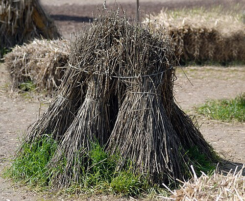

Berkas-berkas gandum spelta yang berdiri tegak di sebuah ladang

*Berkas gandum spelta. André Karwath aka Aka, CC BY-SA 2.5; lihat kredit media Unit 4.*

## Berkas

### Definisi 4.1: berkas

Misalkan $X$ sebuah ruang topologis. Sebuah *berkas* $\mathcal F$ pada $X$ adalah praberkas $\mathcal F$ pada $X$ yang memenuhi kedua sifat berikut.

1. Untuk setiap penutup terbuka

   $$U=\bigcup_{i\in I}U_i$$

   dan setiap $s,t\in\mathcal F(U)$ dengan

   $$\rho_{U,U_i}(s)=\rho_{U,U_i}(t)$$

   bagi semua $i\in I$, berlaku $s=t$.
2. Untuk setiap penutup terbuka

   $$U=\bigcup_{i\in I}U_i$$

   dan setiap keluarga $s_i\in\mathcal F(U_i)$ yang kompatibel, yakni

   $$\rho_{U_i,U_i\cap U_j}(s_i)
   =\rho_{U_j,U_i\cap U_j}(s_j)$$

   bagi semua $i,j\in I$, terdapat suatu $s\in\mathcal F(U)$ dengan

   $$s_i=\rho_{U,U_i}(s)$$

   bagi semua $i\in I$.

Kedua sifat ini disebut *syarat-syarat Serre*. Syarat pertama menyatakan bahwa kesamaan seksi dapat diperiksa secara lokal pada suatu penutup terbuka. Syarat kedua menyatakan bahwa seksi-seksi lokal yang saling cocok berasal dari sebuah seksi global. Seksi global itu tunggal menurut syarat pertama.

Nilai $\mathcal F(\varnothing)$ terdiri atas tepat satu unsur. Secara teori himpunan, hal ini mengikuti dengan menerapkan kedua syarat tersebut pada penutup himpunan kosong yang mempunyai himpunan indeks kosong.

Sebagai wakil dari banyak contoh serupa, kita tunjukkan bahwa praberkas seksi dari suatu pemetaan kontinu merupakan berkas.

### Contoh 4.2: berkas seksi kontinu

Kita lanjutkan Contoh 3.12. Misalkan $X$ dan $Y$ ruang topologis dan

$$p:Y\longrightarrow X$$

sebuah pemetaan kontinu tetap. Praberkas seksi kontinu di $Y$ diberikan oleh

$$U\longmapsto S(U,Y)
=\{s:U\to p^{-1}(U)\mid s\text{ seksi kontinu bagi }p\}.$$

Praberkas ini merupakan berkas. Syarat Serre pertama berlaku karena dua seksi sama apabila nilainya sama di setiap titik $P\in U$, dan kesamaan tersebut dapat diperiksa secara lokal pada penutup terbuka. Untuk syarat kedua, sebuah keluarga seksi kontinu yang kompatibel

$$s_i:U_i\longrightarrow Y|_{U_i}$$

secara langsung mendefinisikan sebuah seksi

$$s:U\longrightarrow Y|_U$$

yang sekaligus memperluas semua $s_i$. Pemetaan $s$ kontinu karena kontinuitas dapat diperiksa secara lokal.

### Contoh 4.3: berkas pemetaan kontinu bernilai grup

Misalkan $G$ sebuah grup topologis dan $X$ sebuah ruang topologis. Penetapan

$$U\longmapsto C^0(U,G)$$

merupakan berkas, yaitu berkas grup pemetaan kontinu bernilai di $G$. Sifat berkas mengikuti dari dua fakta: kesamaan pemetaan kontinu dapat diperiksa titik demi titik, dan pemetaan-pemetaan kontinu pada himpunan terbuka yang berimpit pada setiap irisan dapat dilem menjadi sebuah pemetaan kontinu global.

### Lema 4.4: uji lokal kesamaan seksi

Misalkan $\mathcal F$ sebuah berkas pada ruang topologis $X$, dan misalkan

$$s,t\in\mathcal F(X).$$

Jika

$$s_P=t_P$$

di tangkai $\mathcal F_P$ untuk setiap $P\in X$, maka $s=t$.

#### Bukti

Menurut hipotesis, untuk setiap $P\in X$ terdapat lingkungan terbuka

$$P\in U_P\subseteq X$$

sedemikian sehingga

$$\rho_{X,U_P}(s)=\rho_{X,U_P}(t).$$

Karena

$$X=\bigcup_{P\in X}U_P,$$

syarat berkas pertama memberikan $s=t$.

## Morfisme berkas

Morfisme berkas hanyalah morfisme praberkas antara dua berkas. Meskipun demikian, ada beberapa kekhususan penting yang berkaitan dengan injektivitas, surjektivitas, citra, dan uji isomorfisme lokal.

> **Catatan edisi - salah ketik pada judul sumber.** Sumber mencetak *Garbenmorpismen*; kata Jerman yang dimaksud ialah *Garbenmorphismen*. Edisi memakai istilah matematis yang benar, “morfisme berkas”.

### Lema 4.5: injektivitas dapat diuji pada tangkai

Misalkan $X$ sebuah ruang topologis dan

$$\varphi:\mathcal F\longrightarrow\mathcal G$$

sebuah morfisme berkas. Pernyataan berikut ekuivalen.

1. Pemetaan

   $$\varphi_U:\mathcal F(U)\longrightarrow\mathcal G(U)$$

   injektif untuk setiap himpunan terbuka $U\subseteq X$.
2. Pemetaan tangkai

   $$\varphi_P:\mathcal F_P\longrightarrow\mathcal G_P$$

   injektif untuk setiap $P\in X$.

#### Bukti

Pertama, andaikan semua pemetaan pada seksi di atas himpunan terbuka injektif. Misalkan $s_P,t_P\in\mathcal F_P$ dan

$$\varphi_P(s_P)=\varphi_P(t_P).$$

Kita dapat mewakili keduanya oleh seksi $s,t\in\mathcal F(U)$ pada suatu lingkungan terbuka $U$ dari $P$. Kesamaan di tangkai $\mathcal G_P$ memberikan lingkungan terbuka yang lebih kecil

$$P\in U'\subseteq U$$

dengan

$$\varphi_{U'}(s|_{U'})=\varphi_{U'}(t|_{U'}).$$

Injektivitas $\varphi_{U'}$ memberi $s|_{U'}=t|_{U'}$, sehingga $s_P=t_P$.

Sebaliknya, andaikan semua pemetaan tangkai injektif. Misalkan $s,t\in\mathcal F(U)$ dan $\varphi_U(s)=\varphi_U(t)$. Untuk setiap $P\in U$ kita memperoleh

$$\varphi_P(s_P)=\varphi_P(t_P),$$

maka $s_P=t_P$. Dengan menerapkan Lema 4.4 pada pembatasan berkas ke $U$, kita memperoleh $s=t$.

### Lema 4.6: uji isomorfisme pada tangkai

Misalkan $X$ sebuah ruang topologis dan

$$\varphi:\mathcal F\longrightarrow\mathcal G$$

sebuah morfisme berkas. Morfisme $\varphi$ merupakan isomorfisme berkas jika dan hanya jika, untuk setiap $P\in X$, pemetaan tangkai

$$\varphi_P:\mathcal F_P\longrightarrow\mathcal G_P$$

merupakan isomorfisme.

#### Bukti

Arah maju langsung. Untuk arah sebaliknya, kita harus menunjukkan bahwa

$$\varphi_U:\mathcal F(U)\longrightarrow\mathcal G(U)$$

bijektif untuk setiap himpunan terbuka $U\subseteq X$. Dengan membatasi kedua berkas, cukup membahas kasus $U=X$. Injektivitas mengikuti dari Lema 4.5.

Untuk surjektivitas, ambil $t\in\mathcal G(X)$. Bagi setiap $P\in X$, terdapat tepat satu $s_P\in\mathcal F_P$ dengan

$$\varphi_P(s_P)=t_P.$$

Pilih wakil $r_P\in\mathcal F(U_P)$ pada suatu lingkungan terbuka $U_P$ dari $P$. Karena $\varphi(r_P)$ dan $t$ mempunyai germ yang sama di $P$, setelah memperkecil $U_P$ bila perlu kita memperoleh

$$\varphi_{U_P}(r_P)=t|_{U_P}.$$

Himpunan-himpunan $U_P$ menutupi $X$. Pada $U_P\cap U_Q$ dan untuk setiap $Z\in U_P\cap U_Q$, kedua germ $(r_P)_Z$ dan $(r_Q)_Z$ dipetakan oleh isomorfisme $\varphi_Z$ ke $t_Z$. Jadi

$$(r_P)_Z=(r_Q)_Z.$$

Menurut Lema 4.4,

$$r_P|_{U_P\cap U_Q}=r_Q|_{U_P\cap U_Q}.$$

Syarat berkas kedua kemudian mengelem semua $r_P$ menjadi $r\in\mathcal F(X)$. Pada setiap $U_P$ berlaku $\varphi(r)|_{U_P}=t|_{U_P}$, sehingga syarat berkas pertama memberikan $\varphi(r)=t$.

Pernyataan ini tidak berlaku untuk praberkas - pertimbangkan, misalnya, berkasisasi suatu praberkas - dan juga tidak berlaku tanpa adanya sebuah morfisme di antara kedua berkas. Dua berkas yang isomorfik pada setiap tangkai belum tentu isomorfik sebagai berkas. Contoh pentingnya ialah berkas bebas lokal: secara lokal berkas semacam ini isomorfik dengan berkas bebas, tetapi secara umum tidak bebas secara global.

Sekilas mungkin mengejutkan bahwa, untuk morfisme berkas, surjektivitas pada seksi di atas himpunan terbuka berbeda dari surjektivitas pada tangkai. Perbedaan ini justru merupakan kekuatan teori berkas: kegagalan surjektivitas global dari morfisme yang surjektif pada setiap tangkai dapat mencerminkan sifat topologis ruang dasarnya.

### Definisi 4.7: morfisme berkas surjektif

Sebuah morfisme berkas

$$\varphi:\mathcal F\longrightarrow\mathcal G$$

pada ruang topologis $X$ disebut *surjektif* jika, untuk setiap titik $P\in X$, pemetaan tangkai

$$\varphi_P:\mathcal F_P\longrightarrow\mathcal G_P$$

surjektif. Sifat ini jauh lebih lemah daripada surjektivitas pemetaan seksi di atas setiap himpunan terbuka.

### Contoh 4.8: surjektif pada tangkai, tidak selalu pada seksi

Perhatikan homomorfisme grup kontinu

$$\varphi:\mathbb R\longrightarrow S^1,
\qquad
t\longmapsto(\cos t,\sin t),$$

yaitu parametrisasi trigonometrik periodik lingkaran satuan. Pada setiap ruang topologis $X$, pemetaan ini menginduksi morfisme berkas

$$C^0(-,\mathbb R)\longrightarrow C^0(-,S^1),$$

yang mengirim fungsi kontinu $f:U\to\mathbb R$ ke komposisi

$$\varphi\circ f:U\longrightarrow S^1.$$

Morfisme ini surjektif karena $\varphi$ dapat dibalik secara lokal. Namun, pemetaan pada seksi tidak selalu surjektif. Jika $X=S^1$, misalnya, identitas pada $S^1$ tidak mempunyai pengangkatan kontinu ke $\mathbb R$.

### Lema 4.9: berkas morfisme

Untuk dua berkas $\mathcal F$ dan $\mathcal G$ pada ruang topologis $X$, penetapan

$$U\longmapsto
\operatorname{Mor}(\mathcal F|_U,\mathcal G|_U)$$

merupakan sebuah berkas.

#### Bukti

Restriksi sebuah morfisme berkas

$$\varphi:\mathcal F|_U\longrightarrow\mathcal G|_U$$

ke setiap himpunan terbuka $V\subseteq U$ memberikan morfisme

$$\varphi|_V:\mathcal F|_V\longrightarrow\mathcal G|_V.$$

Jadi penetapan di atas mula-mula merupakan praberkas.

Misalkan $U=\bigcup_{i\in I}U_i$. Untuk syarat kesamaan, misalkan $\varphi$ dan $\psi$ dua morfisme pada $U$ yang restriksinya sama pada setiap $U_i$. Bagi setiap himpunan terbuka $V\subseteq U$ dan setiap $s\in\mathcal F(V)$, seksi $\varphi_V(s)$ dan $\psi_V(s)$ pada $\mathcal G(V)$ sama setelah direstriksi ke setiap $V\cap U_i$. Syarat berkas pertama untuk $\mathcal G$ memberikan $\varphi_V(s)=\psi_V(s)$. Karena ini berlaku untuk semua $V$ dan $s$, kita memperoleh $\varphi=\psi$.

Untuk syarat pengeleman, misalkan diberikan morfisme

$$\varphi_i:\mathcal F|_{U_i}\longrightarrow\mathcal G|_{U_i}$$

yang memenuhi

$$\varphi_i|_{U_i\cap U_j}=\varphi_j|_{U_i\cap U_j}.$$

Untuk setiap himpunan terbuka $V\subseteq U$ dan setiap $s\in\mathcal F(V)$, tetapkan pada $V\cap U_i$

$$t_i=(\varphi_i)_{V\cap U_i}(s|_{V\cap U_i}).$$

Keluarga $(t_i)$ kompatibel pada semua irisan, sehingga terdapat tepat satu $t\in\mathcal G(V)$ dengan $t|_{V\cap U_i}=t_i$. Tetapkan

$$\varphi_V(s):=t.$$

Jika $W\subseteq V$, maka $\varphi_V(s)|_W$ dan $\varphi_W(s|_W)$ mempunyai restriksi lokal yang sama pada setiap $W\cap U_i$; ketunggalan pengeleman menunjukkan bahwa keduanya sama. Jadi keluarga $\varphi_V$ kompatibel dengan semua pemetaan restriksi dan benar-benar mendefinisikan morfisme berkas

$$\varphi:\mathcal F|_U\longrightarrow\mathcal G|_U.$$

Restriksinya pada setiap $U_i$ adalah $\varphi_i$, juga menurut ketunggalan pengeleman.

> **Catatan edisi - pelengkapan pembuktian sumber.** Pembuktian sumber melakukan pemeriksaan kesamaan dan konstruksi pengeleman hanya pada seksi di atas $U$. Sebuah morfisme berkas harus mempunyai komponen pada setiap himpunan terbuka $V\subseteq U$ dan harus komutatif dengan restriksi. Pembuktian di atas menampilkan langkah standar yang hilang, menggunakan penutup $(V\cap U_i)_i$ dan ketunggalan pengeleman. Bentuk ringkas sumber tetap dipertahankan dalam batas otoritas Unit 4.

### Korolari 4.10: mengeleman morfisme berkas

Misalkan

$$X=\bigcup_{i\in I}U_i$$

sebuah penutup terbuka ruang topologis $X$, dan misalkan $\mathcal F$ dan $\mathcal G$ berkas pada $X$. Untuk setiap $i\in I$, misalkan diberikan morfisme berkas

$$\alpha_i:\mathcal F|_{U_i}\longrightarrow\mathcal G|_{U_i}$$

dengan

$$\alpha_i|_{U_i\cap U_j}=\alpha_j|_{U_i\cap U_j}$$

bagi semua $i,j$. Maka terdapat tepat satu morfisme berkas

$$\alpha:\mathcal F\longrightarrow\mathcal G$$

yang memenuhi $\alpha|_{U_i}=\alpha_i$ untuk setiap $i$.

#### Bukti

Pernyataan ini langsung mengikuti Lema 4.9.

### Korolari 4.11: uji kesamaan pada tangkai

Misalkan $\mathcal F$ dan $\mathcal G$ berkas pada ruang topologis $X$, dan misalkan

$$\alpha,\beta:\mathcal F\longrightarrow\mathcal G$$

morfisme berkas. Maka

$$\alpha=\beta$$

jika dan hanya jika

$$\alpha_P=\beta_P$$

untuk setiap $P\in X$.

> **Catatan edisi - indeks sumber tidak konsisten.** Sumber menulis $\alpha_p=\beta_P$ setelah mengkuantifikasi titik $P$. Edisi memakai indeks yang konsisten, $\alpha_P=\beta_P$.

#### Bukti

Pernyataan ini langsung mengikuti Lema 4.9 dan Lema 4.4.

# Lembar Kerja 4: Berkas dan Morfisme Berkas

## Soal 4.1

Misalkan $\mathcal F$ dan $\mathcal G$ berkas pada ruang topologis $X$. Tunjukkan bahwa penetapan

$$U\longmapsto\mathcal F(U)\times\mathcal G(U),$$

bersama pemetaan produk alami sebagai pemetaan restriksi, mendefinisikan sebuah berkas pada $X$.

## Soal 4.2

Misalkan $\mathcal G$ sebuah berkas pada ruang tak terhubung $X$ yang mempunyai dekomposisi

$$X=U\mathbin{\uplus}V$$

menjadi dua himpunan terbuka tak kosong yang saling lepas. Tunjukkan bahwa

$$\mathcal G(X)=\mathcal G(U)\times\mathcal G(V).$$

## Soal 4.3

Misalkan $X$ sebuah ruang topologis dengan dekomposisi

$$X=Y\mathbin{\uplus}Z$$

menjadi dua subhimpunan terbuka tak kosong yang saling lepas. Misalkan $\mathcal G$ sebuah berkas pada $Y$ dan $\mathcal H$ sebuah berkas pada $Z$. Tunjukkan bahwa, untuk setiap himpunan terbuka $U\subseteq X$, penetapan

$$\mathcal F(U)
=\mathcal G(U\cap Y)\times\mathcal H(U\cap Z)$$

mendefinisikan sebuah berkas $\mathcal F$ pada $X$.

## Soal 4.4

Misalkan $X$ sebuah ruang Hausdorff dengan sekurang-kurangnya dua titik dan misalkan $M$ sebuah himpunan dengan sekurang-kurangnya dua unsur. Tunjukkan bahwa praberkas konstan yang bernilai $M$ bukan sebuah berkas.

> **Catatan edisi - hipotesis sumber tidak cukup kuat.** Sumber hanya mengasumsikan $M\ne\varnothing$. Kesimpulannya salah jika $M$ berunsur tunggal, sebab praberkas konstan bernilai satu unsur memenuhi kedua syarat berkas. Edisi menyatakan hipotesis yang dimaksud, yaitu bahwa $M$ mempunyai sekurang-kurangnya dua unsur.

## Soal 4.5

Tunjukkan bahwa pembatasan sebuah berkas ke suatu subhimpunan terbuka

$$U\subseteq X$$

merupakan sebuah berkas.

## Soal 4.6

Tunjukkan bahwa tangkai di $0\in\mathbb C$ dari berkas fungsi holomorfik isomorfik dengan gelanggang deret pangkat konvergen dalam satu variabel.

## Soal 4.7

Misalkan

$$\varphi:\mathcal F\longrightarrow\mathcal G$$

sebuah morfisme berkas pada ruang topologis $X$. Andaikan

$$\varphi_U:\mathcal F(U)\longrightarrow\mathcal G(U)$$

surjektif untuk setiap himpunan terbuka $U\subseteq X$. Tunjukkan bahwa setiap pemetaan tangkai

$$\varphi_P:\mathcal F_P\longrightarrow\mathcal G_P$$

juga surjektif.

## Soal 4.8

Misalkan $\mathcal G$ sebuah berkas grup komutatif pada ruang topologis $X$. Tunjukkan bahwa

$$\mathcal G(\varnothing)=0,$$

yakni bahwa nilai berkas pada himpunan kosong adalah grup trivial.

## Soal 4.9

Misalkan $X$ sebuah ruang topologis, $P\in X$ sebuah titik, dan $G$ sebuah grup komutatif. Pertimbangkan penetapan

$$U\longmapsto
\mathcal G(U):=
\begin{cases}
G,&\text{jika }P\in U,\\
0,&\text{jika }P\notin U,
\end{cases}$$

dengan pemetaan restriksi yang wajar untuk setiap inklusi himpunan terbuka $V\subseteq U$.

1. Tunjukkan bahwa $\mathcal G$ merupakan sebuah berkas grup komutatif.
2. Tentukan tangkai $\mathcal G_P$.
3. Sekarang andaikan $P$ sebuah titik tertutup. Tentukan tangkai $\mathcal G_Q$ untuk setiap titik $Q\ne P$.

> **Catatan edisi - dua salah ketik sumber.** Perintah terakhir pada sumber berbunyi *Besitmme die Halm*. Bentuk yang dimaksud ialah *Bestimme die Halme*, yaitu menentukan tangkai-tangkai pada semua titik $Q\ne P$.

Berkas yang dikonstruksi dalam soal di atas disebut *berkas pencakar langit* dengan nilai $G$ di titik $P$.

# Cakupan Solusi Publik Lembar Kerja 4

Pada batas revisi yang dibekukan, sumber tidak menyediakan solusi publik untuk satu pun dari sembilan soal pada Lembar Kerja 4. Kueri kandidat solusi dan peta soal yang dibekukan mencatat hasil negatif untuk Soal 4.1-4.9.

Tidak ada solusi baru yang dibuat untuk edisi ini. Bagian ini hanya mendokumentasikan cakupan sumber agar ketiadaan solusi tidak disalahartikan sebagai kehilangan isi selama penerjemahan.

# Kredit media BGK Unit 4

Sumber kursus: **Kurs:Bündel, Garben und Kohomologie (Osnabrück 2019-2020)**, Kurs:Bündel, Garben und Kohomologie (Osnabrück 2019-2020)/Vorlesung 4. Satu posisi media substantif mempertahankan identitas Commons dan lisensi komponennya. Dua PDF resmi adalah saksi authority, bukan posisi media pembaca tambahan.

1. **Berkas gandum spelta** - File:Triticum spelta - shock (aka).jpg; pencipta/atribusi: André Karwath aka Aka; lisensi/status hak: [CC BY-SA 2.5](https://creativecommons.org/licenses/by-sa/2.5).

# Kuliah 5: Berkasisasi, Homomorfisme, dan Berkas Hasil Bagi

## Berkasisasi

Sebuah praberkas dapat secara kanonik dikaitkan dengan sebuah berkas. Konstruksi ini disebut *berkasisasi*.

### Definisi 5.1: berkasisasi

Misalkan $\mathcal F$ sebuah praberkas pada ruang topologis $X$. Praberkas yang diberikan oleh

$$\widetilde{\mathcal F}(U)
:=
\left\{
(s_P)_{P\in U}\in\prod_{P\in U}\mathcal F_P
\ \middle|\
\begin{array}{l}
\text{untuk setiap }P\in U\text{ terdapat himpunan terbuka }V\\
\text{dengan }P\in V\subseteq U\text{ dan }t\in\mathcal F(V)\\
\text{sedemikian sehingga }s_Q=t_Q\text{ di }\mathcal F_Q
\text{ bagi setiap }Q\in V
\end{array}
\right\},$$

bersama pemetaan restriksi alami, disebut *berkasisasi* dari $\mathcal F$.

Syarat dalam definisi ini, yakni bahwa seksi-seksi lokal mendefinisikan germ yang sama di setiap tangkai, juga disebut *syarat kompatibilitas*.

> **Catatan edisi - sifat terbuka lingkungan lokal.** Rumus sumber hanya menulis $P\in V\subseteq U$ tanpa menyebutkan bahwa $V$ terbuka. Karena $\mathcal F(V)$ dan konstruksi lokal ini menggunakan objek praberkas, $V$ harus berupa lingkungan terbuka. Edisi menyatakan syarat tersebut secara eksplisit.

### Lema 5.2: sifat-sifat berkasisasi

Misalkan $\mathcal F$ sebuah praberkas pada ruang topologis $X$, dan misalkan $\widetilde{\mathcal F}$ berkasisasinya. Sifat-sifat berikut berlaku.

1. Terdapat morfisme praberkas alami

   $$\eta:\mathcal F\longrightarrow\widetilde{\mathcal F},$$

   yang pada setiap himpunan terbuka $U$ diberikan oleh

   $$\begin{aligned}
   \eta_U:\mathcal F(U)&\longrightarrow\widetilde{\mathcal F}(U),\\
   s&\longmapsto(s_P)_{P\in U}.
   \end{aligned}$$
2. Untuk setiap $P\in X$, terdapat isomorfisme alami

   $$\widetilde{\mathcal F}_P\cong\mathcal F_P.$$
3. Berkasisasi $\widetilde{\mathcal F}$ merupakan sebuah berkas.
4. Jika $\mathcal F$ sudah merupakan sebuah berkas, maka morfisme alami

   $$\mathcal F\longrightarrow\widetilde{\mathcal F}$$

   merupakan isomorfisme.
5. Untuk setiap morfisme praberkas

   $$\psi:\mathcal F\longrightarrow\mathcal G$$

   ke sebuah berkas $\mathcal G$, terdapat tepat satu faktorisasi

   $$\widetilde\psi:
   \widetilde{\mathcal F}\longrightarrow\mathcal G.$$

#### Bukti

1. Sebuah unsur $s\in\mathcal F(U)$ mendefinisikan tupel

   $$(s_P)_{P\in U},$$

   yang langsung memenuhi syarat kompatibilitas. Jadi terdapat pemetaan yang terdefinisi dengan baik

   $$\eta_U:\mathcal F(U)\longrightarrow\widetilde{\mathcal F}(U).$$

   Jika $V\subseteq U$, terdapat diagram komutatif

   $$\begin{array}{ccc}
   \mathcal F(U)
   &\xrightarrow{\ \eta_U\ }&
   \displaystyle\prod_{P\in U}\mathcal F_P\\[2mm]
   {\scriptstyle\rho_{U,V}}\downarrow
   &&
   \downarrow\\[2mm]
   \mathcal F(V)
   &\xrightarrow{\ \eta_V\ }&
   \displaystyle\prod_{P\in V}\mathcal F_P.
   \end{array}$$

   Komutativitasnya mengikuti dari fakta bahwa germ suatu seksi pada tangkai di sebuah titik hanya bergantung pada lingkungan-lingkungan terbuka titik tersebut.
2. Menurut bagian (1) dan Lema 3.27, terdapat pemetaan alami

   $$\mathcal F_P\longrightarrow\widetilde{\mathcal F}_P.$$

   Untuk membuktikan surjektivitasnya, ambil $s\in\widetilde{\mathcal F}_P$, yang diwakili oleh suatu

   $$s'\in\widetilde{\mathcal F}(U).$$

   Pada suatu lingkungan terbuka $V\subseteq U$ dari $P$, seksi tersebut diwakili oleh sebuah unsur

   $$s''\in\mathcal F(V).$$

   Germ $s''_P\in\mathcal F_P$ langsung merupakan praimaj dari $s$.

   Untuk membuktikan injektivitasnya, misalkan $s,t\in\mathcal F_P$ mempunyai citra yang sama dalam $\widetilde{\mathcal F}_P$. Kita dapat menganggap $s$ dan $t$ diwakili oleh seksi-seksi pada himpunan terbuka yang sama, katakanlah $U$. Kesamaan di tangkai berkasisasi berarti bahwa terdapat lingkungan terbuka $P\in V\subseteq U$ dengan

   $$(s_Q)_{Q\in V}=(t_Q)_{Q\in V}.$$

   Khususnya, germ kedua seksi di $P$ sama, sehingga $s=t$ dalam $\mathcal F_P$.
3. Misalkan

   $$U=\bigcup_{i\in I}U_i$$

   sebuah penutup terbuka, dan misalkan

   $$s,t\in\Gamma(U,\widetilde{\mathcal F})$$

   memenuhi

   $$s|_{U_i}=t|_{U_i}$$

   bagi setiap $i$. Setiap titik $P\in U$ terletak di suatu $U_i$, sehingga

   $$s_P=t_P$$

   bagi setiap $P\in U$. Jadi kedua tupel di dalam produk tangkai sama, dan karenanya $s=t$ dalam berkasisasi.

   Sekarang misalkan diberikan seksi-seksi

   $$s_i\in\widetilde{\mathcal F}(U_i)$$

   dengan

   $$s_i|_{U_i\cap U_j}=s_j|_{U_i\cap U_j}.$$

   Untuk setiap $P\in U$, salah satu $s_i$ dengan $P\in U_i$ menentukan sebuah germ $s_P$. Germ ini tunggal karena syarat kompatibilitas pada irisan. Tupel

   $$(s_P)_{P\in U}$$

   langsung memenuhi syarat kompatibilitas dalam definisi berkasisasi. Dengan demikian, $\widetilde{\mathcal F}$ memenuhi kedua syarat berkas.
4. Menurut bagian (1), terdapat morfisme praberkas

   $$\mathcal F\longrightarrow\widetilde{\mathcal F}.$$

   Menurut bagian (2), morfisme ini bijektif pada setiap tangkai. Sisi kiri merupakan berkas menurut hipotesis, dan sisi kanan merupakan berkas menurut bagian (3). Lema 4.6 menunjukkan bahwa morfisme tersebut merupakan isomorfisme.
5. Lihat Soal 5.2. $\square$

> **Catatan edisi - salah artikel pada sumber.** Pada butir (4), sumber mencetak *die natürliche Morphismus*. Bentuk Jerman yang benar ialah *der natürliche Morphismus*. Terjemahan memakai bentuk matematis yang dimaksud, yaitu “morfisme alami”. (Salah ketik judul *Garbenmorpismen* pada sumber juga dipertahankan sebagai bagian dari catatan otoritas Unit 4; istilah yang dipakai di sini tetap “morfisme berkas”.)

## Homomorfisme berkas grup

### Definisi 5.3: homomorfisme berkas grup komutatif

Misalkan $X$ sebuah ruang topologis, dan misalkan $\mathcal F$ serta $\mathcal G$ berkas grup komutatif pada $X$. Sebuah morfisme berkas

$$\varphi:\mathcal F\longrightarrow\mathcal G$$

disebut *homomorfisme berkas grup komutatif* jika, untuk setiap himpunan terbuka $U\subseteq X$, pemetaan

$$\varphi_U:\mathcal F(U)\longrightarrow\mathcal G(U)$$

merupakan homomorfisme grup.

### Contoh 5.4: homomorfisme yang diinduksi oleh grup topologis

Sebuah homomorfisme grup kontinu

$$\varphi:F\longrightarrow G$$

di antara grup-grup topologis $F$ dan $G$ menentukan, pada setiap ruang topologis $X$, sebuah homomorfisme berkas grup. Pada setiap himpunan terbuka $U$, homomorfisme itu diberikan oleh

$$\begin{aligned}
C^0(U,F)&\longrightarrow C^0(U,G),\\
f&\longmapsto\varphi\circ f.
\end{aligned}$$

> **Catatan lingkup.** Definisi 5.3 dirumuskan untuk berkas grup komutatif, sedangkan contoh sumber ini memakai grup topologis umum. Konstruksi komposisi di atas memang tidak memerlukan komutativitas; karena itu edisi menyebutnya homomorfisme berkas grup pada tingkat umum.

### Definisi 5.5: berkas kernel

Misalkan $X$ sebuah ruang topologis dan

$$\varphi:\mathcal F\longrightarrow\mathcal G$$

sebuah homomorfisme berkas grup komutatif. Subberkas dari $\mathcal F$ yang didefinisikan oleh

$$(\ker\varphi)(U):=\ker\varphi_U$$

disebut *berkas kernel* dari $\varphi$.

Lebih tepatnya, berkas tersebut merupakan subberkas grup komutatif: bagi setiap himpunan terbuka $U$, nilainya adalah sebuah subgrup dari $\mathcal F(U)$; lihat Soal 5.6.

### Definisi 5.6: berkas citra

Misalkan $X$ sebuah ruang topologis dan

$$\varphi:\mathcal F\longrightarrow\mathcal G$$

sebuah homomorfisme berkas grup komutatif. Berkasisasi dari praberkas yang diberikan oleh

$$(\operatorname{im}\varphi)(U):=\operatorname{im}\varphi_U$$

disebut *berkas citra* dari $\varphi$.

Menurut Lema 5.2(5), berkas citra secara alami merupakan subberkas $\mathcal G$, dan lebih tepatnya subberkas grup komutatif. Berkas ini ditulis $\operatorname{im}\varphi$.

### Contoh 5.7: homomorfisme bundel vektor trivial

Misalkan $X$ sebuah ruang topologis dan

$$\varphi:X\times\mathbb R^n\longrightarrow X\times\mathbb R^m$$

sebuah homomorfisme di antara bundel-bundel vektor trivial. Homomorfisme ini dideskripsikan oleh sebuah pemetaan kontinu

$$M:X\longrightarrow
\operatorname{Mat}_{m\times n}\bigl(C^0(X,\mathbb R)\bigr),$$

yakni setiap titik secara kontinu dipasangkan dengan sebuah matriks yang pada titik tersebut mendeskripsikan pemetaan linear $\mathbb R^n\to\mathbb R^m$. Hal ini langsung dapat dipandang sebagai homomorfisme berkas grup pada $X$:

$$\begin{aligned}
C^0(-,\mathbb R)^n&\longrightarrow C^0(-,\mathbb R)^m,\\
\begin{pmatrix}
f_1\\
\vdots\\
f_n
\end{pmatrix}
&\longmapsto
M
\begin{pmatrix}
f_1\\
\vdots\\
f_n
\end{pmatrix}.
\end{aligned}$$

Dalam Contoh 1.2, untuk $X=\mathbb R^3$, terdapat pemetaan

$$\begin{aligned}
\varphi:\mathbb R^3\times\mathbb R^3
&\longrightarrow\mathbb R^3\times\mathbb R,\\
(r,s,t;u,v,w)&\longmapsto(r,s,t;ru+sv+tw),
\end{aligned}$$

atau, secara ekuivalen,

$$\begin{aligned}
M:\mathbb R^3&\longrightarrow
\operatorname{Mat}_{1\times3}(K),\\
(r,s,t)&\longmapsto(r,s,t).
\end{aligned}$$

> **Catatan edisi - dua ketidakcocokan jenis pada notasi matriks sumber.** Sumber menulis $M:X\to\operatorname{Mat}_{m\times n}(C^0(X,\mathbb R))$, sedangkan uraian sesudahnya memperlakukan $M$ sebagai fungsi matriks bernilai titik. Bentuk berjenis yang lazim ialah $M:X\to\operatorname{Mat}_{m\times n}(\mathbb R)$, atau secara ekuivalen $M\in\operatorname{Mat}_{m\times n}(C^0(X,\mathbb R))$. Pada contoh real konkret, sumber juga menulis $\operatorname{Mat}_{1\times3}(K)$ meskipun $K$ tidak didefinisikan dan konteksnya menggunakan $\mathbb R$. Kedua rumus sumber dipertahankan di atas agar penyimpangan tersebut tetap terlihat.

Berkas kernel di atas $U$ adalah

$$\begin{aligned}
(\ker\varphi)(U)
&=
\left\{
\begin{pmatrix}
f_1\\
\vdots\\
f_n
\end{pmatrix}
\in C^0(U,\mathbb R)^n
\ \middle|\
M
\begin{pmatrix}
f_1\\
\vdots\\
f_n
\end{pmatrix}
=0
\right\}\\
&\subseteq C^0(U,\mathbb R)^n.
\end{aligned}$$

## Berkas hasil bagi

### Definisi 5.8: berkas hasil bagi

Misalkan $\mathcal G$ sebuah berkas grup komutatif dan

$$\mathcal F\subseteq\mathcal G$$

sebuah subberkas grup. Berkasisasi dari praberkas

$$U\longmapsto\mathcal G(U)/\mathcal F(U)$$

disebut *berkas hasil bagi* dari $\mathcal G$ oleh $\mathcal F$.

Berkas hasil bagi ditulis $\mathcal G/\mathcal F$. Karena konstruksinya memakai berkasisasi, secara umum tidak harus berlaku

$$(\mathcal G/\mathcal F)(U)
=
\mathcal G(U)/\mathcal F(U).$$

Namun, untuk setiap titik $P\in X$, berlaku

$$(\mathcal G/\mathcal F)_P
=
\mathcal G_P/\mathcal F_P;$$

lihat Soal 5.11.

### Lema 5.9: deskripsi eksplisit berkas hasil bagi

Misalkan $\mathcal G$ sebuah berkas grup komutatif dan

$$\mathcal F\subseteq\mathcal G$$

sebuah subberkas grup, dengan berkas hasil bagi $\mathcal G/\mathcal F$. Pernyataan berikut berlaku.

1. Setiap unsur

   $$s\in\Gamma(X,\mathcal G/\mathcal F)$$

   diwakili oleh suatu keluarga

   $$(U_i,g_i)_{i\in I},$$

   dengan

   $$X=\bigcup_{i\in I}U_i$$

   sebuah penutup terbuka dan

   $$g_i\in\Gamma(U_i,\mathcal G),$$

   sedemikian sehingga

   $$g_i|_{U_i\cap U_j}-g_j|_{U_i\cap U_j}
   \in\Gamma(U_i\cap U_j,\mathcal F).$$

   Setiap keluarga semacam itu menentukan sebuah unsur $\Gamma(X,\mathcal G/\mathcal F)$.
2. Dua keluarga

   $$(U_i,g_i)_{i\in I}
   \qquad\text{dan}\qquad
   (U_i,h_i)_{i\in I}$$

   pada penutup terbuka yang sama menentukan unsur yang sama dalam

   $$\Gamma(X,\mathcal G/\mathcal F)$$

   tepat ketika

   $$g_i-h_i\in\Gamma(U_i,\mathcal F)$$

   bagi setiap $i$.
3. Dua keluarga

   $$(U_i,g_i)_{i\in I}
   \qquad\text{dan}\qquad
   (V_j,h_j)_{j\in J}$$

   menentukan unsur yang sama tepat ketika, pada suatu - dan karenanya pada setiap - penghalusan bersama kedua penutup, selisih seksi-seksinya termasuk dalam $\mathcal F$.

#### Bukti

1. Homomorfisme berkas kanonik

   $$\mathcal G\longrightarrow\mathcal G/\mathcal F$$

   bersifat surjektif. Oleh karena itu, setiap seksi

   $$s\in\Gamma(X,\mathcal G/\mathcal F)$$

   mempunyai praimaj secara lokal. Dengan demikian, terdapat penutup terbuka

   $$X=\bigcup_{i\in I}U_i$$

   dan unsur-unsur

   $$g_i\in\Gamma(U_i,\mathcal G)$$

   yang dipetakan ke $s|_{U_i}$. Maka

   $$g_i|_{U_i\cap U_j}-g_j|_{U_i\cap U_j}
   \in\Gamma(U_i\cap U_j,\mathcal G)$$

   dipetakan ke nol, sehingga selisih ini termasuk dalam kernel, yakni $\mathcal F$.

   Sebaliknya, sebuah keluarga yang memenuhi syarat tersebut menentukan kelas-kelas

   $$[g_i]\in\Gamma(U_i,\mathcal G/\mathcal F).$$

   Pada setiap irisan berlaku

   $$\begin{aligned}
   [g_i]|_{U_i\cap U_j}-[g_j]|_{U_i\cap U_j}
   &=
   [g_i|_{U_i\cap U_j}-g_j|_{U_i\cap U_j}]\\
   &=0.
   \end{aligned}$$

   Jadi kelas-kelas tersebut kompatibel dan menentukan sebuah seksi global berkas hasil bagi.
2. Dengan mengganti kedua keluarga oleh keluarga selisihnya, cukup dibahas kasus $h_i=0$. Kita harus menunjukkan bahwa $(U_i,g_i)$ menentukan unsur nol dalam berkas hasil bagi tepat ketika setiap

   $$g_i\in\Gamma(U_i,\mathcal F).$$

   Jika keluarga tersebut menentukan unsur nol, citranya pada setiap tangkai juga nol. Jadi, untuk setiap $P\in U_i$, germnya memenuhi

   $$(g_i)_P\in\mathcal F_P.$$

   Keanggotaan pada sebuah subberkas dapat diuji pada tangkai, sehingga

   $$g_i\in\Gamma(U_i,\mathcal F).$$

   Arah sebaliknya langsung.
3. Kesamaan seksi sebuah berkas dapat diuji secara lokal pada sebarang penutup terbuka. Pernyataan mengikuti dari bagian (2) serta fakta bahwa keanggotaan pada sebuah subberkas juga dapat diuji secara lokal. $\square$

> **Catatan edisi - seksi dan germ pada pembuktian sumber.** Pada butir (2), sumber menulis $g_i\in\mathcal F_P$, padahal $g_i$ adalah seksi di $U_i$, sedangkan $\mathcal F_P$ adalah tangkai. Pernyataan berjenis yang dipakai di atas ialah $(g_i)_P\in\mathcal F_P$.

# Lembar Kerja 5: Berkasisasi dan Berkas Hasil Bagi

## Soal 5.1

Misalkan $X$ sebuah ruang topologis dan $\mathcal F$ sebuah praberkas pada $X$. Tunjukkan bahwa penetapan

$$U\longmapsto\prod_{P\in U}\mathcal F_P,$$

yakni himpunan produk semua tangkai di titik-titik $U$, bersama proyeksi alami sebagai pemetaan restriksi, mendefinisikan sebuah praberkas. Tunjukkan pula bahwa terdapat morfisme praberkas alami dari $\mathcal F$ ke praberkas tersebut.

## Soal 5.2

Misalkan $\mathcal F$ sebuah praberkas pada ruang topologis $X$, dan misalkan $\widetilde{\mathcal F}$ berkasisasinya. Tunjukkan bahwa, untuk setiap morfisme praberkas

$$\psi:\mathcal F\longrightarrow\mathcal G$$

ke sebuah berkas $\mathcal G$, terdapat tepat satu faktorisasi

$$\widetilde\psi:
\widetilde{\mathcal F}\longrightarrow\mathcal G.$$

Berkasisasi sebuah praberkas konstan disebut *berkas konstan lokal*, dan kadang-kadang juga disebut cukup sebagai *berkas konstan*.

## Soal 5.3

Misalkan $\mathcal F$ praberkas konstan bernilai suatu himpunan $M$ pada ruang topologis $X$. Tunjukkan bahwa tangkai berkasisasi $\mathcal F$ di setiap titik

$$P\in X$$

sama dengan $M$.

## Soal 5.4

Misalkan $G$ sebuah grup topologis diskret dan $X$ sebuah ruang topologis. Misalkan $\mathcal G$ praberkas konstan bernilai $G$ pada $X$. Tunjukkan bahwa berkasisasi $\mathcal G$ sama dengan

$$C^0(-,G).$$

## Soal 5.5*

Misalkan $X$ sebuah ruang topologis, $\mathcal G$ sebuah berkas pada $X$, dan

$$\mathcal F\subseteq\mathcal G$$

sebuah subberkas. Misalkan

$$t\in\Gamma(X,\mathcal G)$$

memenuhi

$$t_P\in\mathcal F_P$$

untuk setiap

$$P\in X.$$

Tunjukkan bahwa

$$t\in\Gamma(X,\mathcal F).$$

## Soal 5.6

Misalkan $X$ sebuah ruang topologis dan

$$\varphi:\mathcal F\longrightarrow\mathcal G$$

sebuah homomorfisme berkas grup komutatif. Tunjukkan bahwa penetapan

$$(\ker\varphi)(U):=\ker\varphi_U$$

mendefinisikan sebuah berkas grup pada $X$.

## Soal 5.7

Misalkan $X$ sebuah ruang topologis dan

$$\varphi:\mathcal F\longrightarrow\mathcal G$$

sebuah homomorfisme berkas grup komutatif. Tunjukkan bahwa $\varphi$ injektif tepat ketika

$$\ker\varphi$$

merupakan berkas nol.

## Soal 5.8

Misalkan $X$ sebuah ruang topologis dan

$$\varphi:\mathcal F\longrightarrow\mathcal G$$

sebuah homomorfisme berkas grup komutatif. Tunjukkan bahwa $\varphi$ surjektif tepat ketika

$$\operatorname{im}\varphi=\mathcal G.$$

## Soal 5.9

Misalkan $X$ sebuah ruang topologis dan

$$\varphi:\mathcal F\longrightarrow\mathcal G$$

sebuah homomorfisme berkas grup komutatif. Tunjukkan bahwa, untuk setiap

$$P\in X,$$

berlaku

$$(\operatorname{im}\varphi)_P
=
\operatorname{im}(\varphi_P).$$

## Soal 5.10

Misalkan $\mathcal G$ sebuah berkas grup komutatif dan

$$\mathcal F\subseteq\mathcal G$$

sebuah subberkas grup. Tunjukkan bahwa terdapat homomorfisme berkas grup komutatif yang kanonik dan surjektif

$$\mathcal G\longrightarrow\mathcal G/\mathcal F.$$

## Soal 5.11

Misalkan $\mathcal G$ sebuah berkas grup komutatif dan

$$\mathcal F\subseteq\mathcal G$$

sebuah subberkas grup, dan misalkan $\mathcal G/\mathcal F$ berkas hasil baginya. Tunjukkan bahwa

$$(\mathcal G/\mathcal F)_P
=
\mathcal G_P/\mathcal F_P$$

untuk setiap titik

$$P\in X.$$

# Solusi Publik dan Cakupan Lembar Kerja 5

Pada batas revisi yang dibekukan, sumber menyediakan tepat satu solusi publik di antara sebelas soal pada Lembar Kerja 5, yaitu solusi Soal 5.5. Peta soal dan bukti kandidat yang dibekukan mencatat hasil negatif untuk Soal 5.1-5.4 dan 5.6-5.11. Tidak ada solusi baru yang dibuat untuk edisi ini.

## Solusi sumber untuk Soal 5.5

Keanggotaan pada tangkai

$$t_P\in\mathcal F_P$$

berarti bahwa terdapat lingkungan terbuka

$$P\in U_P$$

dan sebuah seksi

$$s_P\in\mathcal F(U_P)\subseteq\mathcal G(U_P)$$

yang germnya di $P$ sama dengan $t_P$. Dengan demikian, terdapat lingkungan terbuka yang lebih kecil

$$P\in V_P\subseteq U_P$$

sedemikian sehingga restriksi $t$ dan $s_P$, dipandang sebagai seksi-seksi $\mathcal G$, berimpit pada $V_P$.

Jadi terdapat penutup terbuka

$$X=\bigcup_{i\in I}V_i$$

sedemikian sehingga

$$t|_{V_i}\in\mathcal F(V_i)\subseteq\mathcal G(V_i).$$

Seksi-seksi ini kompatibel, baik sebagai seksi $\mathcal G$ maupun sebagai seksi $\mathcal F$. Oleh karena itu, terdapat sebuah seksi

$$s\in\mathcal F(X)$$

yang restriksinya pada setiap $V_i$ adalah $t|_{V_i}$. Karena sebuah keluarga kompatibel dalam suatu berkas mempunyai tepat satu realisasi global, berlaku

$$s=t$$

di $\mathcal G(X)$. Dengan demikian,

$$t\in\mathcal F(X).$$

> **Catatan edisi - seksi dan germ.** Sumber menyatakan bahwa seksi lokal “membatasi ke” germ $t_P$. Secara tepat, germ $s_{P}$ dari seksi lokal $s_P$ di titik $P$ sama dengan $t_P$; terjemahan memakai hubungan berjenis ini tanpa mengubah argumen.

Kembali ke Soal 5.5.

# Kredit media BGK Unit 5

Sumber kursus: **Kurs:Bündel, Garben und Kohomologie (Osnabrück 2019-2020)**, Kurs:Bündel, Garben und Kohomologie (Osnabrück 2019-2020)/Vorlesung 5 dan Kurs:Bündel, Garben und Kohomologie (Osnabrück 2019-2020)/Arbeitsblatt 5.

Unit ini tidak memiliki posisi media substantif untuk pembaca, sehingga tidak ada keterangan gambar atau teks alternatif komponen yang perlu ditambahkan. Dua berkas PDF resmi yang muncul pada permukaan parse dibekukan hanya sebagai saksi authority; identitas, atribusi, lisensi, revisi, ukuran, dan hash keduanya tercatat dalam penutupan aset, bukan sebagai media pembaca.

# Kuliah 6: Eksak, Evaluasi Global, serta Tarik dan Dorong Berkas

## Eksak

### Definisi 6.1: kompleks berkas

Misalkan $X$ sebuah ruang topologis, $\mathcal F_n$ berkas grup komutatif pada $X$, dan

$$\varphi_n:\mathcal F_{n-1}\longrightarrow\mathcal F_n$$

homomorfisme-homomorfisme berkas. Kita mengatakan bahwa terbentuk sebuah *kompleks berkas* apabila

$$\operatorname{im}\varphi_n\subseteq\ker\varphi_{n+1}$$

berlaku.

### Definisi 6.2: eksak

Misalkan $X$ sebuah ruang topologis dan $\mathcal F_\bullet$ sebuah kompleks berkas grup komutatif pada $X$. Kompleks tersebut disebut *eksak* apabila

$$\operatorname{im}\varphi_n=\ker\varphi_{n+1}$$

untuk semua $n\in\mathbb Z$.

### Lema 6.3: karakterisasi eksak pada tangkai

Misalkan $X$ sebuah ruang topologis dan

$$\mathcal F\longrightarrow\mathcal G\longrightarrow\mathcal H$$

sebuah kompleks berkas grup komutatif pada $X$. Kompleks ini eksak tepat ketika, untuk setiap titik $P\in X$, kompleks tangkainya

$$\mathcal F_P\longrightarrow\mathcal G_P\longrightarrow\mathcal H_P$$

eksak.

#### Bukti

Kita beri nama situasi tersebut

$$\mathcal F\xrightarrow{\alpha}\mathcal G\xrightarrow{\beta}\mathcal H.$$

Menurut Korolari 4.11, ini merupakan kompleks berkas tepat ketika semua pemetaan pada tangkai merupakan kompleks. Anggap kompleksnya eksak, jadi

$$\operatorname{im}\alpha=\ker\beta.$$

Pilih $P\in X$ dan ambil $s\in\mathcal G_P$ dengan $\beta_P(s)=0$. Ada lingkungan terbuka $U$ dari $P$ tempat $s$ diwakili oleh sebuah seksi $s$, dan ada lingkungan terbuka yang lebih kecil

$$P\in V\subseteq U$$

sedemikian sehingga

$$\beta_V(s|_V)=0.$$

Unsur $s\in\mathcal G(V)$ (restriksi ini tetap kita sebut $s$) berada di kernel $\beta_V$, dan karena itu berada di citra berkas dari $\alpha$. Jadi ada lingkungan terbuka

$$P\in W\subseteq V$$

sedemikian sehingga $s$ berada di citra pemetaan

$$\alpha_W:\mathcal F(W)\longrightarrow\mathcal G(W).$$

Maka germ $s$ berada di citra $\alpha_P$. Ini membuktikan bahwa kompleks tangkai eksak. Arah sebaliknya diperoleh dengan menerapkan kesamaan citra dan kernel pada setiap tangkai (dan fakta bahwa kesamaan seksi berkas dapat diuji secara lokal).

### Definisi 6.4: barisan eksak pendek

Sebuah kompleks eksak

$$0\longrightarrow\mathcal F\longrightarrow\mathcal G\longrightarrow
\mathcal H\longrightarrow0$$

berkas grup komutatif pada ruang topologis $X$ disebut *barisan eksak pendek*.

Dengan demikian, pemetaan pertama khususnya injektif dan pemetaan terakhir surjektif sebagai pemetaan berkas (yakni surjektif secara lokal pada setiap titik).

### Lema 6.5: barisan berkas dari barisan grup topologis

Misalkan

$$0\longrightarrow F\longrightarrow G\longrightarrow H\longrightarrow0$$

sebuah barisan eksak pendek grup topologis komutatif (dengan homomorfisme grup kontinu). Anggap $F$ memakai topologi terinduksi dari $G$, dan surjeksi

$$p:G\longrightarrow H$$

memiliki sifat berikut: untuk setiap $h\in H$ terdapat lingkungan terbuka

$$h\in W\subseteq H$$

dan seksi kontinu terhadap $p$ di atas $W$. Maka, untuk setiap ruang topologis $X$, barisan berkas pemetaan kontinu yang bersesuaian

$$0\longrightarrow C^0(-,F)\longrightarrow C^0(-,G)\longrightarrow
C^0(-,H)\longrightarrow0$$

juga eksak.

#### Bukti

Jelas bahwa ini merupakan kompleks berkas grup komutatif pada $X$. Injektivitas di kiri juga jelas. Untuk eksak di tengah, misalkan $U\subseteq X$ terbuka dan $\varphi:U\to G$ kontinu dengan $p\circ\varphi$ pemetaan nol. Citra $\varphi$ berada di $F$; karena $F$ memakai topologi terinduksi dari $G$, fungsi $\varphi:U\to F$ juga kontinu.

Untuk surjektivitas berkas di kanan, ambil titik $P\in X$ dan pemetaan kontinu $\psi:V\to H$ yang didefinisikan pada lingkungan terbuka $V$ dari $P$. Tuliskan $\psi(P)=h$. Menurut hipotesis ada lingkungan terbuka

$$h\in W\subseteq H$$

dan seksi $s:W\to G$ dengan

$$p\circ s=\operatorname{Id}_W.$$

Ambil

$$U:=V\cap\psi^{-1}(W).$$

Maka $s\circ\psi$, dibatasi ke $U$, merupakan seksi kontinu bernilai di $G$ yang dipetakan oleh $p$ ke $\psi$.

### Contoh 6.6: barisan eksponensial

Pertimbangkan barisan eksak pendek

$$0\longrightarrow2\pi\mathrm i\,\mathbb Z\longrightarrow\mathbb C
\xrightarrow{\operatorname{exp}}\mathbb C^{\times}
\longrightarrow0$$

dari grup-grup topologis. Eksak di tengah mengikuti Satz 21.5 (Analysis (Osnabrück 2021–2023), bagian (2)); sifat homomorfismenya mengikuti persamaan fungsional fungsi eksponensial. Menurut Satz 21.6 (Analysis (Osnabrück 2021–2023)), fungsi eksponensial kompleks surjektif ke $\mathbb C\setminus\{0\}$ dan merupakan sebuah pemetaan ruang penutup (lihat Contoh 21.3, Funktionentheorie (Osnabrück 2023–2024)). Karena logaritma tersedia secara lokal, hipotesis Lema 6.5 terpenuhi. Jadi, untuk setiap ruang topologis $X$, diperoleh barisan eksak pendek berkas

$$0\longrightarrow C^0(-,\mathbb Z)\longrightarrow C^0(-,\mathbb C)
\longrightarrow C^0(-,\mathbb C^{\times})\longrightarrow0.$$

Barisan ini disebut *barisan eksponensial kontinu kompleks*. Di kiri terdapat berkas konstan lokal dengan nilai di $\mathbb Z$; di tengah, berkas fungsi kontinu bernilai kompleks; dan di kanan, berkas fungsi kontinu bernilai kompleks yang tidak memiliki titik nol. Jika $X=\mathbb C^{\times}$, evaluasi global pemetaan terakhir tidak surjektif karena fungsi identitas tidak berada di dalam citranya.

> **Catatan edisi - tahun pada rujukan sumber.** Walaupun kursus ini berjudul 2019–2020, dua permukaan sumber berbeda: PDF terminal mencetak rujukan Analysis (Osnabrück 2014–2016), sedangkan saksi TeX semantik saat ini menyebut Analysis 2021–2023 dan Funktionentheorie 2023–2024. Semua tahun dipertahankan sebagai identitas sumber masing-masing, tanpa menyimpulkan adanya penyelarasan edisi.

## Evaluasi global

### Lema 6.7: evaluasi global mempertahankan kompleks

Misalkan $X$ sebuah ruang topologis dan

$$\mathcal F\xrightarrow{d}\mathcal G\xrightarrow{d'}\mathcal H$$

sebuah kompleks homomorfisme berkas grup komutatif pada $X$. Maka

$$\Gamma(X,\mathcal F)\longrightarrow\Gamma(X,\mathcal G)
\longrightarrow\Gamma(X,\mathcal H)$$

juga merupakan sebuah kompleks.

#### Bukti

Hipotesisnya berarti tepat bahwa $d'\circ d$ merupakan pemetaan nol. Karena itu, evaluasi globalnya juga merupakan pemetaan nol.

### Lema 6.8: evaluasi global eksak-kiri

Misalkan $X$ sebuah ruang topologis dan

$$0\longrightarrow\mathcal F\xrightarrow{d}\mathcal G
\xrightarrow{d'}\mathcal H$$

sebuah kompleks eksak homomorfisme berkas grup komutatif pada $X$. Maka

$$0\longrightarrow\Gamma(X,\mathcal F)\longrightarrow\Gamma(X,\mathcal G)
\longrightarrow\Gamma(X,\mathcal H)$$

juga eksak.

#### Bukti

Menurut Lema 6.7, barisan seksi global tersebut merupakan kompleks. Eksak berarti bahwa, pada setiap titik $P\in X$,

$$0\longrightarrow\mathcal F_P\longrightarrow\mathcal G_P
\longrightarrow\mathcal H_P$$

eksak pada tangkai.

Ambil $s\in\Gamma(X,\mathcal F)$ dengan $d(s)=0$ di $\Gamma(X,\mathcal G)$. Maka $d(s)_P=0$ pada setiap titik. Oleh karena itu $s_P=0$ untuk setiap $P$, dan Lema 4.4 memberi $s=0$. Pemetaan di kiri injektif.

Selanjutnya, ambil $t\in\Gamma(X,\mathcal G)$ dengan $d'(t)=0$ di $\Gamma(X,\mathcal H)$. Eksak pada tangkai berarti bahwa untuk setiap $P$, germ $t_P$ berada di $\mathcal F_P$. Dengan Soal 5.5, ini menyiratkan bahwa $t$ sendiri merupakan seksi di $\mathcal F$.

Jadi evaluasi global pada berkas grup abelian merupakan sebuah *funktor eksak-kiri kovarian aditif*.

## Tarik dan dorong

Sampai sekarang kita hanya membahas berkas dan hubungan di antaranya pada sebuah ruang topologis tetap. Sekarang kita mempertimbangkan ruang-ruang topologis yang dihubungkan oleh sebuah pemetaan kontinu.

### Definisi 6.9: praberkas dorong maju

Untuk pemetaan kontinu

$$\varphi:X\longrightarrow Y$$

dan praberkas $\mathcal F$ pada $X$, praberkas pada $Y$ yang pada setiap himpunan terbuka $U\subseteq Y$ diberikan oleh

$$(\varphi_*\mathcal F)(U):=\mathcal F\bigl(\varphi^{-1}(U)\bigr)$$

disebut *praberkas dorong maju* dari $\mathcal F$ melalui $\varphi$.

Jika $V\subseteq W$ terbuka, maka

$$\varphi^{-1}(V)\subseteq\varphi^{-1}(W),$$

sehingga tersedia pemetaan restriksi alami dan memang diperoleh sebuah praberkas.

### Lema 6.10: dorong maju berkas adalah berkas

Untuk pemetaan kontinu $\varphi:X\to Y$ dan berkas $\mathcal F$ pada $X$, praberkas dorong maju $\varphi_*\mathcal F$ merupakan sebuah berkas.

#### Bukti

Misalkan

$$V=\bigcup_{i\in I}V_i$$

sebuah penutup terbuka dari himpunan terbuka $V\subseteq Y$. Maka $\varphi^{-1}(V_i)$, untuk $i\in I$, merupakan penutup terbuka dari $\varphi^{-1}(V)$. Jika $s,t\in(\varphi_*\mathcal F)(V)$ memenuhi

$$s|_{V_i\cap V_j}=t|_{V_i\cap V_j},$$

maka, setelah dibaca di $X$,

$$s|_{\varphi^{-1}(V_i)\cap\varphi^{-1}(V_j)}
=t|_{\varphi^{-1}(V_i)\cap\varphi^{-1}(V_j)}.$$

Sifat berkas pertama untuk $\mathcal F$ memberi $s=t$ di $\mathcal F(\varphi^{-1}(V))$, dan karenanya di $(\varphi_*\mathcal F)(V)$.

Sebaliknya, ambil seksi-seksi $s_i\in\mathcal F(\varphi^{-1}(V_i))$ yang kompatibel pada semua irisan. Dengan menerjemahkannya kembali ke $X$, sifat pengeleman berkas $\mathcal F$ menghasilkan sebuah seksi di

$$\mathcal F(\varphi^{-1}(V))=(\varphi_*\mathcal F)(V).$$

> **Catatan edisi - jenis seksi pada bukti Lema 6.10.** Sumber menulis $s_i\in\mathcal F(V_i)$, walaupun $\mathcal F$ adalah praberkas pada $X$ dan $V_i\subseteq Y$. Bentuk yang berjenis adalah $s_i\in\mathcal F(\varphi^{-1}(V_i))$; bentuk ini dipakai di atas dan penyimpangan sumber dicatat, bukan disamarkan.

### Lema 6.11: tangkai praberkas dorong maju

Untuk pemetaan kontinu $\varphi:X\to Y$, titik $Q\in Y$, dan praberkas $\mathcal F$ pada $X$, tangkai praberkas dorong maju $\varphi_*\mathcal F$ di $Q$ adalah

$$\operatorname*{colim}_{\substack{V\subseteq Y,\;V\text{ terbuka}\\Q\in V}}
\mathcal F(\varphi^{-1}(V))
=
\operatorname*{colim}_{\substack{U\subseteq X\\
\exists\text{ lingkungan terbuka }V\ni Q:\,\varphi^{-1}(V)\subseteq U}}
\mathcal F(U).$$

> **Catatan edisi - indeks lingkungan pada sumber.** Notasi sumber menulis “ada lingkungan terbuka $Q\in V$” di dalam indeks kolimit kedua; ini dibaca sebagai “ada lingkungan terbuka $V\ni Q$”. Terjemahan menampilkan bentuk yang eksplisit dan bertipe.

Lihat Soal 6.5. Jadi tangkai praberkas dorong maju adalah tangkai praberkas asal pada suatu filter (yakni filter praimaj dari filter lingkungan $\mathcal U(Q)$), tetapi secara umum bukan tangkai pada satu titik.

### Definisi 6.12: praberkas tarik balik

Untuk pemetaan kontinu $\varphi:X\to Y$ dan praberkas $\mathcal G$ pada $Y$, praberkas pada $X$ yang pada himpunan terbuka $U\subseteq X$ diberikan oleh

$$U\longmapsto
\operatorname*{colim}_{\substack{V\subseteq Y\\U\subseteq\varphi^{-1}(V)}}
\mathcal G(V)$$

disebut *praberkas tarik balik* dari $\mathcal G$ melalui $\varphi$.

### Definisi 6.13: berkas tarik balik

Untuk pemetaan kontinu $\varphi:X\to Y$ dan berkas $\mathcal G$ pada $Y$, *berkas tarik balik* adalah berkasisasi dari praberkas tarik balik tersebut. Berkas ini ditulis

$$\varphi^{-1}\mathcal G.$$

### Lema 6.14: tangkai berkas tarik balik

Untuk pemetaan kontinu $\varphi:X\to Y$ dan berkas $\mathcal G$ pada $Y$, tangkai berkas tarik balik di titik $P\in X$ sama dengan tangkai $\mathcal G$ di $\varphi(P)$.

Lihat Soal 6.6.

# Lembar Kerja 6: Ruang Penutup, Eksak, serta Tarik dan Dorong Berkas

### Definisi: ruang penutup

Misalkan $X$ dan $Y$ ruang topologis. Sebuah pemetaan kontinu

$$p:Y\longrightarrow X$$

disebut *pemetaan ruang penutup* apabila terdapat penutup terbuka

$$X=\bigcup_{i\in I}U_i$$

dan keluarga ruang topologis diskret $F_i$, untuk $i\in I$, sedemikian sehingga $p^{-1}(U_i)$ homeomorfik dengan $U_i\times F_i$ (dengan topologi produk), dan homeomorfisme-homeomorfisme tersebut kompatibel dengan pemetaan ke $U_i$.

## Soal 6.1

Tunjukkan bahwa pemetaan

$$\begin{aligned}
\mathbb R&\longrightarrow S^1,\\
t&\longmapsto(\cos t,\sin t)
\end{aligned}$$

merupakan pemetaan ruang penutup.

## Soal 6.2

Tunjukkan bahwa pemetaan

$$\begin{aligned}
\mathbb C&\longrightarrow\mathbb C^{\times}=\mathbb C\setminus\{0\},\\
z&\longmapsto\exp z
\end{aligned}$$

merupakan pemetaan ruang penutup.

## Soal 6.3

Buktikan bahwa, untuk setiap pemetaan ruang penutup

$$p:Y\longrightarrow X,$$

dan setiap titik $x\in X$, terdapat lingkungan terbuka

$$x\in U\subseteq X$$

serta seksi kontinu

$$s:U\longrightarrow p^{-1}(U)$$

dengan $p\circ s=\operatorname{Id}_U$.

## Soal 6.4

Misalkan $F$ dan $H$ grup topologis komutatif, dan misalkan

$$G=F\times H$$

adalah grup produk mereka dengan topologi produk. Misalkan

$$0\longrightarrow F\longrightarrow G\longrightarrow H\longrightarrow0$$

barisan eksak pendek yang bersesuaian. Tunjukkan bahwa, untuk setiap ruang topologis $X$, terdapat barisan eksak pendek berkas

$$0\longrightarrow C^0(-,F)\longrightarrow C^0(-,G)\longrightarrow
C^0(-,H)\longrightarrow0$$

yang evaluasi globalnya pada bagian paling kanan selalu surjektif.

## Soal 6.5

Misalkan $\varphi:X\to Y$ sebuah pemetaan kontinu, $Q\in Y$ sebuah titik, dan $\mathcal F$ sebuah praberkas pada $X$. Tunjukkan bahwa tangkai praberkas dorong maju $\varphi_*\mathcal F$ di $Q$ sama dengan

$$\operatorname*{colim}_{Q\in V}\mathcal F(\varphi^{-1}(V))
=
\operatorname*{colim}_{\substack{U\subseteq X\mid
\text{ada }V\text{ terbuka dengan }Q\in V\text{ dan }\varphi^{-1}(V)\subseteq U}}
\mathcal F(U).$$

> **Catatan edisi - indeks kolimit pada sumber.** Sumber menulis syarat lingkungan dengan bentuk ringkas “ada $Q\in V$”; yang dimaksud ialah ada himpunan terbuka $V\ni Q$. Bentuk eksplisit tersebut dipakai di atas.

## Soal 6.6

Misalkan $\varphi:X\to Y$ sebuah pemetaan kontinu dan $\mathcal G$ sebuah berkas pada $Y$. Tunjukkan bahwa tangkai berkas tarik balik di titik $P\in X$ sama dengan tangkai $\mathcal G$ di $\varphi(P)$.

> **Catatan edisi - tata bahasa sumber.** Sumber mencetak frasa Jerman *einer stetige Abbildung* (artikel dan adjektiva tidak selaras). Terjemahan memakai bentuk Indonesia yang bertipe tanpa mengubah isi matematis.

## Soal 6.7

Misalkan $X$ sebuah himpunan dengan dua topologi $\tau_1$ dan $\tau_2$, sedemikian sehingga identitas

$$\varphi:X_1=(X,\tau_1)\longrightarrow X_2=(X,\tau_2)$$

kontinu; jadi topologi pertama lebih halus daripada topologi kedua. Misalkan $\mathcal F_1$ sebuah berkas pada $X_1$ dan $\mathcal F_2$ sebuah berkas pada $X_2$. Tentukan $\varphi_*\mathcal F_1$ dan $\varphi^{-1}\mathcal F_2$. Bagaimana bentuknya jika $\tau_1$ adalah topologi diskret dan $\tau_2$ adalah topologi indiscret?

## Soal 6.8

Misalkan $X$ sebuah ruang topologis dan $\varphi:X\to\{P\}$ pemetaan konstan. Jika $\mathcal F$ sebuah berkas pada $X$, tentukan $\varphi_*\mathcal F$.

## Soal 6.9

Misalkan $X$ sebuah ruang topologis, $P\in X$, dan

$$i:\{P\}\longrightarrow X$$

inklusi terkait. Misalkan $\mathcal F$ sebuah berkas grup komutatif pada $\{P\}$. Deskripsikan berkas $i_*\mathcal F$ pada himpunan- himpunan terbuka di $X$. Bagaimana bentuk tangkai-tangkai $i_*\mathcal F$ apabila $P$ merupakan titik tertutup?

Bandingkan juga Soal 4.9.

## Soal 6.10

Misalkan $X$ sebuah ruang topologis dan $\varphi:X\to\{P\}$ pemetaan konstan. Jika $\mathcal G$ sebuah berkas pada $\{P\}$, tentukan $\varphi^{-1}\mathcal G$.

## Soal 6.11

Misalkan $\varphi:X\to Y$ sebuah pemetaan kontinu di antara ruang topologis $X$ dan $Y$, dan misalkan $\mathcal F$ sebuah berkas pada $X$. Buktikan bahwa terdapat morfisme berkas alami pada $X$,

$$\varphi^{-1}(\varphi_*\mathcal F)\longrightarrow\mathcal F.$$

## Soal 6.12

Misalkan $\varphi:X\to Y$ sebuah pemetaan kontinu di antara ruang topologis $X$ dan $Y$, dan misalkan $\mathcal G$ sebuah berkas pada $Y$. Buktikan bahwa terdapat morfisme berkas alami pada $Y$,

$$\mathcal G\longrightarrow\varphi_*\bigl(\varphi^{-1}\mathcal G\bigr).$$

## Soal 6.13

Misalkan $\varphi:X\to Y$ sebuah pemetaan kontinu di antara ruang topologis $X$ dan $Y$. Misalkan $\mathcal F$ sebuah berkas pada $X$ dan $\mathcal G$ sebuah berkas pada $Y$. Buktikan bahwa terdapat bijeksi alami antara morfisme-morfisme berkas pada $X$

$$\psi:\varphi^{-1}\mathcal G\longrightarrow\mathcal F$$

dan morfisme-morfisme berkas pada $Y$

$$\theta:\mathcal G\longrightarrow\varphi_*\mathcal F.$$

## Soal 6.14

Misalkan $L_1,L_2,M$ himpunan, serta $p_1:L_1\to M$ dan $p_2:L_2\to M$ pemetaan. Definisikan

$$L_1\times_M L_2
:=\{(x_1,x_2)\mid p_1(x_1)=p_2(x_2)\}
\subseteq L_1\times L_2.$$

1. Tunjukkan bahwa terdapat diagram komutatif

$$\begin{matrix}
L_1\times_M L_2&\longrightarrow&L_1\\
\downarrow&&\downarrow\\
L_2&\longrightarrow&M
\end{matrix}$$

2. Misalkan $T$ sebuah himpunan lain dan $\psi_1:T\to L_1$ serta $\psi_2:T\to L_2$ pemetaan dengan

   $$p_1\circ\psi_1=p_2\circ\psi_2.$$

   Tunjukkan bahwa terdapat tepat satu pemetaan $\psi:T\to L_1\times_M L_2$ yang proyeksinya ke $L_1$ dan $L_2$ masing-masing sama dengan $\psi_1$ dan $\psi_2$.

## Soal 6.15

Misalkan $L_1,L_2,M$ ruang topologis dan $p_1:L_1\to M$ serta $p_2:L_2\to M$ pemetaan kontinu. Definisikan

$$L_1\times_M L_2
:=\{(x_1,x_2)\mid p_1(x_1)=p_2(x_2)\}
\subseteq L_1\times L_2$$

dengan topologi terinduksi.

1. Tunjukkan bahwa terdapat diagram komutatif dengan pemetaan-pemetaan kontinu,

   $$\begin{matrix}
   L_1\times_M L_2&\longrightarrow&L_1\\
   \downarrow&&\downarrow\\
   L_2&\longrightarrow&M
   \end{matrix}$$
2. Misalkan $T$ sebuah ruang topologis lain dan $\psi_1:T\to L_1$ serta $\psi_2:T\to L_2$ pemetaan kontinu dengan

   $$p_1\circ\psi_1=p_2\circ\psi_2.$$

   Tunjukkan bahwa terdapat tepat satu pemetaan kontinu $\psi:T\to L_1\times_M L_2$ yang proyeksinya ke $L_1$ dan $L_2$ masing-masing sama dengan $\psi_1$ dan $\psi_2$.

> **Catatan edisi - tata bahasa sumber.** Sumber mencetak frasa Jerman *eine weiterer topologischer Raum* (artikel dan adjektiva tidak selaras). Terjemahan memakai bentuk Indonesia “ruang topologis lain” tanpa mengubah isi matematis.

> **Catatan edisi - notasi produk serat pada sumber.** Pada beberapa tampilan sumber, syarat kesamaan ditulis dengan simbol $\varphi_1,\varphi_2$ walaupun pemetaan yang baru saja didefinisikan bernama $p_1,p_2$. Terjemahan memakai $p_1,p_2$ secara konsisten dan mempertahankan objek matematis yang dimaksud.

## Soal 6.16

Misalkan $X$ dan $Y$ ruang topologis, $\varphi:Y\to X$ pemetaan kontinu, dan $p:V\to X$ sebuah bundel vektor di atas $X$. Buktikan bahwa

$$Y\times_XV$$

(lihat Soal 6.15) merupakan bundel vektor di atas $Y$.

## Soal 6.17

Misalkan $X$ sebuah ruang topologis dan $p:V\to X$, $q:W\to X$ bundel-bundel vektor di atas $X$. Buktikan bahwa

$$V\times_XW$$

(lihat Soal 6.15) merupakan bundel vektor di atas $X$ yang sama dengan jumlah langsung bundel-bundel vektor di atas $X$.

## Soal 6.18

Misalkan $X,Y,Z$ ruang topologis, serta $\varphi:Y\to X$ dan $p:Z\to X$ pemetaan kontinu. Misalkan

$$p_Y:Y\times_XZ\longrightarrow Y$$

proyeksi alami. Tunjukkan bahwa seksi kontinu

$$s:Y\longrightarrow Y\times_XZ$$

sama dengan pemetaan kontinu $t:Y\to Z$ yang memenuhi

$$p\circ t=\varphi.$$

## Soal 6.19

Misalkan $X,Y,Z$ ruang topologis, serta $\varphi:Y\to X$ dan $p:Z\to X$ pemetaan kontinu. Misalkan $p_Y:Y\times_XZ\to Y$ proyeksi alami. Misalkan $\mathcal G$ berkas seksi kontinu yang bersesuaian dengan $p$ di atas $X$. Tunjukkan bahwa tarik balik $\varphi^*\mathcal G$ sama dengan berkas seksi yang bersesuaian dengan $p_Y$.

# Cakupan Solusi Publik Lembar Kerja 6

Pada batas revisi yang dibekukan, sumber tidak menyediakan solusi publik untuk satu pun dari sembilan belas soal pada Lembar Kerja 6. Bukti kueri kandidat solusi dan peta soal yang dibekukan mencatat hasil negatif untuk Soal 6.1 sampai 6.19; seluruh sembilan belas halaman solusi berstatus *missing*.

Tidak ada solusi baru yang dibuat untuk edisi ini. Berkas ini hanya mendokumentasikan cakupan sumber agar ketiadaan solusi tidak disalahartikan sebagai kehilangan isi selama penerjemahan. Untuk latihan, gunakan pernyataan lengkap pada Lembar Kerja 6 dan rujuk kuliah terkait.

# Kredit media BGK Unit 6

Sumber kursus: **Kurs:Bündel, Garben und Kohomologie (Osnabrück 2019-2020)**, Kurs:Bündel, Garben und Kohomologie (Osnabrück 2019-2020)/Vorlesung 6 dan Kurs:Bündel, Garben und Kohomologie (Osnabrück 2019-2020)/Arbeitsblatt 6.

Unit ini tidak memiliki posisi media substantif untuk pembaca, sehingga tidak ada keterangan gambar atau teks alternatif komponen yang perlu ditambahkan. Dua berkas PDF resmi yang muncul pada permukaan parse dibekukan hanya sebagai saksi authority; identitas, atribusi, lisensi, revisi, ukuran, dan hash keduanya tercatat dalam penutupan aset, bukan sebagai media pembaca.

# Kuliah 7: Ruang Berdering dan Ruang Berdering Lokal

## Ruang berdering

### Definisi 7.1: ruang berdering

Ruang topologis yang dilengkapi dengan sebuah berkas gelanggang komutatif disebut *ruang berdering*.

Sebuah ruang berdering sering ditulis dalam bentuk

$$(X,\mathcal O_X),$$

dengan $X$ ruang dasarnya dan $\mathcal O_X$ berkas gelanggang komutatifnya. Berkas ini disebut *berkas struktur* ruang berdering. Evaluasi

$$\Gamma(U,\mathcal O_X)=\mathcal O_X(U)$$

juga disebut *gelanggang seksi* untuk himpunan terbuka $U\subseteq X$, dan notasi

$$\Gamma(U,\mathcal O_X)$$

disebut *gelanggang seksi global* (pada $U$). Setelah Contoh 3.9 dan Contoh 3.10, kita mempunyai contoh-contoh standar berikut.

### Contoh 7.2: fungsi kontinu bernilai real

Misalkan $X$ sebuah ruang topologis. Untuk setiap himpunan terbuka $U\subseteq X$, tetapkan

$$\mathcal C(U)=C^0(U,\mathbb R)
=\{f:U\longrightarrow\mathbb R\mid f\text{ kontinu}\}.$$

Ini adalah gelanggang komutatif, dan penetapan $U\mapsto\mathcal C(U)$, bersama pemetaan restriksi alami, merupakan sebuah berkas. Dengan demikian $X$ menjadi ruang berdering.

### Contoh 7.3: fungsi terdiferensialkan

Pada manifold terdiferensialkan $M$, setiap himpunan terbuka $U\subseteq M$ memiliki gelanggang komutatif

$$C^1(U,\mathbb R)=\{f:U\longrightarrow\mathbb R\mid f\text{ terdiferensialkan kontinu}\}.$$

Penetapan ini merupakan sebuah berkas, sehingga $M$ menjadi ruang berdering.

### Contoh 7.4: fungsi holomorfik

Pada manifold kompleks $M$, untuk setiap himpunan terbuka $U\subseteq M$ kita memiliki gelanggang komutatif

$$C^1(U,\mathbb C)=\{f:U\longrightarrow\mathbb C\mid f\text{ holomorfik}\}.$$

Penetapan tersebut merupakan sebuah berkas dan menjadikan $M$ ruang berdering.

### Contoh 7.5: ruang satu titik

Misalkan $R$ sebuah gelanggang komutatif dan $X=\{P\}$ ruang topologis yang hanya memiliki satu titik. Dengan menetapkan

$$\Gamma(X,\mathcal O_X):=R,\qquad
\Gamma(\varnothing,\mathcal O_X):=0,$$

$X$ menjadi ruang berdering.

### Definisi 7.6: tangkai ruang berdering

Untuk suatu titik $P\in X$ dalam ruang berdering $\bigl(X,\mathcal O_X\bigr)$, tangkai berkas struktur di titik $P$ disebut *tangkai di $P$*. Tangkai tersebut ditulis

$$\mathcal O_{X,P}\quad\text{atau, secara singkat,}\quad\mathcal O_P.$$

## Morfisme ruang berdering

Untuk pemetaan kontinu $\varphi:X\to Y$ di antara ruang topologis, setiap himpunan terbuka $V\subseteq Y$ memberikan homomorfisme gelanggang

$$\begin{aligned}
C^0(V,\mathbb R)&\longrightarrow C^0(\varphi^{-1}(V),\mathbb R),\\
f&\longmapsto f\circ\varphi.
\end{aligned}$$

Fungsi kontinu yang ditarik balik ini juga ditulis $\varphi^*f$. Notasi yang sama akan dipakai dalam definisi abstrak berikut.

### Definisi 7.7: morfisme ruang berdering

Misalkan $(X,\mathcal O_X)$ dan $(Y,\mathcal O_Y)$ ruang berdering. Sebuah *morfisme ruang berdering* adalah pemetaan kontinu

$$\varphi:X\longrightarrow Y$$

bersama keluarga homomorfisme gelanggang

$$\varphi_V^*:\Gamma(V,\mathcal O_Y)
\longrightarrow\Gamma(\varphi^{-1}(V),\mathcal O_X)$$

untuk setiap himpunan terbuka $V\subseteq Y$, yang kompatibel dengan pemetaan-pemetaan restriksi.

Kompatibilitas berarti bahwa untuk himpunan terbuka $W\subseteq V\subseteq Y$, diagram

$$\begin{array}{ccc}
\Gamma(V,\mathcal O_Y)&\xrightarrow{\ \varphi_V^*\ }&
\Gamma(\varphi^{-1}(V),\mathcal O_X)\\
\downarrow&&\downarrow\\
\Gamma(W,\mathcal O_Y)&\xrightarrow{\ \varphi_W^*\ }&
\Gamma(\varphi^{-1}(W),\mathcal O_X)
\end{array}$$

komutatif. Morfisme $\varphi:X\to Y$ ruang berdering menginduksi, untuk setiap titik $P\in X$, sebuah homomorfisme gelanggang pada tangkai

$$\mathcal O_{Y,\varphi(P)}\longrightarrow\mathcal O_{X,P}.$$

Secara eksplisit, jika $f\in\mathcal O_{Y,\varphi(P)}$ direpresentasikan oleh $f\in\Gamma(V,\mathcal O_Y)$ pada suatu lingkungan terbuka $\varphi(P)\in V$, maka citranya adalah germ dari

$$\varphi^*(f)\in\Gamma(\varphi^{-1}(V),\mathcal O_X).$$

### Definisi 7.8: isomorfisme ruang berdering

Morfisme ruang berdering

$$\varphi:(X,\mathcal O_X)\longrightarrow(Y,\mathcal O_Y)$$

disebut *isomorfisme* apabila terdapat morfisme ruang berdering

$$\psi:(Y,\mathcal O_Y)\longrightarrow(X,\mathcal O_X)$$

sedemikian sehingga

$$\psi\circ\varphi=\operatorname{Id}_X,\qquad
\varphi\circ\psi=\operatorname{Id}_Y,$$

dengan kedua identitas dipahami sebagai identitas ruang berdering.

## Data pengeleman untuk ruang berdering

Konstruksi berikut memperluas Lema 2.6.

### Definisi 7.9: data pengeleman

Yang dimaksud dengan *data pengeleman* untuk ruang berdering adalah data berikut.

1. Sebuah keluarga ruang berdering

   $$(U_i,\mathcal O_{U_i}),\qquad i\in I.$$
2. Untuk setiap pasangan $(i,j)$, sebuah himpunan terbuka $U_{ij}\subseteq U_i$, dengan $U_{ii}=U_i$.
3. Untuk setiap pasangan $(i,j)$, sebuah isomorfisme ruang berdering

   $$\varphi_{ji}:(U_{ij},\mathcal O_{U_{ij}})
   \longrightarrow(U_{ji},\mathcal O_{U_{ji}}),$$

   dengan $\varphi_{ii}=\operatorname{Id}_{(U_i,\mathcal O_{U_i})}$.

Untuk indeks $i,j,k\in I$, dipenuhi *syarat kokikel*

$$\varphi_{kj}\circ\varphi_{ji}=\varphi_{ki}$$

sebagai homomorfisme dari $U_{ik}\cap U_{ij}$ ke $U_k$.

### Lema 7.10: keberadaan hasil pengeleman

Misalkan diberikan data pengeleman $\bigl(U_i,\mathcal O_{U_i}\bigr)_{i\in I}$ untuk ruang berdering. Maka ada sebuah ruang berdering $(X,\mathcal O_X)$, sebuah penutup terbuka

$$X=\bigcup_{i\in I}V_i,$$

dan isomorfisme-isomorfisme ruang berdering

$$\psi_i:U_i\longrightarrow V_i$$

sedemikian sehingga

$$\psi_i(U_{ij})=V_i\cap V_j$$

dan

$$\psi_i|_{U_{ij}}=\psi_j|_{U_{ji}}\circ\varphi_{ji}$$

berlaku.

#### Bukti

Keberadaan ruang dasar $X$ diperoleh dari Lema 2.6. Untuk himpunan terbuka $W\subseteq X$, terdapat penutup

$$W=\bigcup_{i\in I}(W\cap V_i).$$

Kita tetapkan gelanggang seksi dengan

$$\begin{aligned}
\Gamma(W,\mathcal O_X):=\bigl\{(s_i)_{i\in I}\mid {}
&
s_i\in\Gamma\bigl(\psi_i^{-1}(W\cap V_i),\mathcal O_{U_i}\bigr),\\
&\varphi_{ji}\!\left(s_i\big|_{\psi_i^{-1}(W)\cap U_{ij}}\right)
=s_j\big|_{\psi_j^{-1}(W)\cap U_{ji}}\bigr\}.
\end{aligned}$$

Ini adalah berkas gelanggang komutatif pada $X$ yang pada $V_i$, melalui $\psi_i$, berimpit dengan berkas yang telah diberikan pada $U_i$.

## Ruang berdering lokal

### Definisi 7.11: ruang berdering lokal

Ruang berdering $(X,\mathcal O_X)$ disebut *ruang berdering lokal* apabila, untuk setiap titik $P\in X$, tangkai $\mathcal O_P$ merupakan gelanggang lokal.

### Contoh 7.12: fungsi kontinu

Ruang topologis $X$, bersama berkas fungsi kontinu $C^0(-,\mathbb R)$, merupakan ruang berdering lokal. Untuk setiap titik $P\in X$ dan fungsi kontinu $f$ yang didefinisikan pada lingkungan terbuka $P$, berlaku

$$f(P)\ne0$$

tepat ketika terdapat lingkungan terbuka tempat $f$ invertibel. Karena itu, setiap tangkai $\mathcal O_P$ merupakan gelanggang lokal dan $X$ berdering lokal. Hal yang sama berlaku pada manifold real maupun kompleks.

### Definisi 7.13: lapangan residu

Untuk ruang berdering lokal $(X,\mathcal O_X)$ dan titik $P\in X$, lapangan residu gelanggang lokal $\mathcal O_P$ disebut *lapangan residu* titik $P$. Lapangan ini ditulis

$$\kappa(P).$$

Lapangan residu pada ruang topologis dengan berkas fungsi kontinu hanyalah $\mathbb R$; lihat Soal 7.16.

### Definisi 7.14: evaluasi

Untuk ruang berdering lokal $(X,\mathcal O_X)$, titik $x\in X$, dan fungsi global

$$f\in\Gamma(X,\mathcal O_X),$$

nilai $f$ di lapangan residu $\kappa(x)$ disebut *evaluasi* $f$ di $x$ dan ditulis $f(x)$.

Di dalam ruang berdering lokal, untuk setiap $f\in\Gamma(X,\mathcal O_X)$ dan $P\in X$ berlaku ekuivalensi

$$f(P)=0\text{ di }\kappa(P)
\quad\Longleftrightarrow\quad
f_P\in\mathfrak m_P
\quad\Longleftrightarrow\quad
f_P\text{ bukan satuan di }\mathcal O_{X,P}.$$

> **Catatan edisi — kapitalisasi pada sumber.** Sumber menulis “IN einem lokal beringten Raum”. Terjemahan menormalkan kapitalisasi bahasa Indonesia; isi matematis dan ekuivalensinya tidak diubah.

### Definisi 7.15: morfisme ruang berdering lokal

Untuk ruang berdering lokal $(X,\mathcal O_X)$ dan $(Y,\mathcal O_Y)$, *morfisme ruang berdering lokal* dari $X$ ke $Y$ adalah morfisme ruang berdering $\varphi:X\to Y$ yang homomorfisme gelanggang tangkai terinduksinya

$$\varphi_P^*:\mathcal O_{Y,\varphi(P)}\longrightarrow\mathcal O_{X,P}$$

merupakan homomorfisme lokal untuk setiap titik $P\in X$.

## Lokus keterbalikan

### Lema 7.16: keterbukaan lokus keterbalikan

Untuk ruang berdering lokal $(X,\mathcal O_X)$ dan fungsi global $f\in\Gamma(X,\mathcal O_X)$, himpunan

$$X_f:=\{P\in X\mid f(P)\ne0\text{ di }\kappa(P)\}$$

merupakan himpunan terbuka.

#### Bukti

Mula-mula, $f(P)=0$ di lapangan residu tepat ketika $f_P\in\mathfrak m_P$ di gelanggang lokal $\mathcal O_P$, dan ini tepat ketika $f$ tidak invertibel di $\mathcal O_P$. Ambil $P\in X_f$. Maka $f$ invertibel di $\mathcal O_P$, sehingga ada $g\in\mathcal O_P$ dengan

$$gf=1.$$

Ada lingkungan terbuka $P\in U\subseteq X$ tempat $g$ mempunyai representasi

$$g\in\Gamma(U,\mathcal O_X),$$

dan, mungkin setelah memperkecilnya, ada lingkungan terbuka $U'$ dengan

$$fg=1.$$

Jadi $f$ invertibel pada $U'$ dan

$$P\in U'\subseteq X_f.$$

Gabungan semua lingkungan terbuka seperti itu menunjukkan bahwa $X_f$ terbuka.

Himpunan titik tempat $f$, sebagai unsur tangkai $\mathcal O_P$, tidak nol belum tentu terbuka; lihat Contoh 11.17.

### Definisi 7.17: lokus keterbalikan

Untuk ruang berdering lokal $(X,\mathcal O_X)$ dan fungsi global $f\in\Gamma(X,\mathcal O_X)$, himpunan

$$X_f:=\{P\in X\mid f(P)\ne0\text{ di }\kappa(P)\}$$

disebut *lokus keterbalikan* dari $f$.

Menurut Soal 7.20, $f$ merupakan satuan di $\Gamma(X_f,\mathcal O_X)$.

### Lema 7.18: prabayang lokus keterbalikan

Misalkan $X$ dan $Y$ ruang berdering lokal dan $\varphi:X\to Y$ sebuah morfisme ruang berdering lokal. Untuk setiap

$$f\in\Gamma(Y,\mathcal O_Y)$$

berlaku

$$\varphi^{-1}(Y_f)=X_{\varphi^*f}.$$

#### Bukti

Unsur $f$ merupakan satuan di $\Gamma(Y_f,\mathcal O_Y)$. Homomorfisme gelanggang terinduksi menunjukkan bahwa $\varphi^*f$ merupakan satuan di

$$\Gamma\bigl(\varphi^{-1}(Y_f),\mathcal O_X\bigr),$$

sehingga

$$\varphi^{-1}(Y_f)\subseteq X_{\varphi^*f}.$$

Sebaliknya, ambil $P\in X_{\varphi^*f}$. Maka $\varphi^*f$ adalah satuan di gelanggang lokal $\mathcal O_{X,P}$. Karena homomorfisme tangkai

$$\mathcal O_{Y,\varphi(P)}\longrightarrow\mathcal O_{X,P}$$

bersifat lokal, $f\in\mathcal O_{Y,\varphi(P)}$ juga merupakan satuan. Ini berarti $\varphi(P)\in Y_f$, sehingga

$$P\in\varphi^{-1}(Y_f).$$

Kedua inklusi tersebut memberikan kesamaan yang diinginkan.

# Lembar Kerja 7: Ruang Berdering dan Gelanggang Lokal

## Soal 7.1

Tunjukkan bahwa setiap himpunan terbuka $U\subseteq X$ dari ruang berdering $\bigl(X,\mathcal O_X\bigr)$ kembali merupakan ruang berdering.

## Soal 7.2

Misalkan $(X,\mathcal O_X)$ ruang berdering dengan

$$\Gamma(X,\mathcal O_X)=0.$$

Tunjukkan bahwa untuk setiap himpunan terbuka $U\subseteq X$ juga berlaku

$$\Gamma(U,\mathcal O_X)=0.$$

## Soal 7.3

Misalkan $X$ ruang topologis yang dilengkapi berkas fungsi bernilai real, dan $U\subseteq X$ himpunan terbuka yang padat. Tunjukkan bahwa pemetaan restriksi

$$\begin{aligned}
\Gamma(X,\mathcal O_X)&\longrightarrow\Gamma(U,\mathcal O_X),\\
f&\longmapsto f\big|_U
\end{aligned}$$

bersifat injektif.

## Soal 7.4

Misalkan $X$ ruang topologis yang dilengkapi berkas fungsi bernilai real, dan $U\subseteq X$ himpunan terbuka yang padat. Tunjukkan bahwa pemetaan restriksi

$$\Gamma(X,\mathcal O_X)\longrightarrow\Gamma(U,\mathcal O_X),
\qquad f\longmapsto f\big|_U,$$

tidak harus surjektif.

## Soal 7.5

Misalkan $(X,\mathcal O_X)$ ruang berdering. Tunjukkan bahwa penetapan yang mengaitkan setiap himpunan terbuka $U\subseteq X$ dengan grup satuan

$$\bigl(\Gamma(U,\mathcal O_X)\bigr)^\times$$

dari gelanggang komutatif $\Gamma(U,\mathcal O_X)$, bersama restriksi alami, merupakan sebuah berkas grup komutatif.

Berkas ini mempunyai nama khusus. Untuk ruang berdering $(X,\mathcal O_X)$, berkas yang pada himpunan terbuka $U\subseteq X$ didefinisikan oleh

$$\Gamma(U,\mathcal O_X^\times)
:=\bigl(\Gamma(U,\mathcal O_X)\bigr)^\times$$

disebut *berkas satuan* pada $X$.

## Soal 7.6

Tunjukkan bahwa komposisi morfisme-morfisme ruang berdering kembali merupakan morfisme ruang berdering.

## Soal 7.7

Tunjukkan bahwa untuk setiap himpunan terbuka $U\subseteq X$ dari ruang berdering $(X,\mathcal O_X)$ terdapat morfisme ruang berdering

$$(U,\mathcal O_X|_U)\longrightarrow(X,\mathcal O_X).$$

## Soal 7.8

Misalkan $X$ dan $Y$ ruang topologis serta $\varphi:X\to Y$ pemetaan kontinu. Tunjukkan bahwa pemetaan ini menginduksi sebuah morfisme ruang berdering lokal.

## Soal 7.9

Misalkan $L$ dan $M$ manifold terdiferensialkan serta $\varphi:L\to M$ pemetaan terdiferensialkan. Tunjukkan bahwa pemetaan ini menginduksi sebuah morfisme ruang berdering lokal.

## Soal 7.10

Misalkan $M$ manifold terdiferensialkan. Kita dapat menjadikannya ruang berdering dengan dua cara: menggunakan berkas fungsi kontinu $C^0(-,\mathbb R)$, atau menggunakan berkas fungsi terdiferensialkan $C^1(-,\mathbb R)$. Tunjukkan bahwa terdapat morfisme ruang berdering

$$(M,C^0(-,\mathbb R))\longrightarrow(M,C^1(-,\mathbb R))$$

yang secara topologis merupakan identitas, tetapi bukan isomorfisme ruang berdering.

> **Catatan edisi — objek fungsi.** Kedua berkas pada sumber dibaca sebagai berkas fungsi real kontinu dan terdiferensialkan pada himpunan terbuka yang sama; notasi $C^0(-,\mathbb R)$ dan $C^1(-,\mathbb R)$ dipertahankan.

Dalam soal-soal berikut, gelanggang lokal menjadi pusat perhatian.

## Soal 7.11

Misalkan $R$ gelanggang komutatif. Tunjukkan bahwa $R$ merupakan gelanggang lokal tepat ketika $a+b$ hanya merupakan satuan apabila $a$ atau $b$ merupakan satuan.

## Soal 7.12

Misalkan $R$ gelanggang komutatif. Tunjukkan ekuivalensi pernyataan-pernyataan berikut.

1. $R$ mempunyai tepat satu ideal maksimal.
2. Himpunan bukan-satuan $R\setminus R^\times$ membentuk sebuah ideal di $R$.

## Soal 7.13

Misalkan $R$ gelanggang lokal dengan lapangan residu $K$. Tunjukkan bahwa $R$ dan $K$ mempunyai karakteristik yang sama tepat ketika $R$ memuat sebuah lapangan.

## Soal 7.14*

Misalkan $R$ gelanggang lokal dan $\mathfrak a$ sebuah ideal dari $R$. Tunjukkan bahwa pemetaan

$$R^\times\longrightarrow(R/\mathfrak a)^\times$$

surjektif.

## Soal 7.15

Tentukan subgelanggang dari bilangan rasional $\mathbb Q$ yang bersifat lokal.

## Soal 7.16

Misalkan $X$ ruang topologis yang dilengkapi berkas fungsi kontinu bernilai real. Tunjukkan bahwa lapangan residu di setiap titik $X$ sama dengan $\mathbb R$.

## Soal 7.17

Tunjukkan bahwa satu-satunya isomorfisme lapangan

$$\varphi:\mathbb R\longrightarrow\mathbb R$$

adalah identitas.

## Soal 7.18

Misalkan $X$ ruang topologis yang dilengkapi berkas fungsi kontinu bernilai real. Kita memandangnya sebagai ruang berdering abstrak: kita melupakan bahwa unsur-unsurnya adalah fungsi, tetapi masih mengetahui ruang topologis, gelanggang, serta pemetaan restriksinya. Apakah makna unsur gelanggang sebagai fungsi dapat direkonstruksi dari data ini?

## Soal 7.19

Misalkan $X$ ruang topologis yang dilengkapi berkas fungsi kontinu bernilai kompleks. Tunjukkan bahwa penetapan

$$(X,C^0(-,\mathbb C))\longrightarrow(X,C^0(-,\mathbb C)),$$

yang secara topologis merupakan identitas dan mengirim setiap fungsi pada himpunan terbuka ke fungsi konjugat kompleksnya, merupakan automorfisme ruang berdering. Simpulkan bahwa dari pengetahuan tentang $(X,C^0(-,\mathbb C))$ sebagai ruang berdering abstrak, cara kerja unsur-unsur gelanggang sebagai fungsi tidak dapat direkonstruksi.

## Soal 7.20

Misalkan $(X,\mathcal O_X)$ ruang berdering dan

$$f\in\Gamma(X,\mathcal O_X).$$

Tunjukkan bahwa sifat-sifat berikut ekuivalen.

1. $f$ merupakan satuan di $\Gamma(X,\mathcal O_X)$.
2. Ada penutup terbuka

   $$X=\bigcup_{i\in I}U_i$$

   sedemikian sehingga setiap restriksi $f|_{U_i}$ merupakan satuan.
3. Germ $f_P\in\mathcal O_{X,P}$ merupakan satuan untuk setiap titik $P\in X$.

> **Catatan edisi — variabel pada sumber.** Sumber memakai huruf $s$ pada restriksi di butir (2), meskipun fungsi yang diperkenalkan ialah $f$. Terjemahan menulis $f|_{U_i}$ agar kuantifikasi matematisnya konsisten; tidak ada isi baru yang ditambahkan.

## Soal 7.21

Misalkan $(X,\mathcal O_X)$ ruang berdering lokal. Tunjukkan bahwa penetapan

$$\begin{aligned}
\Gamma(X,\mathcal O_X)&\longrightarrow\tau(X),\\
f&\longmapsto X_f
\end{aligned}$$

memberikan homomorfisme monoid antara monoid multiplikatif gelanggang seksi global dan monoid himpunan terbuka pada $X$, dengan irisan sebagai operasi.

> **Catatan edisi — ruang dasar pada sumber.** Sumber menyebut monoid himpunan terbuka dari $M$ pada kalimat terakhir, meskipun ruang yang sedang digunakan ialah $X$. Terjemahan memperbaiki simbol ruang dasar menjadi $X$; definisi $X_f$ dan operasi irisan tetap sama.

# Cakupan Solusi Publik Lembar Kerja 7

Pada batas revisi yang dibekukan, sumber menyediakan tepat satu solusi publik, yaitu untuk Soal 7.14. Dua puluh kandidat solusi lainnya (Soal 7.1–7.13 dan 7.15–7.21) berstatus *missing* pada bukti kueri; tidak ada solusi baru yang dibuat untuk edisi ini.

## Solusi Soal 7.14

Jika $\mathfrak a=R$, gelanggang faktor adalah gelanggang nol sehingga pernyataannya jelas. Jadi anggap $\mathfrak a\subseteq\mathfrak m$, dengan $\mathfrak m$ ideal maksimal tunggal dari gelanggang lokal $R$.

Ambil $r\in R$ sebagai representasi sebuah satuan dari $(R/\mathfrak a)^\times$, dan ambil $s\in R$ sedemikian sehingga

$$rs=1\quad\text{di }R/\mathfrak a.$$

Ini berarti

$$rs-1\in\mathfrak a\subseteq\mathfrak m$$

di $R$. Jika $r$ bukan satuan, maka $rs\in\mathfrak m$; akibatnya

$$1=(1-rs)+rs\in\mathfrak m,$$

sebuah kontradiksi. Jadi $r$ sendiri merupakan satuan di $R$, dan setiap satuan di $R/\mathfrak a$ mempunyai prabayang satuan. Dengan demikian

$$R^\times\longrightarrow(R/\mathfrak a)^\times$$

surjektif.

Tidak ada solusi publik untuk dua puluh soal lainnya yang boleh diisi atau dianggap tersirat; peta soal dan bukti kandidat tetap menjadi rekaman cakupan sumber.

# Kredit media BGK Unit 7

Sumber kursus: **Kurs:Bündel, Garben und Kohomologie (Osnabrück 2019-2020)**, Kurs:Bündel, Garben und Kohomologie (Osnabrück 2019-2020)/Vorlesung 7 dan Kurs:Bündel, Garben und Kohomologie (Osnabrück 2019-2020)/Arbeitsblatt 7.

Unit ini tidak memiliki posisi media substantif untuk pembaca, sehingga tidak ada keterangan gambar atau teks alternatif komponen yang perlu ditambahkan. Dua berkas PDF resmi yang muncul pada permukaan parse dibekukan hanya sebagai saksi authority; identitas, atribusi, lisensi, revisi, ukuran, dan hash keduanya tercatat dalam penutupan aset, bukan sebagai media pembaca.

# Kuliah 8: Spektrum Gelanggang Komutatif

Sejauh ini kita telah membahas ruang berdering yang ruang dasarnya, dalam arti tertentu, tersedia terlebih dahulu: ruang topologis sebarang, manifold real, atau manifold kompleks. Dari ruang tersebut muncul secara alami berkas gelanggang komutatif berupa berkas fungsi kontinu, terdiferensialkan, atau holomorfik. Unsur-unsur gelanggang itu sudah kita kenal sebagai fungsi, tetapi gelanggangnya sendiri pada umumnya sangat besar dan sukar ditinjau secara menyeluruh.

Sebaliknya, kita dapat bertanya sejauh mana setiap gelanggang komutatif dapat diperoleh sebagai gelanggang seksi global suatu ruang berdering, atau apakah ada ruang berdering yang mencerminkan sifat gelanggang dengan sangat baik dan membantu kita memahaminya. Pertanyaan-pertanyaan ini akan dijawab secara positif dalam kuliah ini dan kuliah berikutnya. Ruang berdering yang dihasilkan sekaligus merupakan blok bangunan lokal geometri aljabar.

## Spektrum gelanggang komutatif

### Definisi 8.1: spektrum

Untuk gelanggang komutatif $R$, himpunan semua ideal prima dari $R$ disebut *spektrum* $R$ dan ditulis

$$\operatorname{Spek}(R).$$

Spektrum ini juga disebut *skema afin*.

### Definisi 8.2: topologi Zariski

Pada spektrum gelanggang komutatif $R$, *topologi Zariski* didefinisikan dengan menyatakan bahwa, untuk setiap subhimpunan $T\subseteq R$, himpunan

$$D(T):=\{\mathfrak p\in\operatorname{Spek}(R)\mid
T\not\subseteq\mathfrak p\}$$

adalah terbuka.

Untuk subhimpunan satu unsur $T=\{f\}$, kita menulis $D(f)$ sebagai ganti $D(\{f\})$.

### Lema 8.3: keluarga Zariski memang suatu topologi

Topologi Zariski pada spektrum $\operatorname{Spek}(R)$ suatu gelanggang komutatif $R$ memang merupakan sebuah topologi.

#### Bukti

Kita mempunyai

$$D(0)=\varnothing,
\qquad
D(1)=\operatorname{Spek}(R),$$

karena setiap ideal prima memuat $0$ dan tidak ada ideal prima yang memuat $1$.

Untuk keluarga sebarang subhimpunan $T_i\subseteq R$, $i\in I$, berlaku

$$\bigcup_{i\in I}D(T_i)
=D\!\left(\bigcup_{i\in I}T_i\right).$$

Inklusi dari kiri ke kanan jelas, sebab $T_i\subseteq\bigcup_{i\in I}T_i$ dan $S\subseteq T$ selalu mengakibatkan $D(S)\subseteq D(T)$. Untuk inklusi sebaliknya, ambil

$$\mathfrak p\in D\!\left(\bigcup_{i\in I}T_i\right).$$

Ada $f\in\bigcup_{i\in I}T_i$ dengan $f\notin\mathfrak p$. Jadi ada $i\in I$ dengan $f\in T_i$, sehingga $\mathfrak p\in D(T_i)$.

Untuk keluarga berhingga $T_1,\ldots,T_n\subseteq R$, berlaku

$$\bigcap_{i=1}^{n}D(T_i)=D(T_1\cdots T_n),$$

di mana $T_1\cdots T_n$ adalah himpunan semua hasil kali $f_1\cdots f_n$ dengan $f_i\in T_i$. Inklusi dari kanan ke kiri jelas. Untuk inklusi sebaliknya, andaikan $\mathfrak p\in D(T_i)$ untuk semua $i=1,\ldots,n$. Maka ada $f_i\in T_i$ dengan $f_i\notin\mathfrak p$. Karena $\mathfrak p$ prima, $f_1\cdots f_n\notin\mathfrak p$, sehingga $\mathfrak p\in D(T_1\cdots T_n)$.

Kita selalu memandang spektrum sebagai ruang topologis. Ideal-ideal prima adalah titik-titik ruang ini. Untuk menekankan sudut pandang geometri, kita sering menulis

$$X=\operatorname{Spek}(R),\qquad x\in X,$$

dan menulis $\mathfrak p_x$ untuk ideal prima yang direpresentasikan oleh $x$.

Komplemen himpunan terbuka, yakni himpunan tertutup dalam topologi Zariski, ditulis

$$V(T)=\{\mathfrak p\in\operatorname{Spek}(R)\mid T\subseteq\mathfrak p\}.$$

### Proposisi 8.4: sifat-sifat pertama topologi Zariski

Untuk spektrum $X=\operatorname{Spek}(R)$ gelanggang komutatif $R$, berlaku sifat-sifat berikut.

1. $D(T)=D(\mathfrak a)$, dengan $\mathfrak a$ ideal yang dibangkitkan oleh $T$ (atau radikal ideal tersebut). Jadi, untuk mendeskripsikan himpunan terbuka, cukup mempertimbangkan ideal-ideal radikal dalam $R$.
2. Untuk keluarga ideal $\mathfrak a_i\subseteq R$, $i\in I$,

   $$\bigcup_{i\in I}D(\mathfrak a_i)
   =D\!\left(\sum_{i\in I}\mathfrak a_i\right).$$
3. Untuk keluarga berhingga ideal $\mathfrak a_i\subseteq R$, $i=1,\ldots,n$,

   $$\bigcap_{i=1}^{n}D(\mathfrak a_i)
   =D\!\left(\bigcap_{i=1}^{n}\mathfrak a_i\right)
   =D(\mathfrak a_1\cdots\mathfrak a_n).$$
4. $D(\mathfrak a)=X$ tepat ketika $\mathfrak a$ adalah ideal satuan.
5. $D(\mathfrak a)\subseteq D(\mathfrak b)$ tepat ketika $\mathfrak a\subseteq\operatorname{rad}(\mathfrak b)$.
6. Spektrum kosong tepat ketika $R$ adalah gelanggang nol.
7. $D(\mathfrak a)=\varnothing$ tepat ketika $\mathfrak a$ hanya memuat unsur-unsur nilpoten.
8. Himpunan-himpunan terbuka $D(f)$, $f\in R$, membentuk basis topologi.
9. Keluarga himpunan terbuka $D(\mathfrak a_i)$, $i\in I$, merupakan penutup $X$ tepat ketika ideal-ideal $\mathfrak a_i$ bersama-sama membangkitkan ideal satuan.

#### Bukti

1. Inklusi $D(T)\subseteq D(\mathfrak a)$ jelas. Untuk inklusi sebaliknya, kita menggunakan kontraposisi dan mengandaikan $\mathfrak p\notin D(T)$. Maka $T\subseteq\mathfrak p$, sehingga

$$\mathfrak a\subseteq\operatorname{rad}(\mathfrak a)
\subseteq\mathfrak p,$$

sebab ideal prima adalah ideal radikal. Jadi $\mathfrak p\notin D(\operatorname{rad}(\mathfrak a))$.

2. dan (3) mengikuti dari (1) dan bukti Lema 8.3.
3. Jika $\mathfrak a$ bukan ideal satuan, maka menurut Soal 8.1 ada ideal maksimal $\mathfrak m$ dengan $\mathfrak a\subseteq\mathfrak m$. Karena itu $\mathfrak m\notin D(\mathfrak a)$.
4. Implikasi dari kanan ke kiri jelas. Untuk arah sebaliknya, andaikan

$$\mathfrak a\not\subseteq\operatorname{rad}(\mathfrak b).$$

Maka ada $f\in\mathfrak a$ dengan $f^n\notin\mathfrak b$ untuk setiap $n\in\mathbb N$. Menurut Soal 8.5, ada ideal prima $\mathfrak p\supseteq\mathfrak b$ dengan $f\notin\mathfrak p$. Jadi $\mathfrak p\in D(\mathfrak a)$ tetapi $\mathfrak p\notin D(\mathfrak b)$.

> **Catatan edisi — nomor rujukan sumber hilang.** Saksi TeX sumber menampilkan `*****` pada rujukan ini. Target tautan dan peta soal yang dibekukan mengidentifikasinya sebagai Soal 8.5; label tersebut dipulihkan tanpa mengubah argumen.
6. Gelanggang nol tidak mempunyai ideal prima. Setiap gelanggang komutatif yang bukan gelanggang nol mempunyai ideal maksimal menurut Soal 8.1.
7. Setiap ideal prima memuat semua unsur nilpoten, sehingga $V(\mathfrak a)=X$ untuk ideal semacam itu. Sebaliknya, jika $\mathfrak a$ memuat unsur tak nilpoten $f$, maka menurut Soal 8.5 ada ideal prima $\mathfrak p$ dengan $f\notin\mathfrak p$. Dengan demikian $\mathfrak p\in D(f)\subseteq D(\mathfrak a)$.
8. Ini langsung mengikuti dari

$$D(\mathfrak a)=\bigcup_{f\in\mathfrak a}D(f).$$

9. mengikuti dari (2) dan (4).

> **Catatan edisi — kata ganda pada sumber.** Kalimat terakhir bukti sumber menulis padanan “mengikuti dari dan (2) dan (4)”. Kata sambung ganda dinormalkan; rujukan matematis tetap (2) dan (4).

### Proposisi 8.5: penutupan pada spektrum

Untuk spektrum $X=\operatorname{Spek}(R)$ gelanggang komutatif $R$, berlaku:

1. penutupan subhimpunan $T\subseteq X$ adalah

   $$V\!\left(\bigcap_{x\in T}\mathfrak p_x\right);$$
2. penutupan titik $x\in X$ adalah $V(\mathfrak p_x)$;
3. titik $x\in\operatorname{Spek}(R)$ tertutup tepat ketika $\mathfrak p_x$ adalah ideal maksimal.

#### Bukti

1. Untuk $y\in T$, berlaku

$$y\in V(\mathfrak p_y)
\subseteq V\!\left(\bigcap_{x\in T}\mathfrak p_x\right),$$

sehingga himpunan di sebelah kanan adalah himpunan tertutup yang memuat $T$. Ambil ideal prima $\mathfrak q$ dengan

$$\mathfrak q\in V\!\left(\bigcap_{x\in T}\mathfrak p_x\right),
\qquad
\bigcap_{x\in T}\mathfrak p_x\subseteq\mathfrak q.$$

Untuk menunjukkan bahwa $\mathfrak q$ termasuk penutupan $T$, cukup menunjukkan bahwa $T$ memotong setiap lingkungan terbuka $\mathfrak q$. Andaikan $\mathfrak q\in D(f)$, yakni $f\notin\mathfrak q$. Maka $f\notin\bigcap_{x\in T}\mathfrak p_x$, sehingga ada $x\in T$ dengan $f\notin\mathfrak p_x$. Jadi $\mathfrak p_x\in D(f)$ dan $T\cap D(f)\ne\varnothing$.

2. adalah kasus khusus (1), dan (3) mengikuti dari (2).

### Korolari 8.6: spektrum kuasikompak

Spektrum $X=\operatorname{Spek}(R)$ setiap gelanggang komutatif $R$ bersifat kuasikompak.

#### Bukti

Menurut Proposisi 8.4(9),

$$X=\bigcup_{i\in I}D(\mathfrak a_i)$$

tepat ketika ideal-ideal $\mathfrak a_i$, $i\in I$, bersama-sama membangkitkan ideal satuan. Ideal yang dibangkitkan keluarga tersebut terdiri atas semua jumlah berhingga $f_1+\cdots+f_n$ dengan $f_j\in\mathfrak a_{i_j}$. Jadi, jika ideal satuan dibangkitkan, ada pilihan berhingga $\{i_1,\ldots,i_n\}\subseteq I$ dan unsur $f_j\in\mathfrak a_{i_j}$ dengan

$$\sum_{j=1}^{n}f_j=1.$$

Akibatnya,

$$X=D(1)=\bigcup_{j=1}^{n}D(f_j)
=\bigcup_{j=1}^{n}D(\mathfrak a_{i_j}),$$

sehingga diperoleh subkeluarga penutup yang berhingga.

Spektrum hanya menjadi ruang Hausdorff dalam keadaan khusus. Pada umumnya, dua titik spektrum tidak dapat dipisahkan oleh lingkungan-lingkungan terbuka.

### Contoh 8.7: spektrum lapangan

Sebuah lapangan hanya mempunyai dua ideal: ideal satuan $K$, yang bukan ideal prima, dan ideal nol $0$, yang merupakan ideal prima. Jadi spektrum lapangan hanya terdiri atas satu titik.

### Contoh 8.8: spektrum bilangan bulat

Ideal-ideal prima dalam $\mathbb Z$ adalah ideal maksimal $(p)$, dengan $p$ bilangan prima, serta ideal nol $0$. Ideal-ideal maksimal membentuk titik-titik tertutup $\operatorname{Spek}(\mathbb Z)$. Ideal nol adalah satu titik tambahan yang tidak tertutup. Satu-satunya himpunan tertutup yang memuat titik ini adalah seluruh ruang. Selain seluruh ruang, himpunan-himpunan tertutup dalam $\operatorname{Spek}(\mathbb Z)$ adalah subhimpunan berhingga ideal-ideal maksimal.

Kita membayangkan $\operatorname{Spek}(\mathbb Z)$ sebagai garis konseptual: bilangan-bilangan prima terletak secara diskret, sedangkan ideal nol digambar sebagai titik tebal yang merepresentasikan seluruh garis.

> **Ilustrasi sumber tidak tersedia.** Sumber mendeklarasikan `File:Spektrum_von_Z._xcf`, tetapi API Commons resmi mengembalikannya sebagai *missing*, HTML sumber menampilkan media rusak, dan PDF resmi tidak memuat biner gambar. Keterangan sumber menggambarkan titik-titik prima diskret, ideal nol tebal sebagai titik rapat, serta garis penghubung yang menunjukkan objek berdimensi satu. Edisi mempertahankan keterangan dan makna aksesibilitas itu tanpa mengklaim pemulihan gambar.

### Contoh 8.9: spektrum gelanggang polinomial

Untuk gelanggang polinomial

$$R=K[X_1,\ldots,X_n]$$

di atas lapangan $K$, ideal-ideal titik memberi gambaran geometri yang baik tentang $\operatorname{Spek}(R)$. Ideal titik berbentuk

$$(X_1-a_1,X_2-a_2,\ldots,X_n-a_n)$$

untuk tupel tetap $a=(a_1,a_2,\ldots,a_n)\in K^n$. Ideal ini adalah kernel homomorfisme aljabar-$K$

$$\begin{aligned}
\varphi_a:R&\longrightarrow K,\\
X_i&\longmapsto a_i,
\end{aligned}$$

dan karena itu merupakan ideal maksimal. Penetapan tersebut mendefinisikan pemetaan injektif

$$K^n\longrightarrow\operatorname{Spek}(R).$$

Jika $K$ tertutup secara aljabar, pemetaan ini bahkan mencakup semua ideal maksimal $R$. Karena itu spektrum gelanggang polinomial dalam $n$ peubah dibayangkan sebagai ruang afin, tetapi juga memuat titik-titik tambahan yang tidak tertutup dan lebih sukar divisualisasikan. Untuk polinomial $f\in K[X_1,\ldots,X_n]$, himpunan $V(f)\cap K^n$ mempunyai arti konkret:

$$a\in V(f)\cap K^n
\quad\Longleftrightarrow\quad
f(a_1,\ldots,a_n)=0.$$

## Sifat-sifat funktorial

### Proposisi 8.10: funktorialitas spektrum

Misalkan

$$\varphi:R\longrightarrow S$$

homomorfisme gelanggang di antara gelanggang komutatif. Maka:

1. penetapan

   $$\begin{aligned}
   \varphi^*:\operatorname{Spek}(S)&\longrightarrow\operatorname{Spek}(R),\\
   \mathfrak p&\longmapsto\varphi^*(\mathfrak p)
   :=\varphi^{-1}(\mathfrak p)
   \end{aligned}$$

   terdefinisi dengan baik dan kontinu;
2. untuk setiap ideal $\mathfrak a\subseteq R$,

   $$(\varphi^*)^{-1}(D(\mathfrak a))=D(\mathfrak a S);$$
3. untuk homomorfisme gelanggang lain $\psi:S\to T$,

   $$(\psi\circ\varphi)^*=\varphi^*\circ\psi^*.$$

#### Bukti

Menurut Soal 8.9, pemetaan tersebut terdefinisi dengan baik. Untuk kontinuitas, cukup membuktikan (2). Kita menggunakan himpunan tertutup. Untuk ideal prima $\mathfrak q\in\operatorname{Spek}(S)$, berlaku

$$\varphi^*(\mathfrak q)\in V(\mathfrak a)$$

tepat ketika $\mathfrak a\subseteq\varphi^{-1}(\mathfrak q)$. Syarat ini ekuivalen dengan $\varphi(\mathfrak a)\subseteq\mathfrak q$, dan juga dengan $\mathfrak aS\subseteq\mathfrak q$. Pernyataan (3) langsung.

Pemetaan kontinu yang diperkenalkan di atas disebut *pemetaan spektrum* dari homomorfisme gelanggang yang diberikan. Untuk subgelanggang $R\subseteq S$, pemetaan itu hanyalah

$$\mathfrak p\longmapsto\mathfrak p\cap R,$$

yang juga disebut *kontraksi* ideal prima.

### Proposisi 8.11: subhimpunan tertutup dan terbuka

Misalkan $R$ gelanggang komutatif. Maka berlaku:

1. untuk ideal $\mathfrak a\subseteq R$ dan pemetaan hasil bagi

   $$q:R\longrightarrow R/\mathfrak a,$$

   pemetaan spektrum

   $$q^*:\operatorname{Spek}(R/\mathfrak a)
   \longrightarrow\operatorname{Spek}(R)$$

   merupakan pembenaman tertutup dengan citra $V(\mathfrak a)$;
2. untuk sistem multiplikatif $M\subseteq R$, pemetaan yang terkait dengan pemetaan kanonik

   $$\iota:R\longrightarrow R_M$$

   adalah pemetaan injektif

   $$\iota^*:\operatorname{Spek}(R_M)
   \longrightarrow\operatorname{Spek}(R),$$

   yang citranya terdiri atas ideal-ideal prima $R$ yang terpisah dari $M$;
3. untuk $f\in R$, pemetaan yang terkait dengan

   $$\iota:R\longrightarrow R_f$$

   merupakan pembenaman terbuka

   $$\iota^*:\operatorname{Spek}(R_f)
   \longrightarrow\operatorname{Spek}(R)$$

   dengan citra $D(f)$.

#### Bukti

1. mengikuti dari Soal 8.6. Ideal-ideal prima dalam $R/\mathfrak a$ berkorespondensi dengan ideal-ideal prima $R$ yang memuat $\mathfrak a$ melalui

$$\mathfrak p\longmapsto q^{-1}(\mathfrak p)=\mathfrak p+\mathfrak a.$$

Jadi pemetaan tersebut bijektif ke citra yang telah dideskripsikan. Untuk ideal $\mathfrak b\subseteq R/\mathfrak a$ dan ideal prima $\mathfrak p\subseteq R/\mathfrak a$, berlaku $\mathfrak b\subseteq\mathfrak p$ tepat ketika, melalui korespondensi hasil bagi,

$$q^{-1}(\mathfrak b)=\mathfrak b+\mathfrak a
\subseteq\mathfrak p+\mathfrak a=q^{-1}(\mathfrak p)$$

di $R$. Jadi citra $V(\mathfrak b)$ adalah $V(\mathfrak b+\mathfrak a)$ dan karena itu tertutup.

2. Lihat Soal 8.7.
3. Untuk ideal prima $\mathfrak p$ dan unsur $f\in R$, hubungan $f\notin\mathfrak p$ berlaku tepat ketika $\mathfrak p$ terpisah dari sistem multiplikatif

$$\{f^n\mid n\in\mathbb N\}.$$

Menurut (2), pemetaan itu injektif dan citranya $D(f)$. Argumen yang sama, diterapkan pada $g\in R$ dan $g/1\in R_f$, menunjukkan bahwa citra

$$D(g)\subseteq\operatorname{Spek}(R_f)$$

adalah $D(fg)$ dan dengan demikian terbuka.

### Lema 8.12: serat pemetaan spektrum

Misalkan $\varphi:R\to S$ homomorfisme gelanggang di antara gelanggang komutatif, dan misalkan

$$\begin{aligned}
\varphi^*:\operatorname{Spek}(S)&\longrightarrow\operatorname{Spek}(R),\\
\mathfrak p&\longmapsto\varphi^*(\mathfrak p)
\end{aligned}$$

pemetaan spektrum yang terkait. Serat di atas ideal prima $\mathfrak q\in\operatorname{Spek}(R)$ adalah

$$\operatorname{Spek}\!\left(
(S/\mathfrak qS)_{\varphi(R\setminus\mathfrak q)}
\right).$$

Dengan kata lain, serat tersebut terdiri atas semua ideal prima $\mathfrak p\in\operatorname{Spek}(S)$ yang memenuhi

$$\mathfrak qS\subseteq\mathfrak p,
\qquad
\mathfrak p\cap\varphi(R\setminus\mathfrak q)=\varnothing.$$

#### Bukti

Berdasarkan Proposisi 8.11, cukup membuktikan rumusan kedua. Untuk ideal prima $\mathfrak p\subseteq S$, berlaku

$$\varphi^{-1}(\mathfrak p)=\mathfrak q$$

tepat ketika sekaligus

$$\varphi(\mathfrak q)\subseteq\mathfrak p
\quad\text{dan}\quad
\varphi(R\setminus\mathfrak q)\subseteq S\setminus\mathfrak p.$$

Syarat pertama ekuivalen dengan $\mathfrak qS\subseteq\mathfrak p$, dan syarat kedua ekuivalen dengan

$$\varphi(R\setminus\mathfrak q)\cap\mathfrak p=\varnothing.$$

Khususnya, serat morfisme spektrum di atas suatu titik kembali merupakan spektrum suatu gelanggang. Jika $\mathfrak m$ ideal maksimal, serat di atasnya adalah

$$\operatorname{Spek}(S/\mathfrak mS),$$

sebab dari $\mathfrak mS\subseteq\mathfrak p$ langsung diperoleh $\mathfrak m\subseteq\varphi^{-1}(\mathfrak p)$, dan maksimalitas memaksa kesamaan. Jika $R$ domain integral dan titiknya adalah ideal nol, ideal perluasan tidak perlu dipertimbangkan; seratnya cukup dideskripsikan oleh

$$\operatorname{Spek}\!\left(S_{\varphi(R\setminus\{0\})}\right).$$

### Korolari 8.13: kriteria serat kosong

Misalkan $\varphi:R\to S$ homomorfisme gelanggang di antara gelanggang komutatif dan $\varphi^*:\operatorname{Spek}(S)\to\operatorname{Spek}(R)$ pemetaan spektrum yang terkait. Serat di atas ideal prima $\mathfrak q\in\operatorname{Spek}(R)$ kosong tepat ketika

$$\mathfrak qS\cap\varphi(R\setminus\mathfrak q)\ne\varnothing.$$

#### Bukti

Pernyataan ini mengikuti dari Lema 8.12 dan Proposisi 8.4(6).

# Lembar Kerja 8: Spektrum dan Pemetaan Spektrum

## Soal 8.1

Misalkan $R$ gelanggang komutatif yang bukan gelanggang nol. Dengan menggunakan lema Zorn, tunjukkan bahwa $R$ mempunyai ideal maksimal.

## Soal 8.2

Tunjukkan bahwa setiap ideal maksimal $\mathfrak m$ dalam gelanggang komutatif $R$ merupakan ideal prima.

## Soal 8.3*

Misalkan $R$ gelanggang komutatif dan $\mathfrak p$ sebuah ideal. Tunjukkan bahwa $\mathfrak p$ merupakan ideal prima tepat ketika gelanggang hasil bagi

$$R/\mathfrak p$$

merupakan domain integral.

## Soal 8.4*

Misalkan $\mathfrak a$ ideal dalam gelanggang komutatif $R$. Tunjukkan bahwa $\mathfrak a$ merupakan ideal prima tepat ketika $\mathfrak a$ adalah kernel suatu homomorfisme gelanggang

$$\varphi:R\longrightarrow K$$

ke suatu lapangan $K$.

## Soal 8.5

Misalkan $R$ gelanggang komutatif, $\mathfrak a\subseteq R$ sebuah ideal, dan $M\subseteq R$ sistem multiplikatif dengan

$$\mathfrak a\cap M=\varnothing.$$

Dengan lema Zorn, tunjukkan bahwa ada ideal prima $\mathfrak p$ yang memenuhi

$$\mathfrak a\subseteq\mathfrak p,
\qquad
\mathfrak p\cap M=\varnothing.$$

## Soal 8.6

Misalkan $R$ gelanggang komutatif, $\mathfrak a$ sebuah ideal, dan

$$S=R/\mathfrak a.$$

Tunjukkan bahwa ideal-ideal $S$ berkorespondensi secara tunggal dengan ideal-ideal $R$ yang memuat $\mathfrak a$.

## Soal 8.7

Misalkan $R$ gelanggang komutatif dan $S\subseteq R$ sistem multiplikatif. Tunjukkan bahwa ideal-ideal prima dalam $R_S$ berkorespondensi tepat dengan ideal-ideal prima dalam $R$ yang terpisah dari $S$.

## Soal 8.8

Deskripsikan spektrum

$$\operatorname{Spek}(R_{\mathfrak p})$$

dari pelokalan gelanggang komutatif $R$ pada ideal prima $\mathfrak p$.

## Soal 8.9

Misalkan $R$ dan $S$ gelanggang komutatif dan $\varphi:R\to S$ homomorfisme gelanggang. Jika $\mathfrak p$ ideal prima dalam $S$, tunjukkan bahwa prabayang

$$\varphi^{-1}(\mathfrak p)$$

merupakan ideal prima dalam $R$.

Berikan contoh yang menunjukkan bahwa prabayang suatu ideal maksimal tidak harus merupakan ideal maksimal.

## Soal 8.10

Misalkan $\varphi:R\to S$ homomorfisme gelanggang di antara gelanggang komutatif $R$ dan $S$, dan misalkan $\mathfrak p\in\operatorname{Spek}(S)$ ideal prima. Tunjukkan bahwa terdapat homomorfisme gelanggang alami

$$R_{\varphi^{-1}(\mathfrak p)}\longrightarrow S_{\mathfrak p}$$

di antara pelokalan, serta

$$\kappa\!\left(\varphi^{-1}(\mathfrak p)\right)
\longrightarrow\kappa(\mathfrak p)$$

di antara lapangan residu.

## Soal 8.11*

Misalkan $K$ lapangan, dan misalkan $R$ serta $S$ aljabar-$K$ domain integral yang dibangkitkan secara hingga. Misalkan

$$\varphi:R\longrightarrow S$$

homomorfisme aljabar-$K$, dan $\mathfrak n$ ideal maksimal dalam $S$ dengan

$$\varphi^{-1}(\mathfrak n)=\mathfrak m.$$

Andaikan pemetaan tersebut menginduksi isomorfisme

$$R_{\mathfrak m}\longrightarrow S_{\mathfrak n}.$$

Tunjukkan bahwa ada $f\in R$ dengan $f\notin\mathfrak m$ sedemikian sehingga

$$R_f\longrightarrow S_{\varphi(f)}$$

merupakan isomorfisme.

## Soal 8.12

Tunjukkan bahwa pemetaan spektrum yang terkait dengan reduksi

$$R\longrightarrow R/\mathfrak n_R$$

suatu gelanggang komutatif $R$ merupakan homeomorfisme.

## Soal 8.13

Misalkan $R$ gelanggang komutatif yang memuat suatu lapangan berkarakteristik positif

$$p>0,$$

dengan $p$ bilangan prima. Tunjukkan bahwa pemetaan

$$\begin{aligned}
R&\longrightarrow R,\\
f&\longmapsto f^p
\end{aligned}$$

merupakan homomorfisme gelanggang, yang disebut *homomorfisme Frobenius*.

## Soal 8.14

Misalkan $R$ gelanggang komutatif berkarakteristik positif $p>0$. Tunjukkan bahwa pemetaan spektrum dari homomorfisme Frobenius

$$\begin{aligned}
R&\longrightarrow R,\\
f&\longmapsto f^p
\end{aligned}$$

merupakan homeomorfisme.

## Soal 8.15

Misalkan $R_1$ dan $R_2$ gelanggang komutatif dan

$$R=R_1\times R_2$$

gelanggang produknya. Tunjukkan bahwa terdapat homeomorfisme alami

$$\operatorname{Spek}(R_1)\uplus\operatorname{Spek}(R_2)
\longrightarrow\operatorname{Spek}(R_1\times R_2).$$

## Soal 8.16

Misalkan $R$ gelanggang komutatif. Tentukan serat-serat pemetaan spektrum yang terkait dengan perluasan gelanggang

$$R\subseteq R[X_1,\ldots,X_n].$$

## Soal 8.17

Tentukan serat-serat pemetaan spektrum yang terkait dengan

$$\mathbb R[X]\subseteq\mathbb C[X].$$

Jika lapangan dasar adalah bilangan kompleks, spektrum-$\mathbb C$ juga mempunyai topologi kompleks yang jauh lebih halus daripada topologi Zariski. Soal-soal berikut mengembangkan hal ini.

## Soal 8.18

Misalkan $R$ aljabar-$\mathbb C$ komutatif yang dibangkitkan secara hingga. Tunjukkan bahwa spektrum-$\mathbb C$

$$\mathbb C\!\operatorname{-Spek}(R)$$

mempunyai *topologi alami* (atau *topologi kompleks*) yang, untuk gelanggang polinomial $\mathbb C[X_1,\ldots,X_n]$, berimpit dengan topologi metrik pada $\mathbb C^n$. Tunjukkan pula bahwa untuk homomorfisme aljabar-$\mathbb C$

$$\varphi:R\longrightarrow S$$

di antara aljabar-$\mathbb C$ yang dibangkitkan secara hingga, pemetaan terinduksi

$$\mathbb C\!\operatorname{-Spek}(S)
\longrightarrow
\mathbb C\!\operatorname{-Spek}(R)$$

kontinu dalam topologi alami.

## Soal 8.19

Misalkan $P\in\mathbb C[X]$ polinomial tak konstan. Tunjukkan bahwa fungsi

$$\begin{aligned}
\mathbb C&\longrightarrow\mathbb C,\\
z&\longmapsto P(z)
\end{aligned}$$

mempunyai sifat bahwa prabayang setiap subhimpunan terbatas $T\subseteq\mathbb C$ juga terbatas.

## Soal 8.20

Misalkan

$$F_1,\ldots,F_k\in\mathbb C[X_1,\ldots,X_n]$$

polinomial sedemikian sehingga homomorfisme aljabar-$\mathbb C$

$$\begin{aligned}
\mathbb C[Y_1,\ldots,Y_k]&\longrightarrow
\mathbb C[X_1,\ldots,X_n],\\
Y_j&\longmapsto F_j
\end{aligned}$$

bersifat integral. Tunjukkan bahwa pemetaan terkait

$$\begin{aligned}
\mathbb C^n&\longrightarrow\mathbb C^k,\\
(x_1,\ldots,x_n)&\longmapsto
(F_1(x_1,\ldots,x_n),\ldots,F_k(x_1,\ldots,x_n))
\end{aligned}$$

mempunyai sifat bahwa prabayang setiap subhimpunan terbatas $T\subseteq\mathbb C^k$ kembali terbatas.

Simpulkan bahwa dalam keadaan tersebut pemetaan $F$ bersifat proper, yakni prabayang subhimpunan kompak kembali kompak, dan bahwa $F$ merupakan pemetaan tertutup.

## Soal 8.21

Tentukan serat-serat pemetaan spektrum yang terkait dengan

$$\mathbb Q[X]\subseteq\mathbb R[X].$$

Serat mana yang berhingga?

## Soal 8.22

Misalkan $\varphi:R\to S$ homomorfisme gelanggang di antara gelanggang komutatif dan

$$\begin{aligned}
\varphi^*:\operatorname{Spek}(S)&\longrightarrow\operatorname{Spek}(R),\\
\mathfrak p&\longmapsto\varphi^*(\mathfrak p)
\end{aligned}$$

pemetaan spektrum yang terkait. Tunjukkan bahwa serat di atas ideal prima $\mathfrak p\in\operatorname{Spek}(R)$ secara kanonik homeomorfik dengan

$$\operatorname{Spec}\!\left(S\otimes_R\kappa(\mathfrak p)\right).$$

> **Catatan edisi — notasi sumber.** Soal terakhir memakai $\operatorname{Spec}$, sedangkan kuliah dan soal-soal sebelumnya memakai $\operatorname{Spek}$. Perbedaan notasi sumber ini dipertahankan; kedua simbol menyatakan spektrum gelanggang.

# Solusi Publik dan Cakupan Lembar Kerja 8

Pada batas revisi yang dibekukan, sumber menyediakan tepat tiga solusi publik di antara 22 soal pada Lembar Kerja 8, yaitu solusi Soal 8.3, 8.4, dan 8.11. Peta soal dan bukti kandidat yang dibekukan mencatat hasil negatif untuk Soal 8.1-8.2, 8.5-8.10, dan 8.12-8.22. Tidak ada solusi baru yang dibuat untuk edisi ini.

## Solusi sumber untuk Soal 8.3

Mula-mula, misalkan $\mathfrak p$ ideal prima. Khususnya,

$$\mathfrak p\subsetneq R,$$

sehingga gelanggang hasil bagi $R/\mathfrak p$ bukan gelanggang nol. Andaikan $fg=0$ dalam $R/\mathfrak p$, dengan $f$ dan $g$ direpresentasikan oleh unsur-unsur $R$. Maka $fg\in\mathfrak p$, sehingga $f\in\mathfrak p$ atau $g\in\mathfrak p$. Dalam $R/\mathfrak p$, ini tepat berarti $f=0$ atau $g=0$.

Sebaliknya, andaikan $R/\mathfrak p$ domain integral. Gelanggang ini bukan gelanggang nol, sehingga $\mathfrak p\ne R$. Ambil $f,g\notin\mathfrak p$. Maka $f,g\ne0$ dalam $R/\mathfrak p$ dan, karena gelanggang tersebut domain integral,

$$fg\ne0$$

dalam $R/\mathfrak p$. Jadi $fg\notin\mathfrak p$, yang membuktikan bahwa $\mathfrak p$ ideal prima.

## Solusi sumber untuk Soal 8.4

Mula-mula, misalkan $\mathfrak a$ ideal prima. Maka $R/\mathfrak a$ adalah domain integral, sehingga lapangan pecahannya

$$Q(R/\mathfrak a)$$

ada. Proyeksi kanonik yang disusul dengan penyertaan ke lapangan pecahan,

$$\begin{aligned}
\varphi:R&\longrightarrow Q(R/\mathfrak a),\\
x&\longmapsto[x],
\end{aligned}$$

merupakan homomorfisme gelanggang ke suatu lapangan dengan

$$\ker\varphi=\mathfrak a.$$

Sebaliknya, kernel homomorfisme gelanggang

$$\varphi:R\longrightarrow K$$

selalu merupakan ideal. Jika $ab\in\ker\varphi$, maka

$$0=\varphi(ab)=\varphi(a)\varphi(b).$$

Karena lapangan $K$ tidak mempunyai pembagi nol, kita memperoleh $\varphi(a)=0$ atau $\varphi(b)=0$. Ini ekuivalen dengan $a\in\ker\varphi$ atau $b\in\ker\varphi$. Dengan demikian $\ker\varphi$ adalah ideal prima.

## Solusi sumber untuk Soal 8.11

Pertama-tama kita menunjukkan bahwa, untuk $f\in R$ yang sesuai, pemetaan

$$R_f\longrightarrow S_{\varphi(f)}$$

surjektif. Ambil sistem pembangkit aljabar-$K$ $x_1,\ldots,x_n$ dari $S$. Karena pemetaan lokal pada hipotesis surjektif, ada unsur

$$y_i=\frac{r_i}{g_i},
\qquad g_i\notin\mathfrak m,$$

dengan $\varphi(y_i)=x_i$ dalam $S_{\mathfrak n}$. Ini berarti $y_ig_i=r_i$ untuk $i=1,\ldots,n$. Dengan

$$f=g_1\cdots g_n,$$

semua $y_i$ dapat dituliskan dengan penyebut utama bersama $f$; jadi $y_i\in R_f$. Pemetaan $R_f\to S_{\varphi(f)}$ surjektif karena suatu sistem pembangkit berada dalam citranya dan penyebut-penyebut $\varphi(f)^n$ adalah citra dari $f^n$.

Kita klaim bahwa pemetaan tersebut juga injektif. Andaikan $q\in R_f$ dipetakan ke nol. Maka $q$ juga nol dalam $S_{\mathfrak n}$ dan berasal dari $q\in R_{\mathfrak m}$. Karena pemetaan lokal adalah isomorfisme, $q=0$ dalam $R_{\mathfrak m}$. Karena $R$ merupakan domain integral menurut hipotesis, hal ini juga mengakibatkan $q=0$ dalam $R_f$. Jadi pemetaan itu injektif dan dengan demikian merupakan isomorfisme.

# Kredit media BGK Unit 8

Sumber kursus: **Kurs:Bündel, Garben und Kohomologie (Osnabrück 2019-2020)**, Kurs:Bündel, Garben und Kohomologie (Osnabrück 2019-2020)/Vorlesung 8 dan Kurs:Bündel, Garben und Kohomologie (Osnabrück 2019-2020)/Arbeitsblatt 8.

Sumber mendeklarasikan satu ilustrasi, `File:Spektrum_von_Z._xcf`, dengan pencipta `Bocardodarapti` dan label lisensi sebaris `CC-by-sa 4.0`. API Commons resmi mengembalikan halaman tersebut sebagai *missing*, HTML sumber menampilkannya sebagai media rusak, dan PDF resmi tidak memuat gambarnya. Karena tidak ada biner yang dapat diverifikasi, edisi tidak mengklaim telah memulihkan aset sumber.

Keterangan sumber yang dipertahankan: **Visualisasi spektrum bilangan bulat: titik-titik prima diskret, titik nol tebal sebagai titik rapat, dan garis penghubung yang menunjukkan objek berdimensi satu**. Teks alternatif edisi: Garis konseptual dengan titik-titik prima diskret dan titik nol yang ditebalkan untuk menggambarkan spektrum bilangan bulat.

Dua PDF resmi dibekukan hanya sebagai saksi authority; identitas, atribusi, lisensi, revisi, ukuran, dan hash keduanya tercatat dalam penutupan aset, bukan sebagai media pembaca.

# Kuliah 9: Skema Afin

Misalkan

$$X=\operatorname{Spek}(R)$$

adalah spektrum suatu gelanggang komutatif $R$, dilengkapi dengan topologi Zariski. Jika $R$ adalah lapangan, spektrumnya hanya terdiri atas satu titik, yaitu ideal nol, yang sekaligus merupakan ideal maksimal. Dalam arti ini, spektrum saja memuat sangat sedikit informasi. Jadi funktor kontravarian

$$\begin{aligned}
\{\text{gelanggang komutatif}\}&\longrightarrow
\{\text{ruang topologis}\},\\
R&\longmapsto\operatorname{Spek}(R)
\end{aligned}$$

kehilangan informasi. Kita akan memperkaya spektrum dengan struktur tambahan agar gelanggang asal dapat direkonstruksi darinya. Untuk itu, kita mendefinisikan suatu berkas struktur pada spektrum. Spektrum bersama berkas struktur tersebut merupakan geometrisasi gelanggang yang bermakna, yakni sebuah ruang berdering.

> **Catatan edisi — dua salah ketik pada pengantar sumber.** Sumber menulis padanan `dass Spektrum` dan `zusätztlichen`. Terjemahan menormalkan keduanya menjadi “spektrum” dan “tambahan”; tidak ada isi matematis yang diubah.

## Berkas struktur pada spektrum

### Contoh 9.1: praberkas pelokalan

Misalkan $X=\operatorname{Spek}(R)$ adalah spektrum gelanggang komutatif $R$. Pada $X$ kita mendefinisikan suatu praberkas gelanggang komutatif dengan menetapkan, untuk setiap himpunan terbuka $U\subseteq X$,

$$\mathcal P(U):=\operatorname*{colim}_{U\subseteq D(f)}R_f,$$

dengan homomorfisme gelanggang alami

$$R_f\longrightarrow R_g$$

untuk

$$U\subseteq D(g)\subseteq D(f).$$

Bersama homomorfisme-homomorfisme alami tersebut, penetapan ini merupakan sebuah praberkas. Berlaku

$$\mathcal P(D(f))=R_f,
\qquad
\mathcal P(X)=R.$$

Pada kesamaan kedua, sistem terarah mempunyai objek terminal $X=D(1)$, sehingga gelanggang yang diperoleh adalah $R_1=R$.

> **Catatan edisi — objek terminal pada sumber.** Sumber menulis objek terminal sebagai `D(f)` ketika menyimpulkan $\mathcal P(X)=R$. Di sini objek akhirnya ditulis eksplisit sebagai $X=D(1)$; konstruksi kolimit tidak diubah.

Tangkai praberkas ini di titik $\mathfrak p\in X$ adalah

$$\begin{aligned}
\operatorname*{colim}_{\mathfrak p\in U}\mathcal P(U)
&=\operatorname*{colim}_{\mathfrak p\in D(f)}\mathcal P(D(f))\\
&=\operatorname*{colim}_{f\notin\mathfrak p}R_f\\
&=R_{\mathfrak p}.
\end{aligned}$$

Praberkas ini bukan berkas. Berkasisasinya adalah berkas struktur pada spektrum.

### Definisi 9.2: berkas struktur

Misalkan $X=\operatorname{Spek}(R)$ adalah spektrum suatu gelanggang komutatif $R$. *Berkas struktur* pada $X$ adalah penetapan yang kepada setiap himpunan terbuka $U\subseteq X$ memasangkan gelanggang komutatif

$$\Gamma(U,\mathcal O_X)
=\left\{
(s_{\mathfrak p})_{\mathfrak p\in U}
\in\prod_{\mathfrak p\in U}R_{\mathfrak p}
\ \middle|\
\begin{array}{l}
\text{untuk setiap }\mathfrak p\in U\text{ ada }a,b\in R\text{ dengan}\\
\mathfrak p\in D(b)\subseteq U\text{ dan }
s_{\mathfrak q}=\dfrac{a}{b}\text{ di }R_{\mathfrak q}\\
\text{untuk semua }\mathfrak q\in D(b)
\end{array}
\right\}.$$

Untuk setiap inklusi $U\subseteq U'$, homomorfisme restriksinya adalah proyeksi alami dari keluarga yang diindeks oleh $U'$ ke keluarga yang diindeks oleh $U$.

### Lema 9.3: berkas struktur memang suatu berkas

Berkas struktur $\mathcal O_X$ pada spektrum $X=\operatorname{Spek}(R)$ suatu gelanggang komutatif $R$ adalah berkas gelanggang komutatif.

#### Bukti

Definisi di atas tepat merupakan berkasisasi praberkas pada Contoh 9.1. Satu-satunya perbedaan penyajian ialah bahwa syarat kompatibilitas dirumuskan dengan lingkungan basis $D(b)$, bukan dengan lingkungan terbuka sebarang.

### Definisi 9.4: skema afin

Spektrum

$$X=\operatorname{Spek}(R)$$

suatu gelanggang komutatif $R$, bersama berkas strukturnya $\mathcal O_X$, disebut *skema afin* yang terkait dengan $R$.

Suatu unsur

$$q\in\Gamma(U,\mathcal O_X)$$

disebut fungsi aljabar yang terdefinisi pada $U$. Istilah *fungsi rasional* atau *fungsi reguler* juga digunakan dalam konteks ini.

## Seksi sebagai fungsi lokal

### Catatan 9.5: kasus domain integral

Jika $R$ adalah domain integral, berkas struktur mempunyai deskripsi yang sangat sederhana. Untuk himpunan terbuka $U\subseteq X$,

$$\Gamma(U,\mathcal O_X)
=\bigcap_{\mathfrak p\in U}R_{\mathfrak p},$$

dengan irisan diambil di dalam lapangan pecahan $Q(R)$, tempat semua pelokalan $R_{\mathfrak p}$ merupakan subgelanggang. Jadi fungsi-fungsi pada $U$ tepat merupakan unsur-unsur rasional dalam $Q(R)$ yang terdefinisi di setiap titik $U$. Menurut Lema 12.4 pada kursus Aljabar Komutatif,

$$\Gamma(X,\mathcal O_X)
=\bigcap_{\mathfrak p\in X}R_{\mathfrak p}
=R.$$

Demikian pula,

$$\Gamma(D(f),\mathcal O_X)
=\bigcap_{\mathfrak p\in D(f)}R_{\mathfrak p}
=R_f.$$

Jika terdapat penutup terbuka

$$U=\bigcup_{i\in I}D(f_i),$$

maka

$$\Gamma(U,\mathcal O_X)
=\bigcap_{\mathfrak p\in U}R_{\mathfrak p}
=\bigcap_{i\in I}\left(
\bigcap_{\mathfrak p\in D(f_i)}R_{\mathfrak p}
\right)
=\bigcap_{i\in I}R_{f_i}.$$

> **Catatan edisi — nomor silang antarsaksi.** Saksi semantik yang dibekukan merujuk ke Lema 12.4 pada Aljabar Komutatif, sedangkan PDF terminal lama mencetak Lema 16.4. Edisi mengikuti revisi semantik yang menjadi authority dan mencatat perbedaan itu tanpa menyatukan kedua saksi.

### Contoh 9.6: fungsi pada dua garis tertusuk

Pertimbangkan

$$R=K[X,Y]/(XY)$$

di atas suatu lapangan $K$. Pada himpunan terbuka

$$U=D(X,Y)=D(X)\cup D(Y)
=\operatorname{Spec}(R)\setminus\{(X,Y)\},$$

fungsi yang bernilai $0$ pada garis tertusuk

$$V(X)\cap U=D(Y)$$

dan bernilai $1$ pada garis tertusuk

$$V(Y)\cap U=D(X)$$

adalah fungsi aljabar. Penetapan ini memberikan suatu $s_{\mathfrak p}\in R_{\mathfrak p}$ untuk setiap ideal prima $\mathfrak p\in U$. Jika

$$\mathfrak p\in V(X)\cap U=D(Y),$$

maka representasi pecahannya adalah

$$0=\frac{0}{Y};$$

sedangkan jika

$$\mathfrak p\in V(Y)\cap U=D(X),$$

representasinya adalah

$$1=\frac{X}{X}.$$

Sumber beralih dari operator $\operatorname{Spek}$ ke $\operatorname{Spec}$ pada tampilan ini; kedua bentuk tersebut dipertahankan sebagai notasi sumber untuk spektrum gelanggang.

### Catatan 9.7: ideal penyebut

Misalkan $R$ domain integral dengan lapangan pecahan $Q(R)$ dan $q\in Q(R)$ suatu fungsi rasional. Ada himpunan terbuka terbesar $U\subseteq\operatorname{Spek}(R)$ tempat $q$ terdefinisi. Himpunan ini adalah

$$U=D(\mathfrak a),$$

dengan *ideal penyebut*

$$\mathfrak a=\{r\in R\mid rq\in R\}.$$

Jika $q\in R_{\mathfrak p}$, maka

$$q=\frac{s}{r}$$

dengan $r\notin\mathfrak p$. Karena $r$ termasuk ideal penyebut, kita mendapatkan $\mathfrak p\in D(\mathfrak a)$. Membaca argumen ini secara terbalik memberi implikasi sebaliknya. Secara khusus, $D(f)$ adalah lokus definisi terbesar untuk $1/f$.

### Teorema 9.8: domain faktorisasi tunggal

Misalkan $R$ domain faktorisasi tunggal. Maka, untuk himpunan terbuka $U\subseteq\operatorname{Spek}(R)$, penetapan

$$U\longmapsto\operatorname*{colim}_{U\subseteq D(f)}R_f$$

sama dengan berkas struktur pada $\operatorname{Spek}(R)$.

#### Bukti

Penetapan tersebut adalah praberkas gelanggang komutatif yang berkasisasinya sama dengan berkas struktur. Jadi cukup dibuktikan bahwa, dalam kasus faktorial, praberkas itu sendiri sudah merupakan berkas.

Ambil unsur tak nol

$$q\in\Gamma(U,\mathcal O_X)\subseteq Q(R).$$

Karena $R$ faktorial, ada representasi tereduksi

$$q=\frac{a}{f}.$$

Kita klaim $U\subseteq D(f)$. Ambil $\mathfrak p\in U$. Karena $q$ terdefinisi pada $U$, menurut Catatan 9.5 ada representasi

$$q=\frac{b}{g}=\frac{a}{f}$$

dengan $g\notin\mathfrak p$. Jadi

$$fb=ag$$

di $R$. Setiap faktor prima $f$ membagi $ag$ tetapi tidak membagi $a$; karena itu faktor tersebut harus membagi $g$. Maka radikal $(f)$ memuat radikal $(g)$ dan

$$\mathfrak p\in D(g)\subseteq D(f).$$

Jadi seksi $q$ sudah berasal dari $R_f$ pada suatu himpunan terbuka utama yang memuat $U$, sebagaimana disyaratkan.

Pernyataan ini khususnya berlaku untuk gelanggang polinomial, dan karena itu untuk ruang afin.

### Contoh 9.9: seksi yang baru muncul setelah berkasisasi

Pertimbangkan domain integral

$$R=K[X,Y,Z,W]/(WX-ZY)$$

di atas suatu lapangan $K$, dan tetapkan

$$U:=D(X,Y)\subseteq\operatorname{Spek}(R).$$

Menurut Catatan 9.5,

$$q=\frac{Z}{X}=\frac{W}{Y}$$

adalah fungsi aljabar yang terdefinisi pada $U$, sehingga $q\in\Gamma(U,\mathcal O_X)$. Namun, selain satuan, tidak ada unsur $f\in R$ dengan

$$(X,Y)\subseteq(f),$$

karena $X$ dan $Y$ irreduksibel. Karena itu $q$ bukan seksi praberkas pada Contoh 9.1 di atas $U$, tetapi merupakan seksi berkasisasinya.

> **Catatan edisi — simbol terbuka pada sumber.** Sumber memperkenalkan $D(X,Y)$ sebagai himpunan terbuka, lalu memakai simbol $U$ tanpa menetapkan kesamaannya. Edisi menulis $U:=D(X,Y)$ secara eksplisit; tidak ada objek matematis baru yang ditambahkan.

## Sifat lokal dan himpunan terbuka utama

### Lema 9.10: tangkai adalah pelokalan

Misalkan $(X,\mathcal O_X)$ adalah skema afin yang terkait dengan gelanggang komutatif $R$, dan misalkan $x\in X$ adalah titik yang bersesuaian dengan ideal prima $\mathfrak p$. Maka tangkai berkas struktur adalah

$$\mathcal O_x=R_{\mathfrak p}.$$

#### Bukti

Pernyataan ini mengikuti dari Contoh 9.1 dan Lema 5.2(2).

### Korolari 9.11: skema afin berdering lokal

Setiap skema afin adalah ruang berdering lokal.

#### Bukti

Ini langsung mengikuti dari Lema 9.10 dan Teorema 12.3 pada kursus Aljabar Komutatif.

> **Catatan edisi — nomor silang antarsaksi.** Saksi semantik merujuk ke Teorema 12.3 pada Aljabar Komutatif, sedangkan PDF terminal lama mencetak Teorema 16.3. Seperti pada Catatan 9.5, edisi mengikuti authority semantik.

### Lema 9.12: seksi pada himpunan terbuka utama

Misalkan $(X,\mathcal O_X)$ adalah skema afin yang terkait dengan gelanggang komutatif $R$, dan misalkan $f\in R$. Maka

$$\Gamma(D(f),\mathcal O_X)=R_f.$$

Secara khusus,

$$\Gamma(X,\mathcal O_X)=R.$$

#### Bukti

Kita terlebih dahulu membuktikan kasus khusus $X$. Ada homomorfisme gelanggang alami

$$R\longrightarrow\Gamma(X,\mathcal O_X).$$

Homomorfisme ini injektif karena nolnya suatu unsur dapat diuji secara lokal; bandingkan Lema Lampiran 1.1. Untuk membuktikan surjektivitas, ambil $q\in\Gamma(X,\mathcal O_X)$. Ada penutup terbuka

$$X=\bigcup_{i\in I}U_i=\bigcup_{i\in I}D(f_i)$$

dan unsur-unsur

$$q_i=\frac{a_i}{f_i^{k_i}}$$

yang, sebagai seksi pada

$$D(f_i)\cap D(f_j)=D(f_if_j),$$

berimpit sebagai unsur $R_{f_if_j}$. Menurut Korolari 8.6, kita dapat menganggap $I$ berhingga. Kita juga dapat mengganti semua $k_i$ dengan nilai maksimumnya $k$; tentu saja pembilang lokal $a_i$ ikut berubah.

Kompatibilitas

$$\frac{a_i}{f_i^k}=\frac{a_j}{f_j^k}$$

berarti bahwa terdapat persamaan

$$(f_if_j)^m a_i f_j^k=(f_if_j)^m a_j f_i^k$$

di $R$, dengan $m$ dipilih sebagai maksimum yang berlaku untuk semua pasangan. Menurut Proposisi 8.4(2),(4), unsur-unsur $f_i$, $i\in I$, membangkitkan ideal satuan. Hal yang sama berlaku bagi $f_i^{m+k}$, sehingga ada $g_i\in R$ dengan

$$1=\sum_{i\in I}g_if_i^{m+k}.$$

Tetapkan

$$a:=\sum_{i\in I}g_ia_if_i^m.$$

Maka

$$\begin{aligned}
af_j^{m+k}
&=\left(\sum_{i\in I}g_ia_if_i^m\right)f_j^{m+k}\\
&=\sum_{i\in I}g_i(f_if_j)^m a_i f_j^k\\
&=\sum_{i\in I}g_i(f_if_j)^m a_j f_i^k\\
&=a_jf_j^m\left(\sum_{i\in I}g_if_i^{m+k}\right)\\
&=a_jf_j^m.
\end{aligned}$$

Dengan demikian

$$a=\frac{a_j}{f_j^k}=q_j$$

di $R_{f_j}$. Jadi seksi tersebut direpresentasikan oleh satu unsur gelanggang $a\in R$.

Situasi pada $D(f)$ adalah kasus yang sama setelah $R_f$ dipakai sebagai gelanggang baru. Karena itu $\Gamma(D(f),\mathcal O_X)=R_f$.

### Lema 9.13: himpunan terbuka utama adalah skema afin

Misalkan $(X,\mathcal O_X)$ adalah skema afin yang terkait dengan gelanggang komutatif $R$, dan misalkan $f\in R$. Maka, melalui pemetaan spektrum kanonik,

$$D(f)=\operatorname{Spec}(R_f)$$

sebagai ruang berdering.

#### Bukti

Menurut Proposisi 8.11(3), homomorfisme gelanggang kanonik

$$R\longrightarrow R_f$$

menginduksi pembenaman terbuka

$$\operatorname{Spek}(R_f)\longrightarrow
D(f)\subseteq\operatorname{Spek}(R).$$

**Catatan edisi (serialisasi).** Garis miring terbalik yang hilang pada perintah panah dipulihkan sesuai saksi TeX beku. Ini koreksi penulisan perintah, bukan perubahan klaim matematis.

Menurut Lema 9.12, gelanggang seksi di kedua sisi adalah $R_f$. Pernyataan yang sama berlaku pada setiap himpunan terbuka $D(g)\subseteq D(f)$. Dengan demikian berkas struktur di kedua sisi teridentifikasi, sehingga diperoleh isomorfisme ruang berdering.

> **Catatan edisi — kesamaan melalui identifikasi kanonik.** Pernyataan sumber menulis $D(f)=\operatorname{Spec}(R_f)$, sedangkan buktinya membangun pembenaman terbuka dan isomorfisme ruang berdering. Edisi mempertahankan tampilan sumber serta menyatakan secara eksplisit bahwa kesamaan itu memakai identifikasi kanonik. Pergantian `Spek`/`Spec` juga dipertahankan.